**DRAFT — Technical annex for review.**

# Jack Mackerel Technical Annex 2026

Cumulative assessment update Version 2

Author

Jack Mackerel Working Group

Published

September 12, 2026

# 1 Introduction

This cumulative technical annex carries forward the assessment background and methods documented for SC13, records the May 2026 benchmark (SCW16) and subsequent model development, and presents the annual assessment and analyses available during SC14 through **11 September 2026**. The working assessment uses Models h1_1.06 and h2_1.06, with data through 2026. Results, input tables and diagnostic figures below are read from those saved assessment products.

The SC13 annex provides the preceding assessment record. SCW16 reviewed the data and model specification; subsequent development revised the Peruvian indices, selectivity and productivity assumptions. During SC14, analysts incorporated the annual data update, examined conflicting abundance indices, and checked projections, reference points and uncertainty. The 2026 results retain working status pending the agreed Committee assessment and advice record. The numerical projection results are the saved 11 September runs identified in their manifest.

Table 1: Assessment work covered by this cumulative update.

| Stage | Date and place | Contribution to this annex |
| --- | --- | --- |
| SC13 assessment | 2025 | Assessment background, model methods and the preceding annual assessment record. |
| SCW16 benchmark | 18–22 May 2026, Lima | Data review, CPUE and acoustic treatments, biological inputs and model development. |
| Post-benchmark development | May–June 2026 | Separate Peruvian CPUE series, selectivity and productivity revisions. |
| SC14 working analyses | 7–11 September 2026, Tórshavn | Annual data bridge, Model 1.06, LOI/LOO diagnostics, uncertainty analysis and projection checks. |

The assessment history and development are documented in the SC13 technical annex, benchmark report, model-development paper and SC14 working assessment (*Jack Mackerel Assessment SC14*, 2026; *Model Developments*, 2026; SPRFMO Jack Mackerel Working Group, 2026a; SPRFMO Scientific Committee, 2025).

## 1.1 Scientific Name and General Distribution

The Chilean jack mackerel (*Trachurus murphyi*, Nichols 1920) is widespread throughout the South Pacific. It is found along the shelf and oceanic waters adjacent to Ecuador, Peru, and Chile, and across the South Pacific along the Subtropical Convergence Zone in what has been described as the “jack mackerel belt” that goes from the coast of Chile to New Zealand within a 35° to 50° S variable band across the South Pacific.

## 1.2 Main Management Units

At least five management units of *T. murphyi* associated to distinct fisheries are identified in the SE Pacific: the Ecuadorian fishery, which is managed as part of a more general pelagic fishery within the Ecuadorian EEZ; the Peruvian fishery, which is managed as part of a jack mackerel, mackerel and sardine fishery directed exclusively for direct human consumption taking place almost entirely within the Peruvian EEZ; the northern and the central-southern Chilean fisheries which are managed as separate management units, with the northern fishery being mostly within the Chilean EEZ and the central-southern Chilean fishery which straddles the Chilean EEZ and the adjacent high sea; and, the purely high sea fishery which is a multinational fishery being managed entirely within the context of the SPRFMO. At present there is no directed fishery for *T. murphyi* in the central and western South Pacific and around New Zealand, where incidental catches are very small.

## 1.3 Stock Structure

There are a number of competing stock structure hypotheses, and up to five and more separate stocks have been suggested: i) a Peruvian stock (northern stock) which is a straddling stock with respect to the high seas; ii) a Chilean stock (southern stock) which is also a straddling stock with respect to the high seas; iii) a central Pacific stock which exists solely in the high seas; iv) a southwest Pacific stock which exists solely in the high seas; v) and, a New Zealand-Australian stock which straddles the high seas and both the New Zealand and Australian EEZs. Regarding specifically the eastern and central South Pacific, the SPRFMO has identified the following four alternative stock structure working hypotheses: 1) jack mackerel caught off the coasts of Peru and Chile each constitute separate stocks which straddle the high seas; 2) jack mackerel caught off the coasts of Peru and Chile constitute a single shared stock which straddles the high seas; 3) jack mackerel caught off the Chilean area constitute a single straddling stock extending from the coast out to about 120°W; and, 4) jack mackerel caught off the Chilean area constitute separate straddling and high seas stocks.

Accordingly, the Jack Mackerel Sub-group (JMSG) of the Science Working Group (SWG) of the SPRFMO at its 11th Session (SWG-11) carried out parallel assessments of the jack mackerel stock(s) in the Eastern South Pacific under the two main working hypotheses already identified. That is: jack mackerel caught off the coasts of Peru and Chile constitute a single shared stock which straddles the high seas (hypothesis 1); or that jack mackerel caught off the coasts of Peru and Chile each constitute separate stocks (the Peruvian or northern and the Chilean or southern stock) which straddle the high seas (hypothesis 2). In following up on the SWG-11 recommendations, the SPRFMO Commission at its 1st Commission Meeting requested the newly established Scientific Committee (SC) to continue the work on evaluating alternative hypotheses on jack mackerel stock population. Pending more conclusive findings on the stock population structure of jack mackerel, the 2nd Commission meeting requested the SC to continue and expand the stock assessment work under both stock hypotheses considered in the 11th SWG Meeting, and this continues to be one of the main tasks retained in the 2026 assessment.

## 1.4 Fishery

The fishery for jack mackerel in the south-eastern Pacific is conducted by fleets from the coastal states (Chile, Peru and Ecuador), and by distant water fleets from various countries, operating beyond the EEZ of the coastal states.

The fishery by the coastal states is conducted by purse seiners. The largest fishery is in Chile; fishmeal production has been an important part of its history. In Peru, the fishery is variable from year to year. Here the fish are taken by purse seiners that also fish for other pelagic species (e.g., anchovy, mackerel, sardines). According to government regulations, the jack mackerel in Peru may only be used for human consumption. Ecuador constitutes the northern fringe of the distribution of jack mackerel. Here the fish only occur in certain years, when the local purse seiners may take substantial quantities (70,000 tons in 2011). Part of the catch is processed into fish meal but recently jack mackerel has been promoted to be used for human consumption.

The distant water fleets operating for jack mackerel outside the EEZs have been from a number of parties including Belize, China, Cook Islands, Cuba, European Union (Netherlands, Germany, Poland and Lithuania), Faroe Islands, Korea, Japan, Russian Federation, Ukraine and Vanuatu. These fleets consist exclusively of pelagic trawlers that freeze the catch for human consumption. In the 1980s a large fleet from Russia and other Eastern European countries operated as far west as 130° W. After the economic reforms in the communist countries around 1990, the fishery by these countries in the eastern Pacific was halted. Foreign trawlers returned to the waters outside the EEZs of the coastal states in 2003.

The fishery in Chilean and offshore waters targets jack mackerel. In the offshore fishery, the catch consists of 90 – 98% jack mackerel, with minor bycatch of chub mackerel (*Scomber japonicus*) and Pacific bream (*Brama australis*). The available time series of jack mackerel catches in the south-eastern Pacific by Member are documented in the annual catch compilation; the fleet totals used here are shown in Figure 4 and Table 10.

## 1.5 Management

Jack mackerel were managed by coastal states beginning in the mid-1990s. National catch quotas for jack mackerel were introduced by Peru in 1995 and by Chile in 1999. Peru introduced a ban on the use of jack mackerel for fish meal in 2002. For the international waters, the first voluntary agreement to limit the number of fishing vessels was introduced in 2010. Catch limits for jack mackerel were established for the south-eastern Pacific starting from 2011.

## 1.6 Information on the environment in relation to the fisheries

Important environmental events such as the El Niño effect of 2016 affect oceanographic dynamics. During such events, the depth of the 15 °C isotherm and oxycline change significantly affecting the spatial distribution of jack mackerel and their availability in different regions (see for example the work of the Habitat Monitoring Working Group of the Scientific Committee as reported in previous meetings of the Scientific Committee). The extent that such changes affect the overall population productivity is unclear.

## 1.7 Reproductive Biology

The main spawning season happens from October to December; however, spawning has been described from July to March. Gonadosomatic index and egg surveys have been used to determine the time of spawning.

# 2 Data used in the assessment

## 2.1 Current data and provisional values

The assessment retains four fisheries: North Chile purse seine, South-Central Chile purse seine, FarNorth, and Offshore trawl. The data bridge updates catches through 2025, adds provisional 2026 catches, and incorporates revised fishery compositions, weights at age and abundance indices. The 2026 observations describe the part of the year available at assessment time; 2026 catches are model inputs based on the current annual estimates. They should be distinguished from completed annual landings.

The active Model 1.06 contains **six abundance indices**: Chile Acoustic Central-South, Chile Acoustic North, Chile CPUE, Peruvian artisanal CPUE, Peruvian industrial CPUE, and Offshore CPUE. The current data coverage and inputs are shown in Table 27, Table 17 and Figure 5. The DEPM and Peruvian acoustic series discussed in earlier assessments and at the benchmark are absent from this annual model. Their workshop history remains relevant to the development record, while the tables below describe the actual 2026 inputs.

The current model fleet catch totals are in Table 10. Model 1.05 adds **22,799 t** of Chilean high-seas catch to the North Chile fleet in 2025. Model 1.06 adds **10,000 t** to the FarNorth fleet in 2026. The latter is an addition to the assessment catch total. The current input files and update script establish that allocation.

## 2.2 Benchmark review of fishery indices

SCW16 selected the revised South-Central Chile CPUE index beginning in 1998, using the selected INLA standardization and annual coverage-adjusted uncertainty. The workshop agreed a 1% compounded efficiency adjustment through 2004 and a fixed multiplicative correction of 0.669 from 2005, with the EU objection recorded in the report. A diagnostic alternative with an estimated 2005 catchability change was also requested. Coverage was used to increase uncertainty in poorly sampled years, by dividing the base CV by the square root of annual coverage relative to maximum coverage. These are the benchmark decisions; the alternative trip-database index examined at SC14 is identified separately below (SPRFMO Jack Mackerel Working Group, 2026a).

Peruvian CPUE treatment changed after the benchmark. SCW16 preferred the shorter standardized combined series for 2015–2025. Post-benchmark Models 0.15/0.16 instead used separate nominal industrial and artisanal series for 2002–2025, removed the Peruvian CPUE catchability random walks, and applied coverage-based uncertainty. Industrial CPUE received a 1% annual efficiency adjustment; artisanal CPUE remained unadjusted. The documented uncertainty used a mean CV of 30%, annual coverage adjustment, and a 20% floor. A June implementation correction changed the industrial efficiency operation from multiplication to division, lowering the terminal industrial index; the artisanal series was unchanged. The 2026 bridge updates these separate series (*Model Developments*, 2026; SPRFMO Jack Mackerel Working Group, 2026b).

The offshore CPUE combines observations across the participating offshore fleets. Its 2026 assessment update extends through 2025. Changes in this index, the Chilean index and the North Chile acoustic survey motivate the index-influence analyses described under Results. CPUE reflects both abundance and availability to the sampled fleet; changes in fishing location, targeting, catchability and sampling coverage require consideration alongside modelled stock-wide biomass.

## 2.3 Survey indices and composition data

SCW16 retained the design-based Chile Acoustic North biomass series. Spatio-temporal acoustic analyses remained diagnostic and research options. Subsequent 2026 Model 1.01 removes the pre-2006 Acoustic North observations; this treatment is inherited by Model 1.06. The 2026 North Chile acoustic estimate and associated age compositions and weights at age enter the annual data bridge. The decline in that survey index is a regional observation and should be interpreted separately from the estimated trend in total stock spawning biomass (*Jack Mackerel Assessment SC14*, 2026; SPRFMO Jack Mackerel Working Group, 2026a).

For Peru, SCW16 agreed to replace the older acoustic series with seasonal **availability indices** and associated survey length compositions. Survey sample-size vectors were based on tows containing jack mackerel, capped at 30 and then rescaled to mean 15. These workshop choices describe a development stage; the present annual Model 1.06 omits the Peruvian acoustic indices. This distinction also separates the Peruvian CPUE update from acoustic information.

SCW16 retained fork-length data and matching growth units for the FarNorth fishery, using 10–50 cm model bins with a 50 cm plus group. Its fishery length-composition sample-size vector was rescaled to mean 30. This fishery weighting differs from the survey weighting described above. The input compositions and weights used by the current annual model are provided in the tables and figures below (SPRFMO Jack Mackerel Working Group, 2026a).

## 2.4 Biological Parameters

The maturity-at-age for jack mackerel in Chile was estimated by Leal et al. (2012) and has been updated by applying the new ageing criteria (Cerna, 2022) to the otoliths and histological maturity data collected between September 2011 and January 2012. Overall, the changes caused by the new aging criteria led to the understanding of a faster-growing species that is earlier to mature. Maturity-at-length was consistently observed with L<sub>50</sub> at about 22-23 cm fork length (FL). The maturity-at-age values, for the single/Southern stock and those for the far north stock, are shown in Table 20.

To fit the length composition data from the far north fleet, a growth curve was used to convert age compositions predicted by the model to predicted lengths, with the conversion occurring within the model. The values for the von Bertalanffy growth parameters are given in Table 21. It was noted in SC10 that the growth parameters reflected fish Total Length, whereas the data were in Fork Length. The parameters were since corrected. Ageing imprecision was previously acknowledged using an age-error matrix, as shown in Table 22. However, because this matrix is based on expert judgement instead of empirical data, the discussions during SC4 led to selecting the assessment model with this ageing error option turned off. The option also remains off in the current 2026 configurations.

Mean weight-at-age is required for all fishing fleets and biomass indices in order to relate biomass quantities to the underlying model estimates of jack mackerel abundance (in numbers). The four weight-at-age matrices for the fishing fleets correspond to: Fleet 1 (northern Chile), Fleet 2 (south-central Chile), Fleet 3 (the far north fleet) and Fleet 4 (the offshore trawl fleet). These values are shown in Table 23, Table 24, Table 25, and Table 26. Historically, missing weight-at-age data were replaced with data from the previous year. In SCW14, it was recommended that those missing data be replaced with appropriate fleet-specific mean values from the previous five years instead. This procedure was adopted in SC11.

For the Chilean fleets, the mean weight-at-age was calculated by year by taking the mean length-at-age in the catch and a length-weight relationship derived for the year. Before SC3, the same weight-at-age matrix was used for the Northern Chilean Fleet (Fleet 1) and the Southern Chilean Fleet (Fleet 2). Beginning in SC3, a weight-at-age matrix specific for Northern Chile was applied. The method used two information sources: the length-age keys and the parameters of the weight-at-length relationship from IFOP’s monitoring programme of the Chilean fisheries. The information was separated into two zones which correspond to fishing areas (and acoustic surveys) that occur in Chile. Annual weight-at-length relationship was fitted to the data by each fleet independently, and these relationships were applied to mean length-at-age within each zone, resulting in the weights-at-ages seen in Table 23 and Table 24. The information covers the period 1974-2026; for earlier years the weight-at-age from 1974 was used.

For the far north fleet, biological sampling data were collected by length and converted post-hoc to weights-at-age. Weight-length parameters for the von Bertalanffy weight-length curve (Bertalanffy, 1957) were estimated annually from these biological sampling data. The calculated weight-length parameters were then converted to weight-at-age by applying a mean length-at-age vector, calculated using a fixed (non-annually-varying) von Bertalanffy growth curve (L<sub>∞</sub> = 80.77, t<sub>0</sub> = -0.356, k = 0.155, L<sub>0</sub> = 15.31). These growth parameters are different from the ones used in the assessment Table 21, as they are based on Total Length, whereas the assessment uses parameters based on Fork Length. A procedure was developed (and adopted in SC11) to convert the mean length-at-age vector to a mean weight-at-age vector for the given year Table 25. This procedure was designed to better reflect the dynamics of the far north fishery, and to match the assessment model used for the Peruvian Area of National Jurisdiction (ANJ). Prior to SC11, the far north fleet weights-at-age for 2015-2022 were fixed at historical mean values.

The weights-at-age for the offshore fleet were derived from EU and Russian age-length keys as well as age-length keys from the south-central Chilean fleet. The EU and Russia reported both age, length, and weight data, allowing for weight-at-age to be reported for their catches based on observer programme data compiled in 2019. For China, Vanuatu and Korea, length-weight information is transformed using quarter-specific age-length keys. For most countries in this fleet, weight-at-length information is available. In some years, however, including 2018, weight-at-length data from the Chinese fleet were missing, which resulted in the use of the length-weight relationship from the south-central Chilean fleet. As of SCW14, due to the update in the Chilean ageing criteria, these weight-at-age data were updated for the time series beginning in 2015 (Table 26).

In SCW14, the [Natural Mortality Tool](https://connect.fisheries.noaa.gov/natural-mortality-tool/) was used to derive values of M range from roughly 0.1 to 0.35 with a mode at 0.28. The L<sub>∞</sub> was assumed to be 80.4cm, k was assumed at 0.16 and t<sub>0</sub> at –0.356. The value of 0.28 was used for the assessment beginning in SC10. In the current model, M is fixed at 0.28 yr⁻¹ for the single stock and for the southern component under the two-stock hypothesis, and at 0.33 yr⁻¹ for the Far North component. Each value is constant over ages and years within its component (Table 21).

For the 2026 working model, the 2025 and 2026 Offshore fleet weights at age are replaced by the **2020–2024 mean**. This is the five-year period implemented in the update script and reproduced in the current input files. The associated CPUE weights are updated consistently. The resulting inputs are shown in Table 26 and Figure 12.

# 3 The assessment model

## 3.1 Population dynamics and estimation

Catch and abundance-index observations enter through lognormal components. Age and length compositions enter through multinomial components scaled by their effective sample sizes. Priors and smoothing penalties constrain biological, recruitment and selectivity parameters. The current index uncertainties and composition sample sizes are derived from the input data, with annual coverage adjustments where specified; a constant CV description would therefore be inappropriate for all series. Parameter estimation proceeds in phases. The saved mode, retrospective analyses and separate MCMC exploration provide different types of diagnostic evidence (Francis, 2011).

The single-stock hypothesis (`h1`) models one shared stock. The two-stock hypothesis (`h2`) separates southern and Far North components. Both remain in the assessment programme. The FarNorth fishery and its indices inform the northern component in `h2`; the North Chile, South-Central Chile and Offshore fisheries inform the southern component. Comparing the two hypotheses helps evaluate stock-structure uncertainty.

## 3.2 Development from the benchmark to SC14

The workshop model labels and annual assessment labels refer to different stages. SC13 Model 1.14 was the workshop starting model (0.00). Benchmark development led to Model 0.14; post-benchmark Model 0.15 split Peruvian nominal CPUE into two series, and Model 0.16 combined the Far North productivity regimes under `h2`. The `h1` biological and data specifications were unchanged between 0.15 and 0.16. The development files show DEPM removed by workshop Model 0.12 and the Peruvian acoustic availability indices removed by 0.14. The annual SC14 Model 0.00 starts from the post-benchmark Model 0.16 configuration (*Model Developments*, 2026).

The June model review considered reduced FarNorth selectivity parameterization and a differentiable penalty discouraging implausibly high mean fishing mortality at ages 2–5. The annual 2026 assessment subsequently incorporated new data and model sensitivities. Improvements in total objective function include changes in penalties, so they require examination alongside the direct data likelihoods (SPRFMO Jack Mackerel Working Group, 2026b).

The SC14 data bridge (Models 0.01–0.10) adds updated catches, fishery compositions, fishery weights, Offshore and Chilean CPUE, Peruvian CPUE, and the 2026 North Chile acoustic data. Model 1.00 updates the control settings for the new terminal year. The subsequent comparisons are:

- **1.01:** remove pre-2006 North Chile acoustic observations.
- **1.02 and 1.03:** evaluate the Chilean fishing-trip CPUE series (SC14-JM15), including a version excluding its 2026 value. These are sensitivity alternatives.
- **1.04:** continue from 1.01 and replace 2025–2026 Offshore weights at age with the 2020–2024 mean.
- **1.05:** add 22,799 t of 2025 Chilean high-seas catch to North Chile.
- **1.06:** add 10,000 t to FarNorth catch in 2026; this is the current working base under both stock hypotheses.

The complete bridge is shown in Table 35. Where older run descriptions differ from the implemented changes, this annex follows the current script and input files, particularly for the Offshore weight averaging period and the FarNorth catch addition (*Jack Mackerel Assessment SC14*, 2026).

## 3.3 Reference points and projection conventions

Three reference-point constructions need to remain explicit. The model estimates annual equilibrium MSY quantities from biological, selectivity and recruitment assumptions. The assessment convention for the fixed biomass target is the mean of annual model-estimated B<sub>MSY</sub> over the most recent ten years, **2017–2026** in this update. The status table and assessment summary figures below use that fixed mean; the annual F/F<sub>MSY</sub> values use their corresponding annual model estimates.

A separate dynamic biomass reference can describe stock status relative to the unfished biomass implied by the estimated recruitment history:

$$B_{\mathrm{MSY},y}^{\mathrm{dynamic}} =
\left(\frac{B_{\mathrm{MSY}}}{B_0}\right) B_{0,y}^{\mathrm{dynamic}}.$$

Here $B_{0,y}^{\mathrm{dynamic}}$ is unfished spawning biomass in year $y$ under the corresponding recruitment history. The chosen $B_{\mathrm{MSY}}/B_0$ ratio and its reference period are part of the definition. For MCMC-based calculations, the ratio and dynamic unfished series are paired **within the same draw**. This construction is separate from the fixed ten-year biomass target used in the status and risk tables.

The canonical annual-report source contains a call to `fixed_bmsy(dyn = TRUE)`, whereas the installed `jjmR` function used for the saved annex supports the fixed ten-year convention. A separately repaired report snapshot calculates the dynamic diagnostic directly. Reconciliation of the canonical source remains a follow-up item; the numerical status table here uses the explicitly labelled fixed reference. The exploratory MCMC Kobe display has its own reference definition and validation status.

The saved calculations retain separate annual, 15-year and three-completed-year selectivity paths. The annual MSY series used in the fixed 2017–2026 biomass target uses each year’s selectivity. The `jjm.tpl` version used for the 11 September projections reports global MSY with the 15-year mean (2011–2025), while projection scenario 4 both optimizes and applies a separate F<sub>MSY</sub> using `sel_fut` (2023–2025 when `fut_sel = 3`). The ten-year risk tables use those saved projections and their recalculated ADMB standard errors. These paths and their numerical values are distinguished in Section 3.3.1.

The saved low-productivity projection variants (h1_1.06.ls and h2_1.06.ls) use steepness **0.65**. The recruitment period is **2001–2015** for the single stock and southern component, and **1970–2016** for the Far North component. Their projection figures are conditional scenarios. Catch advice requires reconciliation of the scenario definitions, fleet allocation, recruitment and selectivity assumptions, and final agreed reference points.

### 3.3.1 Reference-point and projection diagram

Figure 1 separates the reference values used to describe stock status from the scalar fishing rate used in projection scenario 4. The **single-stock example** uses the base Model 1.06 for status and its `.ls` variant for the saved low-productivity projections. The same calculations for all three stock components are tabulated below. The supplied 2022 Annex K guidance adds the catch-decision step described in Section 3.3.6.

**Saved source and projections, 11 September 2026:** the `jjm.tpl` version identified in the run manifest reports global MSY using the default `sel_msy` average for 2011–2025, and separately optimizes `Fmsy_proj` using `sel_fut` for 2023–2025. Scenario 4 applies that same future selectivity when calculating mortality, spawning biomass and catch. These ten-year projections and their ADMB standard errors were recalculated at the saved assessment parameter values. The fixed base-model biomass targets retain their original annual-average definition. Later template revisions and executable changes require their own run validation before their results can replace this saved set.

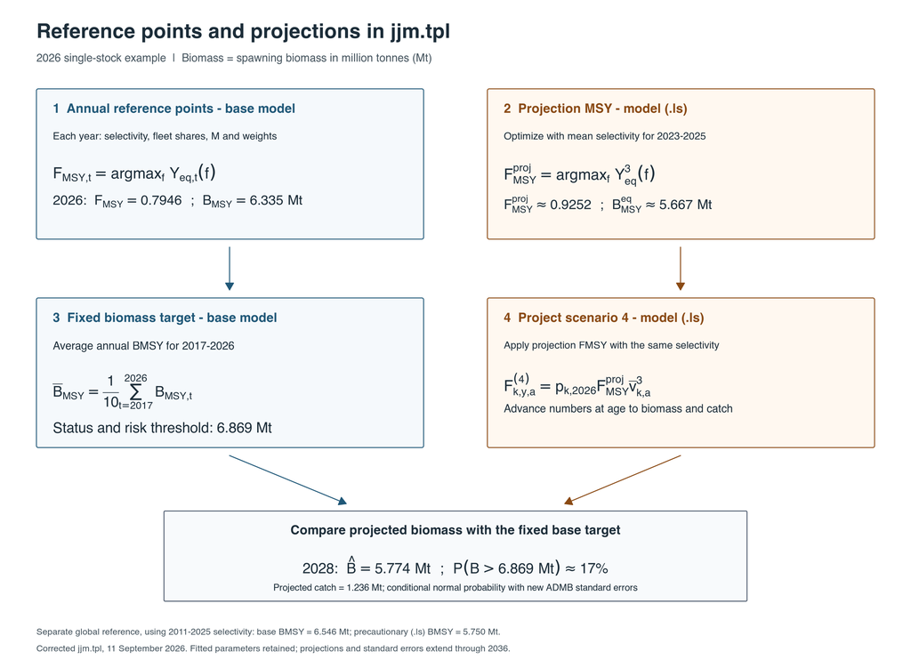

Figure 1: Reference points and projection scenario 4 in the saved 11 September calculations. The fixed base biomass target comes from annual reference points. Scenario 4 calculates and applies FMSY with the same future selectivity; the global fifteen-year reference is reported separately.

### 3.3.2 Reference values

Table 2: Annual base references from `msy_mt` columns 5 and 10, and the fixed ten-year mean of column 10.

| Base model / component | Annual 2026 FMSY | Annual 2026 BMSY (Mt) | Fixed 2017–2026 BMSY (Mt) |
| --- | --- | --- | --- |
| h1_1.06 / Single stock | 0.7946 | 6.335 | 6.869 |
| h2_1.06 / South | 0.8854 | 6.074 | 6.524 |
| h2_1.06 / Far North | 0.1109 | 1.309 | 1.305 |

The scalar values below are named outputs from the saved 11 September `jjm.tpl` runs. Independent equilibrium calculations reproduce the global and projection optima for all six model/component combinations. The associated validation checks found that changing `fut_sel` between 0, 3 and 15 leaves the global reference unchanged; setting both windows to 15 gives matching global and projection optima for these constant-M configurations. Reference values and replacement diagnostics retain the native kt values.

Table 3: Global and projection equilibrium reference points from the saved 11 September runs. The `.ls` projection FMSY values feed scenario 4. All scalar BMSY values remain separate from the fixed **base-model annual-average** risk thresholds.

| Run / component | Global FMSY (15-year) | Global BMSY (Mt; 15-year) | Projection FMSY (3-year) | Projection equilibrium BMSY (Mt; 3-year) |
| --- | --- | --- | --- | --- |
| h1_1.06 / Single stock | 0.3916 | 6.546 | 0.9128 | 6.434 |
| h2_1.06 / South | 0.3855 | 6.040 | 0.9502 | 6.205 |
| h2_1.06 / Far North | 0.0955 | 1.314 | 0.1120 | 1.293 |
| h1_1.06.ls / Single stock | 0.3932 | 5.750 | 0.9252 | 5.667 |
| h2_1.06.ls / South | 0.3874 | 5.096 | 0.9751 | 5.254 |
| h2_1.06.ls / Far North | 0.0955 | 1.314 | 0.1120 | 1.293 |

All configurations use Beverton–Holt steepness 0.65. The base single and southern stocks fit recruitment over 2000–2023; their `.ls` variants use 2001–2015. The Far North stock uses 1970–2016 in both. This changes productivity as well as preserving the distinction between reference-point selectivity windows.

### 3.3.3 Equations behind the diagram

Let $T=2026$, $k$ index fleets belonging to stock $s$, $a=1,\ldots,A$ index ages, and $A=12+$ denote the plus group. The model’s $B$ is **spawning biomass**. Biomass and catch in the native report are in thousand tonnes (kt); the tables here divide biomass by 1,000 to show million tonnes (Mt). $F$ and $M$ are instantaneous annual rates. Selectivity $v$ retains the model’s age scaling, so the reported $F$ is the sum of fleet means over model ages, rather than a fully selected maximum.

The fleet allocation and trial fishing mortality are

$$p_{k,t}=\frac{\sum_a F_{k,t,a}}{\sum_{k\in s}\sum_a F_{k,t,a}},
\qquad F_{k,a}(f)=p_{k,t}\,f\,v_{k,a},
\qquad Z_a(f)=M_a+\sum_{k\in s}F_{k,a}(f).
\tag{1}$$

For one recruit, the equilibrium age distribution, spawning biomass per recruit and yield per recruit are

$$\begin{gathered}
\ell_1(f)=1,\\
\ell_a(f)=\exp\!\left[-\sum_{j=1}^{a-1}Z_j(f)\right]\quad(a<A),\\
\ell_A(f)=\frac{\exp[-\sum_{j=1}^{A-1}Z_j(f)]}{1-\exp[-Z_A(f)]},\\
\phi(f)=\sum_a \ell_a(f)e^{-\tau Z_a(f)}w_a^{\mathrm{mat}},\\
y(f)=\sum_{k\in s}\sum_a w_{k,a}^{\mathrm{fsh}}\ell_a(f)
\frac{F_{k,a}(f)}{Z_a(f)}\left(1-e^{-Z_a(f)}\right).
\end{gathered}
\tag{2}$$

Here $w_a^{\mathrm{mat}}$ is population weight multiplied by maturity, and $\tau=(10.5-1)/12=9.5/12$ is the spawning fraction used by these runs. The active Beverton–Holt form (`SrType = 2`) is

$$\begin{gathered}
R(B)=\frac{B}{\alpha+\beta B},\\
\alpha=\frac{B_0(1-h)}{4hR_0},\\
\beta=\frac{5h-1}{4hR_0},\\
R_{\mathrm{eq}}(f)=\frac{\phi(f)-\alpha}{\beta\phi(f)},\\
Y_{\mathrm{eq}}(f)=R_{\mathrm{eq}}(f)y(f),\\
B_{\mathrm{eq}}(f)=R_{\mathrm{eq}}(f)\phi(f).
\end{gathered}
\tag{3}$$

Thus $F_{\mathrm{MSY}}$ seeks the maximum of $Y_{\mathrm{eq}}(f)$ and $B_{\mathrm{MSY}}=B_{\mathrm{eq}}(F_{\mathrm{MSY}})$. In the saved template version, the annual report searches 501 logarithmically spaced trial rates from 0.0001 to 5 and retains feasible positive equilibria; the global scalar calculation uses eight Newton updates. The projection calculation locates a feasible interior maximum on a 101-point logarithmic grid and refines it with eight differentiable Newton updates, using the same equilibrium function for optimization and final evaluation. `Requil()` evaluates equilibrium recruitment without a $\exp(\sigma_R^2/2)$ multiplier.

### 3.3.4 Which quantities are used

| Calculation | Selectivity and biological inputs | Use |
| --- | --- | --- |
| Annual MSY series | Each year’s selectivity, fleet shares, natural mortality, fishery weights and stock–recruit regime | `msy_mt`: annual $F_{\mathrm{MSY},t}$ and $B_{\mathrm{MSY},t}$ |
| Fixed biomass target | Arithmetic mean of annual **base-model** $B_{\mathrm{MSY},t}$ for 2017–2026 | Stock-status summary and the restored projection-risk tables |
| Global scalar MSY in `jjm.tpl` | `sel_msy`: mean selectivity for 2011–2025 when `msy_sel = 15`; terminal fleet shares and fishery weights, initial-year $M$, terminal stock–recruit regime | Reports `Fmsy_global`, `Bmsy_global` and `MSY_global` independently of projection selectivity |
| Projection MSY and scenario 4 | `sel_fut`: mean selectivity for 2023–2025 when `fut_sel = 3`; terminal fleet shares, weights and $M$ | Optimizes `Fmsy_proj` and applies it to future numbers at age with the same `sel_fut` |

The fixed target and annual fishing-mortality ratio are

$$\overline B_{\mathrm{MSY}}^{\mathrm{base}}
=\frac{1}{10}\sum_{t=2017}^{2026}B_{\mathrm{MSY},t}^{\mathrm{base}},
\qquad
\frac{F_T}{F_{\mathrm{MSY},T}}
=\frac{\sum_{k\in s}\operatorname{mean}_a F_{k,T,a}}
{F_{\mathrm{MSY},T}^{\mathrm{annual}}}.
\tag{4}$$

The future-selectivity averages and scenario-4 fishing rates are

$$\overline v_{k,a}^{15}=\frac{1}{15}\sum_{t=2011}^{2025}v_{k,t,a},
\qquad
\overline v_{k,a}^{3}=\frac{1}{3}\sum_{t=2023}^{2025}v_{k,t,a},
\qquad
F_{k,y,a}^{(4)}=p_{k,T}\,F_{\mathrm{MSY}}^{\mathrm{proj}}\,\overline v_{k,a}^{3}.
\tag{5}$$

With $Z_{y,a}=M_{T,a}+\sum_kF_{k,y,a}$, future biomass and catch follow the population forward from the fitted terminal age structure:

$$\begin{gathered}
N_{y,1}=R(B_{y-1})e^{\epsilon_y},\\
N_{y+1,a+1}=N_{y,a}e^{-Z_{y,a}}\quad(a<A-1),\\
N_{y+1,A}=N_{y,A-1}e^{-Z_{y,A-1}}+N_{y,A}e^{-Z_{y,A}},\\
B_y=\sum_aN_{y,a}e^{-\tau Z_{y,a}}w_a^{\mathrm{mat}},\\
C_y=\sum_{k\in s}\sum_aw_{k,T,a}^{\mathrm{fsh}}N_{y,a}
\frac{F_{k,y,a}}{Z_{y,a}}\left(1-e^{-Z_{y,a}}\right).
\end{gathered}
\tag{6}$$

The recruitment lag is one year in these runs. The terminal stock–recruit regime supplies $R(\cdot)$ and `rec_dev_future` supplies $\epsilon_y$. The population equations produce the finite trajectories `SSB_fut_4` and `Catch_fut_4`. The annex risk calculation compares the projected biomass distribution with the separate fixed base-model target, $P(B_y>\overline B_{\mathrm{MSY}}^{\mathrm{base}})$.

Scenarios 1–3 apply 1, 0.75 and 1.25 times the terminal fleet mean $F$ with `sel_fut` when `fut_sel > 0`; scenario 6 sets $F=0$. Scenario 5 uses the supplied TAC input and a **terminal-year selectivity** path distinct from scenario 4. The realized catches in the saved scenario differ from the supplied TAC; Section 4.2 records those values and their interpretation.

### 3.3.5 Source and interpretation checks

The equations above follow the 11 September `jjm.tpl` version’s functions `get_future_sel`, `get_msy`, `projection_equilibrium`, `get_projection_msy`, `get_future_Fs`, `Future_projections`, `get_msy_robust`, `SRecruit` and `Requil`. The validation record identifies the source hash and independent numerical checks, including all ten years of scenario-4 biomass and catch. Earlier five-year and intermediate scenario-4 validation records describe superseded calculations; the ten-year manifest and its matching validation define the results presented here.

The saved base Model 1.06 assessment results used **`jjm2`**. The 11 September ten-year projections used a separately compiled **`jjm`** executable; their annual `msy_mt`, historical numbers at age and fitted fishing mortality reproduce the saved assessment values. The annual assessment script subsequently changed to call **`jjm`**. This document retains the saved outputs and the exact projection version identified by the manifest; a later executable path alone leaves their numerical provenance unchanged. The earlier `jjm2.tpl` replacement calculation is retained as historical context.

`Sp_Biom_NoFish` supports a separate dynamic unfished-biomass series. Multiplying that series by a selected $B_{\mathrm{MSY}}/B_0$ ratio constructs a dynamic reference for comparison with biomass. The fixed target and scenario-4 population equations above retain their own definitions.

### 3.3.6 Applying the supplied 2022 Annex K guidance

The supplied Annex K proposal describes the jack mackerel harvest control rule as adjusted during SCW14 (*Proposed Jack Mackerel Harvest Control Rule*, 2022, pp. 1–2). It adds a **catch-decision step** to the reference-point and projection calculations above. The document records a proposal; its application in 2026 requires the agreed management record and an explicit reference-point convention.

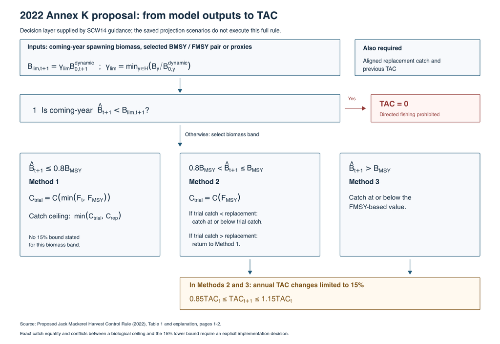

Figure 2: The 2022 proposal first compares coming-year spawning biomass with a dynamic limit, then uses three biomass bands to choose trial catch and replacement-yield safeguards. The upper two bands also limit annual TAC changes to 15%.

**Decision year and biomass definition.** All biomass quantities in this guidance are spawning biomass. The decision table uses estimated biomass in the **coming year**, $\widehat B_{t+1}$: for a 2026 assessment this is $\widehat B_{2027}$, rather than the terminal estimate $B_{2026}$. The fishing assumption that generates that status forecast must accompany it. The saved scenario-4 forecast is one conditional forecast, rather than a uniquely specified HCR status input.

**Dynamic limit.** The proposal defines the biomass limit from the lowest historical ratio of spawning biomass to its corresponding unfished value:

$$\gamma_{\mathrm{lim}}=
\min_{y\in\mathcal H}\left(\frac{B_y}{B_{0,y}^{\mathrm{dynamic}}}\right),
\qquad
B_{\mathrm{lim},t+1}=\gamma_{\mathrm{lim}}\,B_{0,t+1}^{\mathrm{dynamic}}.
\tag{7}$$

Here $\mathcal H$ is the explicitly identified historical period. Unfished spawning biomass follows the estimated recruitment history, adjusted through the stock–recruit relationship under no fishing. In the saved template these quantities correspond to `Sp_Biom_NoFish` and `Sp_Biom_NoFishRatio`; the future no-fishing calculation supplies the coming-year denominator. This limit differs from both the fixed ten-year B<sub>MSY</sub> target and the dynamic-B<sub>MSY</sub> construction. An 8% limit follows only when the selected historical minimum equals 0.08. Calculating a numerical B<sub>lim</sub> requires a matched historical minimum and coming-year unfished biomass.

**Trial catch and biomass bands.** Write $C_{t+1}(f)$ for the projected catch under trial fishing rate $f$, using a stated fleet allocation, selectivity, recruitment and weight convention. Define

$$\begin{gathered}
C_1=\min\left\{C_{t+1}\!\left[\min(F_t,F_{\mathrm{MSY}})\right],
C_{t+1}^{\mathrm{replacement}}\right\},\\
C_F=C_{t+1}(F_{\mathrm{MSY}}).
\end{gathered}
\tag{8}$$

$C_1$ is the catch ceiling described by method 1. The comparison of $F_t$ with $F_{\mathrm{MSY}}$ requires a common age and selectivity scaling. The annual F<sub>MSY</sub>, scalar F<sub>MSY</sub> and associated biomass references documented above should therefore retain their definitions when selecting the HCR inputs.

Table 4: The 2022 proposal’s biomass bands and catch calculations, with its first-row limit check given precedence over the overlapping low-biomass row. The source permits an identified BMSY/FMSY proxy.

| Coming-year spawning-biomass condition | Catch guidance in the supplied proposal | TAC stability provision |
| --- | --- | --- |
| $\widehat B_{t+1}<B_{\mathrm{lim},t+1}$ | Set TAC to zero; directed jack mackerel fishing prohibited under the proposed rule. | Closure is checked first. |
| Remaining cases with $\widehat B_{t+1}\le0.8B_{\mathrm{MSY}}$ | Trial catch at $\min(F_t,F_{\mathrm{MSY}})$; catch at or below $C_1$. | Stability bound unspecified for this row. |
| $0.8B_{\mathrm{MSY}}<\widehat B_{t+1}\le B_{\mathrm{MSY}}$ | Trial catch at F<sub>MSY</sub>. If $C_F<C^{\mathrm{replacement}}$, catch at or below $C_F$; if $C_F>C^{\mathrm{replacement}}$, return to method 1. | Annual TAC variation limited to 15%. |
| $\widehat B_{t+1}>B_{\mathrm{MSY}}$ | Catch at or below the value obtained using F<sub>MSY</sub>. | Annual TAC variation limited to 15%. |

The table places equality at 80% B<sub>MSY</sub> in the lower band and equality at B<sub>MSY</sub> in the middle band. The exact trial-catch/replacement-catch equality case remains an implementation choice to resolve. In the upper two bands, the stated annual stability interval is

$$0.85\,\mathrm{TAC}_t\le\mathrm{TAC}_{t+1}\le1.15\,\mathrm{TAC}_t.
\tag{9}$$

That interval and the biological catch ceiling can conflict if the ceiling falls below $0.85\,\mathrm{TAC}_t$. Reconciling these provisions requires an explicit implementation order, which remains unspecified in the proposal. The upper 15% bound is a constraint on annual variation.

For orientation, applying the **annex’s working fixed base-model B<sub>MSY</sub> convention** gives the following 80% and 100% thresholds. Operational classification requires the agreed Annex K reference and a stated coming-year biomass forecast.

Table 5: Illustrative biomass bands using the fixed 2017–2026 mean from each base model.

| Component | 80% of fixed BMSY (Mt) | Fixed BMSY (Mt) |
| --- | --- | --- |
| Single stock | 5.495 | 6.869 |
| South | 5.219 | 6.524 |
| Far North | 1.044 | 1.305 |

**Replacement-catch timing.** The proposal defines replacement yield using consecutive spawning years: catch in year $y$ leaves $B_{y+1}$ equal to $B_y$. For a proposed catch in 2027, the aligned condition is

$$B_{2028}\!\left(C_{2027}^{\mathrm{replacement}}\right)=B_{2027},
\tag{10}$$

with recruitment and fishing mortality during both spawning periods stated. The saved 11 September `jjm.tpl` version solves this consecutive-year condition with the projection SRR, `sel_fut`, terminal fleet shares and the same trial F in 2027 and 2028. Under the precautionary `.ls` configurations, replacement catches are 1,104.7 kt for the single stock, 895.5 kt for the southern component and 15.7 kt for Far North. All three attain a root. The earlier `jjm2.tpl` diagnostics used mean recruitment and a B<sub>2028</sub> = B<sub>2026</sub> target; their saved values remain part of the original assessment output history.

**What the saved projections implement.** Scenario 4 applies a scalar F<sub>MSY</sub>; scenario 5 uses a supplied TAC input, with realized catches qualified in Section 4.2. A complete Annex K calculation additionally requires the dynamic-limit test, the 80% and 100% biomass branches, replacement-catch comparisons and annual 15% TAC constraints. A source-code comment mentions a 15% increase; implementing the stability provision requires an explicit calculation. The annex risk tables give $P(B_y>\overline B_{\mathrm{MSY}}^{\mathrm{base}})$; the limit-breach probability $P(B_y<B_{\mathrm{lim},y})$ requires a separate analysis.

An operational comparison therefore needs a documented coming-year status forecast; the selected B<sub>MSY</sub>/F<sub>MSY</sub> pair or proxies and their scaling; a matched dynamic limit; the stated replacement assumptions; the previous TAC; and explicit handling of the stability conflict, equality cases and stock-component allocation. These choices require reconciliation with the agreed management record. The 2022 proposal provides source guidance alongside the assessment and saved projection calculations.

The rule follows the supplied proposal (*Proposed Jack Mackerel Harvest Control Rule*, 2022, Table 1, pp. 1–2). The assessment calculations are traced through the saved `jjm.tpl` version’s functions `Calc_Dependent_Vars`, `Future_projections`, `get_future_Fs`, `repl_ssb` and `Get_Replacement_Yield`. The projection run manifest identifies the exact template hash and input settings.

# 4 Results

## 4.1 Current working stock estimates

The current estimates are given in Table 6. SSB and B<sub>MSY</sub> are expressed in million tonnes (Mt); the underlying model biomass output is in thousand tonnes. The 2026 SSB estimate for the single-stock model is about 6.11 Mt, compared with 6.03 Mt in 2025. Its ratio to the fixed 2017–2026 mean B<sub>MSY</sub> is about 0.89. The two-stock estimates differ, particularly for the Far North component. These are conditional estimates from the working configurations.

Table 6: Working 2026 assessment estimates. Mean BMSY is the fixed 2017–2026 mean of annual model estimates. F/FMSY is the 2026 annual ratio. These values use saved Model 1.06 results and retain preliminary assessment status.

| Model | Component | SSB 2025 (Mt) | SSB 2026 (Mt) | Mean BMSY (Mt) | SSB / mean BMSY | F / FMSY |
| --- | --- | --- | --- | --- | --- | --- |
| h1_1.06 | Single stock | 6.031 | 6.109 | 6.869 | 0.889 | 0.861 |
| h2_1.06 | South | 6.529 | 6.661 | 6.524 | 1.021 | 0.705 |
| h2_1.06 | Far North | 4.208 | 4.046 | 1.305 | 3.101 | 0.205 |

The North Chile acoustic-index decline from approximately 3.06 Mt in 2025 to 0.64 Mt in 2026 differs from the single-stock model’s slight increase in SSB. The survey measures a regional signal and has its own spatial coverage, timing and availability effects. ENSO and changes in distribution remain hypotheses to examine alongside sampling and fishery behaviour. Inferring whole-stock biomass change requires integrating this regional signal with the other surveys, fishery data and model diagnostics. The model fits and index-influence analyses show how these observations affect the integrated assessment (*Jack Mackerel Assessment SC14*, 2026).

## 4.2 Projection risk summary

Table 7, Table 8 and Table 9 summarize the six fishing scenarios from the saved low-productivity projection runs. Spawning biomass (B) and catch are in **thousand tonnes (kt)**. The tables show biomass and the approximate probability of exceeding B<sub>MSY</sub> at **2, 5 and 10 years after 2026: 2028, 2031 and 2036**, plus catches in 2027–2028. The projections cover 2027–2036 and were recalculated on **11 September 2026**, including ADMB standard errors, with the `jjm.tpl` version identified in the run manifest. Later source revisions are outside this saved result set.

The biomass threshold is the **fixed 2017–2026 mean B<sub>MSY</sub> from the corresponding base Model 1.06**, consistent with Table 6. All three components use steepness 0.65. The single stock and southern component use the 2001–2015 recruitment period; the Far North component retains 1970–2016. Probabilities follow the existing JJM risk-table method, using the projected biomass estimate and its reported ADMB standard error:

$$P(B_y>B_{\mathrm{MSY}})\;\simeq\;
1-\Phi\left(\frac{B_{\mathrm{MSY}}-\widehat B_y}{\mathrm{SE}(\widehat B_y)}\right).$$

These are conditional normal approximations with the reference point held fixed. They measure exceedance in each stated year. The probability of remaining above a threshold throughout a period requires a separate calculation, as do the exploratory MCMC summaries.

**Saved TAC scenario.** Scenario 5 retains the 11 September implementation and its realized catches. With the supplied input of **1,674.975 kt**, the saved 2027 catch is **1,491.6 kt** under `h1` and **1,656.65 kt** in total under `h2` (1,489.38 kt southern and 167.27 kt Far North). These catches differ from the input and vary over the projection. This archived scenario therefore describes its recorded catches; use as a projection of a specified annual TAC requires a separately validated run that achieves that TAC in each intended year. The subsequent catch-solver revision is outside the saved results displayed here.

For the **1-stock table, both model runs contribute**: the ten-year extension of `h1_1.06.ls.ctl` supplies projected biomass and its newly calculated ADMB standard error; `h1_1.06.ctl` supplies the base-model B<sub>MSY</sub> threshold through the original `h1_1.06_1_R.rep`. The precautionary run’s own B<sub>MSY</sub> estimate is separate from the threshold used here. For example, updated scenario 4 in 2028 gives $\widehat B = 5774.30$ kt and $\mathrm{SE}=1147.25$ kt. With the base threshold $6869.029054$ kt, the calculation is $1-\Phi[(6869.029054-5774.30)/1147.25]=0.169986$, displayed as **17%**. Uncertainty in the B<sub>MSY</sub> threshold is excluded.

**Calculation and run provenance:** global MSY uses `sel_msy` (2011–2025), while scenario 4 both calculates and applies its own `Fmsy_proj` using `sel_fut` (2023–2025), the same future selectivity used in scenarios 1–3. Fitted assessment parameters were held at their saved values; future recruitment deviations were extended with zeros and the Hessian and derived standard errors were recomputed. The original fixed base biomass targets are retained. Annual risk data and the run manifest provide the values, controls, source hash and validation record. Earlier five-year validation files belong to the calculation history; the ten-year records support the tables below.

The supplied 2022 Annex K proposal (Section 3.3.6) also uses a dynamic limit, 80% and 100% biomass bands, replacement catch and specified TAC stability constraints. These tables describe fixed-BMSY exceedance under saved scenarios. Limit-breach probability and application of the complete harvest control rule require the additional definitions and calculations described in that section.

Table 7: Single-stock risk summary, h1_1.06.ls. B and catch are in kt; P(B > BMSY) is the approximate annual probability that B exceeds fixed BMSY = 6869 kt. Probabilities are rounded to whole percentages; values below 1% or above 99% are shown as <1 or >99.

| Fishing scenario | B 2028 | P(B > Bmsy) in 2028 | B 2031 | P(B > Bmsy) in 2031 | B 2036 | P(B > Bmsy) in 2036 | Catch 2027 | Catch 2028 |
| --- | --- | --- | --- | --- | --- | --- | --- | --- |
| F = 0 | 7,884 | 77 | 10,880 | 96 | 14,110 | 98 | 0 | 0 |
| 0.75 × F2026 | 6,503 | 39 | 7,166 | 56 | 7,391 | 58 | 760 | 857 |
| 1 × F2026 | 6,188 | 30 | 6,541 | 43 | 6,603 | 46 | 964 | 1,026 |
| 1.25 × F2026 | 5,910 | 23 | 6,024 | 32 | 5,975 | 34 | 1,152 | 1,169 |
| FMSY scenario | 5,774 | 17 | 5,782 | 26 | 5,688 | 28 | 1,247 | 1,236 |
| TAC scenario (supplied TAC) | 5,368 | 14 | 4,594 | 15 | 3,409 | 14 | 1,492 | 1,467 |

Table 8: Southern-component risk summary, h2_1.06.ls. B and catch are in kt; P(B > BMSY) is the approximate annual probability that B exceeds fixed BMSY = 6524 kt. Probabilities are rounded to whole percentages; values below 1% or above 99% are shown as <1 or >99.

| Fishing scenario | B 2028 | P(B > Bmsy) in 2028 | B 2031 | P(B > Bmsy) in 2031 | B 2036 | P(B > Bmsy) in 2036 | Catch 2027 | Catch 2028 |
| --- | --- | --- | --- | --- | --- | --- | --- | --- |
| F = 0 | 8,439 | 90 | 10,944 | 98 | 13,275 | 98 | 0 | 0 |
| 0.75 × F2026 | 7,024 | 64 | 7,252 | 65 | 7,198 | 61 | 735 | 818 |
| 1 × F2026 | 6,701 | 55 | 6,677 | 53 | 6,524 | 50 | 934 | 973 |
| 1.25 × F2026 | 6,416 | 47 | 6,203 | 43 | 5,985 | 40 | 1,117 | 1,103 |
| FMSY scenario | 6,046 | 34 | 5,624 | 29 | 5,342 | 27 | 1,368 | 1,262 |
| TAC scenario (supplied TAC) | 5,742 | 30 | 4,377 | 16 | 2,111 | 8 | 1,489 | 1,492 |

Table 9: Far North-component risk summary, h2_1.06.ls. B and catch are in kt; P(B > BMSY) is the approximate annual probability that B exceeds fixed BMSY = 1305 kt. Probabilities are rounded to whole percentages; values below 1% or above 99% are shown as <1 or >99.

| Fishing scenario | B 2028 | P(B > Bmsy) in 2028 | B 2031 | P(B > Bmsy) in 2031 | B 2036 | P(B > Bmsy) in 2036 | Catch 2027 | Catch 2028 |
| --- | --- | --- | --- | --- | --- | --- | --- | --- |
| F = 0 | 4,029 | >99 | 4,142 | >99 | 4,327 | >99 | 0 | 0 |
| 0.75 × F2026 | 3,884 | >99 | 3,750 | >99 | 3,705 | >99 | 86 | 98 |
| 1 × F2026 | 3,838 | >99 | 3,632 | >99 | 3,522 | >99 | 113 | 128 |
| 1.25 × F2026 | 3,794 | >99 | 3,520 | >99 | 3,350 | 99 | 140 | 156 |
| FMSY scenario | 3,273 | >99 | 2,385 | 97 | 1,703 | 83 | 489 | 447 |
| TAC scenario (supplied TAC) | 3,761 | >99 | 3,482 | 99 | 3,306 | 97 | 167 | 167 |

## 4.3 Fits and retrospective patterns

The appended figures show fishery age and length fits, index fits, mean ages and lengths, selectivity patterns and summary trajectories for the current models. These provide the evidence for evaluating tensions among data sources. They replace the previous annex’s claims about the fit of SC13 Model 1.14.

At each peel’s final fitted year, the five-peel SSB Mohn’s rho is **0.09** under the single-stock hypothesis, **0.3** for the southern component and **0.01** for the Far North component. The SSB figure titles use each peel’s extra forecast year from the saved series, giving **0.26**, **0.43** and **-0.0086**, respectively. The two sets therefore describe different endpoints. The larger southern retrospective pattern under `h2` warrants attention when comparing stock hypotheses and interpreting terminal estimates. Recruitment retrospectives are also shown. These diagnostics describe revision patterns within the fitted models; they provide a separate check from comparisons between successive annual assessments.

## 4.4 Leave-one-in and leave-one-out analyses

The September 2026 single-stock analyses compare the all-data base `h1_1.06` with Models `h1_3.01`–`h1_3.08`. The four tested index groups are Chile CPUE, Offshore CPUE, both Peruvian CPUE series together, and North Chile acoustics. LOI Models 3.01–3.04 retain one of these groups at its base weight; LOO Models 3.05–3.08 reduce the influence of each group in turn. In this implementation, exclusion means multiplying the selected index errors by 100. Catches and composition data remain in the likelihood.

LOI results retain the highest recent biomass when North Chile acoustics or the paired Peruvian CPUE series retain their base weights. Among the LOO runs, reducing the influence of Chile CPUE gives the largest increase in 2026 SSB, whereas reducing North Chile acoustics decreases it. Offshore and Peruvian CPUE exclusions have smaller effects. The comparisons diagnose sensitivity to index weighting and conflict among signals; they support discussion of the input uncertainties and model assumptions. The LOI/LOO report (*Leave-One-in and Leave-One-Out Analyses*, 2026) provides the common-axis comparisons and full run definitions.

## 4.5 Replacement-yield checks

The 11 September replacement calculation solves **B<sub>2028</sub> = B<sub>2027</sub>**, using the projection SRR, future selectivity, stock-specific fleet shares and the same trial fishing rate in both spawning years. It calculates catch in 2027 with the Baranov equation and retains survivors from the terminal plus group. All six model/component checks attain a root, with native reported absolute biomass residuals below 0.001 kt; independent reconstruction from rounded report values agrees within reporting precision. Under the precautionary `.ls` assumptions, replacement catches are **1,104.7 kt** for the single stock, **895.5 kt** for the southern component and **15.7 kt** for Far North. Corresponding base-run values are **1,273.3**, **1,118.0** and **15.7 kt**. These consecutive-year results replace the earlier `jjm2` diagnostics for a different B<sub>2028</sub> = B<sub>2026</sub> target and mean-recruitment assumption. Those earlier diagnostics remain part of the assessment history. The consecutive-year calculation addresses the supplied Annex K replacement condition; application of the full rule still requires the other decision inputs in Section 3.3.6.

## 4.6 Exploratory uncertainty analysis

A separate ADNUTS analysis of `h1_1.06` used three chains, 2,000 iterations per chain including 1,000 warmup iterations, and 3,000 retained draws. It completed without divergences or tree-depth saturation, but **366 of 1,593 active parameters** failed one or more diagnostic screens. Maximum R-hat was about 1.055, and minimum bulk and tail effective sample sizes were about 83 and 150. The derived summaries also contain diagnostic failures. Intervals, annual green probabilities and the 100 historical Kobe trajectories therefore remain exploratory.

That Kobe display uses each draw’s mean SSB<sub>MSY</sub> for 2017–2026 and the matching annual F<sub>MSY</sub>. Its biomass reference is the fixed ten-year mean. The outputs illustrate assessment uncertainty and mixing problems; definitive posterior probabilities require satisfactory sampling diagnostics (Ianelli, 2026).

# 5 Management advice and decision status

For the **1-stock hypothesis**, the B<sub>MSY</sub> target is **6.869 million tonnes (Mt)**, based on the **long-term stock–recruitment relationship (SRR)** fitted over 2000–2023 in the base assessment. Following the assessment convention, projections use a **precautionary level of recruitment productivity**, fitted over 2001–2015, to evaluate future biomass and catch. The corresponding B<sub>MSY</sub> estimate for the precautionary run is **6.041 Mt**. Both estimates use the 2017–2026 mean of annual equilibrium reference points, providing a comparison on the same averaging basis. **Projected biomass is assessed against the long-term target of 6.869 Mt.**

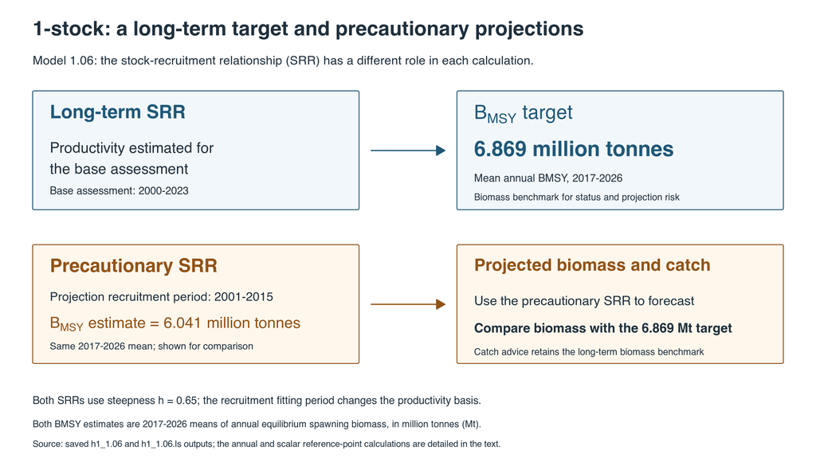

Figure 3: 1-stock hypothesis, Model 1.06: the long-term SRR supplies the BMSY target of 6.869 Mt; the precautionary SRR supplies biomass and catch projections. Its comparable BMSY estimate is 6.041 Mt, while projection risk is evaluated against the 6.869 Mt target. Both BMSY values are 2017–2026 means of annual equilibrium spawning biomass.

The estimates come from the saved `h1_1.06` and `h1_1.06.ls` annual reference-point outputs (`msy_mt`). The 6.041 Mt estimate describes the precautionary run’s equilibrium productivity; the annex retains 6.869 Mt as the target for stock status and the saved 11 September projection probabilities. The annual 2026 values and the separate scalar MSY calculation used to set the F<sub>MSY</sub> projection scenario are distinguished in Section 3.3.1. Both SRRs use steepness $h = 0.65$. This carries forward the conservative recruitment convention described in the SC13 technical annex (SPRFMO Scientific Committee, 2025, para. 84) and the SC14 working assessment (*Jack Mackerel Assessment SC14*, 2026). The 2-stock hypothesis is discussed separately below.

This annex records the assessment evidence available through 11 September 2026. Final Committee conclusions and catch recommendations require the agreed text, date and report reference. The 2025 annex’s TAC alternatives for 2026 remain part of the SC13 history (SPRFMO Scientific Committee, 2025); the present working assessment provides the updated evidence for the coming management period.

The supplied 2022 SCW14 Annex K proposal is incorporated in Section 3.3.6, including its coming-year biomass test, dynamic limit, trial/replacement-catch comparisons and specified 15% stability provisions. Its documented proposal status is retained pending the applicable agreed management record.

Advice for the coming management period requires confirmation of the annual assessment configuration, the biomass-reference convention and projection assumptions, followed by the agreed Committee catch recommendation. The recorded catches, recruitment assumptions and stock allocations should accompany any projection used in that decision.

## 5.1 1-stock

Under the single-stock hypothesis, `h1_1.06` provides the base assessment and the long-term SRR basis for the biomass target. Its SRR uses **2000–2023**; the fixed 2017–2026 mean B<sub>MSY</sub> is **6.869 Mt**. The current working stock estimates are in Table 6.

The `h1_1.06.ls` projections follow the precautionary SRR convention, using **2001–2015** recruitment productivity. Steepness remains **0.65** in the base and projection runs. Projected biomass and catch are summarized in Table 7, with biomass probabilities evaluated against the **base-model target**. The projection variant’s own equilibrium B<sub>MSY</sub> is a separate quantity.

For the supplied Annex K guidance, the decision input is a stated **2027 spawning-biomass forecast**. The corrected single-stock replacement calculation gives **1,104.7 kt** under precautionary `.ls` recruitment, with B<sub>2028</sub> equal to B<sub>2027</sub> under the same trial F. The updated fixed-F and supplied-TAC scenarios provide projection evidence for the advice discussion; implementing the full rule also requires the dynamic limit, replacement-catch comparison and applicable TAC stability provisions described in Section 3.3.6.

## 5.2 2-stock

Under the two-stock hypothesis, `h2_1.06` separates the **southern** and **Far North** components. Each component retains its own SRR, biomass target and projection results.

**Southern component.** The base SRR uses **2000–2023** and the precautionary `h2_1.06.ls` SRR uses **2001–2015**, with steepness **0.65** in both. Its fixed base-model B<sub>MSY</sub> target is **6.524 Mt**. The updated southern projection risks are shown in Table 8. The corrected precautionary replacement calculation gives **895.5 kt**, with a successful root for B<sub>2028</sub> equal to B<sub>2027</sub>.

**Far North component.** The base and `.ls` configurations both retain the **1970–2016** SRR period and steepness **0.65**. Its fixed base-model B<sub>MSY</sub> target is **1.305 Mt**. The component’s updated projections and probabilities are shown separately in Table 9. The corrected consecutive-year replacement calculation attains a small positive catch of **15.7 kt**, replacing the earlier failed boundary diagnostic for a different target.

Applying the supplied HCR under this hypothesis requires a stated coming-year biomass forecast and matched dynamic limit for the relevant component, together with an explicit decision on how component-level criteria and fleet allocations translate into catch advice. The different recruitment assumptions and replacement diagnostics should accompany any comparison with the 1-stock hypothesis.

# 6 Assessment issues and follow-up

The benchmark and SC14 assessment analyses identify the following continuing priorities:

- **Abundance and availability:** explain the contrasting Chile CPUE, Offshore CPUE and North Chile acoustic signals using sampling coverage, standardization, survey footprint, targeting and environmental information. Evaluate the joint influence of the separate Peruvian CPUE series.
- **Biological and composition inputs:** review weight-at-age substitutions, length conventions, age-reading consistency and effective sample sizes, with attention to the FarNorth fleet and the recent Offshore data.
- **Stock structure and diagnostics:** assess the larger southern retrospective pattern under `h2`, resolve MCMC mixing problems, and preserve the distinction between penalized objective-function improvements and improvements to direct data fits.
- **Reference points and projections:** reconcile the dynamic-B<sub>MSY</sub> implementation, retain the pairing of within-draw reference points, confirm future-selectivity and recruitment settings, review the corrected consecutive-year replacement calculation, resolve the interaction of biological catch ceilings and the 15% stability bounds, and review low-catch projection behavior.
- **Assessment and advice record:** incorporate the agreed SC14 paragraphs when available, including their qualifications and report reference; document the assessment configuration, projection scenario and reference-point conventions supporting the catch recommendation.

The benchmark report and SC14 working assessment provide the supporting discussion (*Jack Mackerel Assessment SC14*, 2026; SPRFMO Jack Mackerel Working Group, 2026a). Completed analyses and formal Committee conclusions should each retain their source and date.

# 7 Assessment continuity and inherited methods

The SC13 technical annex records the assessment accepted in **2025**, including its data sources, model development and diagnostic findings. This section retains that background alongside the **2026 Model 1.06** assessment. Historical model labels and dates are stated explicitly; the current input tables, diagnostics, reference points and projections elsewhere in this annex describe the 2026 configurations (SPRFMO Scientific Committee, 2025, pp. 1, 13–17).

## 7.1 From the SC13 assessment to the 2026 benchmark

The 2025 assessment began from the SC12 Model 1.07 configuration, relabelled 0.00 for its data bridge. Models 0.01–0.10 progressively updated catches, compositions, weights at age and abundance indices. After the annual model update, SC13 examined the influence of the four principal abundance signals and alternative treatments of recent selectivity and composition data. Its final Model 1.14 incorporated additional 2025 selectivity flexibility for South-Central Chile and Offshore, increased weights on their 2025 age compositions, reduced influence of early North Chile acoustic observations, and revised historical weights for older FarNorth fish. This accepted SC13 configuration supplied the starting point for the 2026 benchmark (SPRFMO Scientific Committee, 2025, pp. 13–15; SPRFMO Scientific Committee, 2025, p. 42, Table 26).

The historical sequence explains why identical model numbers can describe different analyses in successive years. In SC13, Models 1.01–1.09 were mainly index-influence sensitivities. In the 2026 annual assessment, Model 1.06 identifies the current working configuration. The current model-development table records the separate 2026 progression.

SC13 also distinguished two retrospective comparisons. An analytical retrospective repeatedly removed the most recent year’s data from one assessment configuration. A historical comparison assembled estimates from successive annual assessments, thereby incorporating changes in data, methods and assumptions. That distinction continues to apply to the five-peel diagnostics and the comparison of SC13 1.14, the 2026 workshop configuration and SC14 1.06 shown here (SPRFMO Scientific Committee, 2025, p. 15, paras. 74–76).

## 7.2 Construction and provenance of fishery compositions

Catch inputs aggregate Member submissions into four fleets defined by fishing area and gear. The composition inputs preserve a further distinction between observations processed into ages before assessment and lengths fitted directly by the assessment model. The SC13 record describes Chilean and older international length distributions converted with annual Chilean age–length keys. For more recent offshore submissions, quarterly EU, Russian or Chilean keys were applied as appropriate before aggregation. Peruvian and Ecuadorian length distributions were retained as lengths and compared with model predictions generated through the growth relationship (SPRFMO Scientific Committee, 2025, p. 3, paras. 14–16).

The offshore sampling protocol also forms part of the input history. Beginning with the 2021 data, self-sampling length distributions could supply quarters covered by self-sampling when observer sampling was absent, following the protocol described in SC10-JM03 and SC10-JM04. SC13 documented this as a supplement to observer coverage. The source and quarterly coverage of each submission therefore matter when interpreting subsequent annual revisions to offshore age compositions (SPRFMO Scientific Committee, 2025, p. 4, para. 17).

The 2022 ageing revision changed historical Chilean fishery and survey compositions and the associated biological inputs. SC13 identified consistency among ageing laboratories, older composition data, and mean weights at age as continuing review priorities. These concerns remain relevant to the 2026 input checks; the current composition and weight tables show the values actually used (SPRFMO Scientific Committee, 2025, pp. 3–4, 6–8; SPRFMO Scientific Committee, 2025, p. 18, paras. 90–91).

## 7.3 Historical development of abundance indices

The current 2026 CPUE specifications follow the changes described earlier in this annex. Their preceding history helps explain differences among archived assessment inputs:

- **South-Central Chile:** the SC13 account describes a trip-based GLM with year, quarter, zone and vessel hold capacity, using fishing days as effort. Earlier changes excluded trips with zero jack mackerel catch and introduced a catchability change associated with the year-2000 management changes. These describe the earlier series; the 2026 benchmark adopted a revised index and uncertainty treatment.
- **Peru:** before SC6, the industrial series was affected by shifts in fishing toward other pelagic species. The subsequent combined index used recovered artisanal and small-scale information with a gamma GAM and log link. SC13 recorded concerns about historical fleet identifiers. The 2026 separate industrial and artisanal series represent a later data and model specification.
- **Offshore:** separate fleet indices were progressively combined, first for EU and Russian data in SC6 and then across China, EU, Korea, Vanuatu and Russia in SC7. The SC13 record describes a negative-binomial GAM with a log-effort offset, temporal and environmental effects, and spatial smoothers; contracting party replaced vessel identity in the SC9 formulation. The assessment series began in 2008 (SPRFMO Scientific Committee, 2025, pp. 4–5, paras. 19–21).

SC13 documented interim efficiency corrections of 1% annually for the Chilean and Peruvian CPUE series and 2.5% for Offshore. These are historical specifications: the 2026 treatment of each series is given in the current data section. The earlier annex also identified search time as difficult to measure consistently and described weekly effort aggregation as one way of capturing more of that activity. Consequently, index revisions can reflect changes in effort definition, sampling, standardization and availability, alongside changes in abundance (SPRFMO Scientific Committee, 2025, p. 5, paras. 22–25).

Two survey records also explain the longer data history. The DEPM observations supplied a historical relative-abundance series and age compositions, while the Peruvian acoustic series represented a coastal survey footprint developed principally for anchoveta. Its later jack mackerel index used backscatter information and ended in 2013. Spatial coverage and changes in fish distribution were central qualifications in the SC13 account. Their 2026 development and removal from the annual Model 1.06 are recorded above; their historical observations remain documented in SC13 (SPRFMO Scientific Committee, 2025, p. 6, paras. 26–30; SPRFMO Scientific Committee, 2025, p. 34, Table 18).

## 7.4 Additional observation-model detail

The principal population equations are summarized in Table 29. Two further relationships make explicit how survey ages and fishery lengths connect to those population quantities, extending the model description in SC13 Table 20 (SPRFMO Scientific Committee, 2025, p. 36).

For a survey or index with age observations, expected sampled numbers are proportional to abundance surviving to the observation time and to index selectivity. Thus

$$p^{\mathrm{index}}_{s,y,a}=
\frac{N_{y,a}S_{s,y,a}\exp(-\Delta_s Z_{y,a})}
{\sum_b N_{y,b}S_{s,y,b}\exp(-\Delta_s Z_{y,b})}.
\tag{11}$$

Here $\Delta_s$ is the fraction of the year before observation. These are number proportions, so mean weight at age is absent from the expression. The currently disabled ageing-error option would apply its age-error matrix to this prediction when enabled. The formula follows the survey age-prediction calculation in both retained JJM source versions.

For the age-to-length conversion, mean length follows the recursive von Bertalanffy form, with a standard deviation proportional to mean length:

$$\begin{gathered}
L_1=L_0,\\
L_a=L_\infty(1-e^{-k})+e^{-k}L_{a-1}\quad(a>1),\\
\sigma_a=\mathrm{CV}_L L_a.
\end{gathered}
\tag{12}$$

Let $u_l^-$ and $u_l^+$ be the lower and upper boundaries of modeled length bin $l$, and let $\Phi$ denote the standard normal cumulative distribution function. The implemented conversion calculates finite-bin probabilities and normalizes them over the represented bins:

$$\begin{gathered}
g_{l,a}=\Phi\!\left(\frac{u_l^+-L_a}{\sigma_a}\right)
-\Phi\!\left(\frac{u_l^--L_a}{\sigma_a}\right),\\
\Gamma_{l,a}=\frac{g_{l,a}}{\sum_m g_{m,a}},\\
\widehat C_{f,y,l}=\sum_a\Gamma_{l,a}C_{f,y,a}.
\end{gathered}
\tag{13}$$

This normalization preserves predicted total numbers when age compositions are converted to length compositions. Expected length proportions then follow by dividing $\widehat C_{f,y,l}$ by their sum across lengths. The 2026 input convention uses 10–50 cm fork-length bins, with observations in the terminal category recorded as 50 cm plus. That data convention and the model’s normalized finite-bin probability calculation are separate parts of the treatment. Growth parameters and their stock/regime mapping follow the selected current controls.

## 7.5 Estimation and weighting history

The JJM estimates recruitment, annual fishing intensity, and fleet- or index-specific selectivity and catchability components through a penalized likelihood. The substantial parameter groups are annual recruitment deviations and the age and annual components of fishing mortality. Selectivity regularity penalties control variation among adjacent ages and changes over time; their active form, strength and estimation phase depend on the configuration. The 2026 selectivity-mapping and input-weight tables make these choices explicit alongside the fitted patterns (SPRFMO Scientific Committee, 2025, pp. 9–10; SPRFMO Scientific Committee, 2025, pp. 35–41, Tables 19–25).

SC13 records use of the Francis T1.8 composition-weighting method from 2018 and a subsequent weighting update at the 2022 benchmark. The 2025 update retained those benchmark weights, with specific adjustments to the partial-year South-Central Chile and Offshore age compositions. These effective sample sizes scale the composition likelihood; they differ from raw counts of sampled fish. The 2026 annual input vectors and coverage adjustments supersede the historical numerical weighting table for the calculations in this annex (SPRFMO Scientific Committee, 2025, p. 9, para. 47; SPRFMO Scientific Committee, 2025, p. 13, paras. 63, 66; SPRFMO Scientific Committee, 2025, p. 38, Table 22).

Finally, SC13 documented separate data-processing and assessment stages: preparing and raising catch compositions, assembling annual data bridges, defining sensitivities, running projections and generating results. Retaining those stages and their input vintage makes successive assessment estimates interpretable. The cumulative annex preserves that provenance while its numerical results continue to come from the saved 2026 assessment products (SPRFMO Scientific Committee, 2025, p. 14, para. 67).

# References

Bertalanffy, L. von. (1957). Quantitative laws in metabolism and growth. *The Quarterly Review of Biology*, *32*(3), 217–231. https://doi.org/10.1086/401873

Beverton, R. J. H., & Holt, S. J. (1957). *On the dynamics of exploited fish populations* (Vol. 19, pp. 1–533). Fisheries Investigations.

Cerna, F. (2022). *Life history parameters of jack mackerel (Trachurus murphyi, Nichols 1920) based on the new validated ageing criterions* (Benchmark Workshop Working Document Nos. SCW14-WD04). South Pacific Regional Fisheries Management Organisation. https://www.sprfmo.int/meetings/scientific-committee/sc-workshops/scw14-jack-mackerel

Fournier, D. A., Skaug, H. J., Ancheta, J., Ianelli, J., Magnusson, A., Maunder, M. N., Nielsen, A., & Sibert, J. (2012). AD Model Builder: Using automatic differentiation for statistical inference of highly parameterized complex nonlinear models. *Optimization Methods and Software*, *27*(2), 233–249. https://doi.org/10.1080/10556788.2011.597854

Francis, R. I. C. C. (2011). Data weighting in statistical fisheries stock assessment models. *Canadian Journal of Fisheries and Aquatic Sciences*, *68*(7), 1124–1138. https://doi.org/10.1139/f2011-025

Ianelli, J. (2026). *Jack mackerel base model: MCMC uncertainty* [Exploratory working report]. South Pacific Regional Fisheries Management Organisation. https://sprfmo.github.io/SC14_JM/papers/base-model-adnuts-2026/base-model-adnuts.html

*Jack mackerel assessment SC14 (draft)*. (2026). [Working assessment report]. South Pacific Regional Fisheries Management Organisation. https://sprfmo.github.io/SC14_JM/assessment/SC14.html

Leal, E., Díaz, E., & Saavedra, J. C. (2012). *Reproductive timing and maturity at length and age of jack mackerel Trachurus murphyi in the Chilean coast* (Science Working Group Working Paper SWG-11-JM-07). South Pacific Regional Fisheries Management Organisation.

*Leave-one-in and leave-one-out analyses*. (2026). [Working assessment diagnostic report]. South Pacific Regional Fisheries Management Organisation. https://sprfmo.github.io/SC14_JM/assessment/loo.html

*Model developments* (Workshop Working Paper SCW17/Paper-01). (2026). South Pacific Regional Fisheries Management Organisation. https://sprfmo.github.io/scw17/SCW17-Paper-01-ModelDevelopments.html

*Proposed jack mackerel harvest control rule, 2022* (Proposal Annex K). (2022). South Pacific Regional Fisheries Management Organisation.

SPRFMO Jack Mackerel Working Group. (2026a). *Report of the jack mackerel benchmark workshop (SCW16)* (Nos. SC14-JM02). South Pacific Regional Fisheries Management Organisation. https://sprfmo.github.io/JM_SCW_prep/JMWG-Benchmark-Meeting-report-2026.html

SPRFMO Jack Mackerel Working Group. (2026b). *Report of the jack mackerel management strategy evaluation workshop (SCW17)* (Nos. SC14-JM03). South Pacific Regional Fisheries Management Organisation. https://sprfmo.github.io/scw17/SCW17-MSE-Workshop-report.html

SPRFMO Scientific Committee. (2025). *Annex 11: Jack mackerel technical annex* (SC13 Report, Annex 11). South Pacific Regional Fisheries Management Organisation. https://sprfmo.int/assets/Meetings/02-SC/13th-SC-2025/SC13-Report-Annex-11_final.pdf

SPRFMO Secretariat. (2026). *Catch history of Trachurus murphyi* (Nos. SC14-JM01). South Pacific Regional Fisheries Management Organisation. https://www.sprfmo.int/assets/Meetings/02-SC/14th-SC-2026/Jack-Mackerel/SC14-JM01-Catch-history-of-Trachurus-murphyi.pdf

# 8 Tables

Country-level catch submissions are documented in (SPRFMO Secretariat, 2026). The table below reports the catch inputs in the current assessment, aggregated into the four model fleets; it preserves the distinction between preliminary 2025 catches and projected full-year 2026 catches.

Table 10: Input catch (thousand tonnes) by fleet for the stock assessment model. The 2025 catches remain preliminary and 2026 catches are projected full-year values.

| Year | Fleet 1 | Fleet 2 | Fleet 3 | Fleet 4 |
| --- | --- | --- | --- | --- |
| 1970 | 101.69 | 10.31 | 4.71 | 1.00 |
| 1971 | 143.45 | 14.99 | 9.19 | 1.00 |
| 1972 | 64.46 | 22.55 | 18.78 | 5.50 |
| 1973 | 83.20 | 38.39 | 42.78 | 1.00 |
| 1974 | 164.76 | 28.75 | 129.21 | 1.00 |
| 1975 | 207.33 | 53.88 | 37.90 | 1.00 |
| 1976 | 257.70 | 84.57 | 54.15 | 1.04 |
| 1977 | 226.23 | 114.57 | 504.99 | 2.27 |
| 1978 | 398.41 | 188.27 | 386.79 | 51.29 |
| 1979 | 344.05 | 253.46 | 333.81 | 370.29 |
| 1980 | 288.81 | 273.45 | 414.30 | 339.80 |
| 1981 | 474.82 | 586.09 | 445.64 | 438.12 |
| 1982 | 789.91 | 704.77 | 143.72 | 733.20 |
| 1983 | 301.93 | 563.34 | 110.69 | 894.30 |
| 1984 | 727.00 | 699.30 | 200.67 | 1,059.93 |
| 1985 | 511.15 | 945.84 | 114.62 | 799.32 |
| 1986 | 55.21 | 1,129.11 | 51.03 | 837.50 |
| 1987 | 313.31 | 1,456.73 | 46.30 | 863.42 |
| 1988 | 325.46 | 1,812.79 | 244.23 | 863.22 |
| 1989 | 338.60 | 2,051.52 | 316.25 | 875.82 |
| 1990 | 323.09 | 2,148.79 | 370.82 | 872.06 |
| 1991 | 346.25 | 2,674.27 | 213.45 | 543.66 |
| 1992 | 304.24 | 2,907.82 | 111.68 | 37.93 |
| 1993 | 379.47 | 2,856.78 | 133.35 | 1.00 |
| 1994 | 222.25 | 3,819.19 | 233.35 | 1.00 |
| 1995 | 230.18 | 4,174.02 | 550.99 | 1.00 |
| 1996 | 278.44 | 3,604.89 | 495.52 | 1.00 |
| 1997 | 104.20 | 2,812.87 | 680.05 | 1.00 |
| 1998 | 30.27 | 1,582.64 | 412.85 | 1.00 |
| 1999 | 55.65 | 1,164.04 | 203.75 | 1.01 |
| 2000 | 118.73 | 1,115.57 | 303.70 | 2.32 |
| 2001 | 248.10 | 1,401.84 | 857.74 | 20.09 |
| 2002 | 108.73 | 1,410.27 | 154.82 | 76.26 |
| 2003 | 143.28 | 1,278.02 | 217.73 | 158.20 |
| 2004 | 158.66 | 1,292.94 | 187.37 | 295.44 |
| 2005 | 165.63 | 1,264.81 | 80.66 | 243.58 |
| 2006 | 155.26 | 1,224.69 | 277.57 | 362.63 |
| 2007 | 172.70 | 1,130.08 | 255.36 | 438.83 |
| 2008 | 167.26 | 728.85 | 169.54 | 406.99 |
| 2009 | 134.02 | 700.90 | 76.63 | 371.92 |
| 2010 | 169.01 | 295.80 | 22.17 | 239.59 |
| 2011 | 30.82 | 216.47 | 326.39 | 60.89 |
| 2012 | 13.26 | 214.20 | 187.40 | 39.92 |
| 2013 | 16.36 | 215.00 | 80.59 | 41.18 |
| 2014 | 18.22 | 254.29 | 74.53 | 63.65 |
| 2015 | 34.89 | 250.33 | 22.45 | 86.67 |
| 2016 | 24.66 | 295.16 | 15.09 | 54.16 |
| 2017 | 35.00 | 311.86 | 8.87 | 49.11 |
| 2018 | 11.55 | 415.15 | 57.16 | 42.46 |
| 2019 | 11.88 | 432.45 | 135.78 | 51.44 |
| 2020 | 44.16 | 517.66 | 140.12 | 4.74 |
| 2021 | 61.36 | 567.27 | 123.64 | 55.30 |
| 2022 | 72.80 | 655.16 | 159.61 | 73.87 |
| 2023 | 68.05 | 740.20 | 222.29 | 95.33 |
| 2024 | 105.31 | 977.04 | 217.24 | 30.48 |
| 2025 | 174.04 | 1,067.68 | 200.38 | 52.43 |
| 2026 | 108.78 | 797.72 | 110.00 | 85.00 |

Table 11: Input catch at age for Fleet 1. Observed proportions are displayed as percentages; the model uses proportions summing to one within each year.

| Year | Age group (years) 1 | Age group (years) 2 | Age group (years) 3 | Age group (years) 4 | Age group (years) 5 | Age group (years) 6 | Age group (years) 7 | Age group (years) 8 | Age group (years) 9 | Age group (years) 10 | Age group (years) 11 | Age group (years) 12 |
| --- | --- | --- | --- | --- | --- | --- | --- | --- | --- | --- | --- | --- |
| 1980 | 0 | 5 | 14 | 24 | 31 | 22 | 4 | 0 | 0 | 0 | 0 | 0 |
| 1981 | 1 | 7 | 13 | 21 | 33 | 19 | 5 | 1 | 0 | 0 | 0 | 0 |
| 1982 | 0 | 15 | 15 | 21 | 26 | 16 | 6 | 1 | 0 | 0 | 0 | 0 |
| 1983 | 1 | 9 | 17 | 27 | 28 | 15 | 3 | 0 | 0 | 0 | 0 | 0 |
| 1984 | 2 | 34 | 12 | 14 | 18 | 16 | 4 | 0 | 0 | 0 | 0 | 0 |
| 1985 | 1 | 18 | 26 | 30 | 18 | 5 | 1 | 0 | 0 | 0 | 0 | 0 |
| 1986 | 8 | 11 | 9 | 18 | 32 | 18 | 5 | 0 | 0 | 0 | 0 | 0 |
| 1987 | 15 | 68 | 11 | 3 | 2 | 1 | 0 | 0 | 0 | 0 | 0 | 0 |
| 1988 | 1 | 17 | 54 | 26 | 2 | 0 | 0 | 0 | 0 | 0 | 0 | 0 |
| 1989 | 0 | 9 | 42 | 39 | 8 | 1 | 0 | 0 | 0 | 0 | 0 | 0 |
| 1990 | 9 | 3 | 28 | 49 | 10 | 1 | 0 | 0 | 0 | 0 | 0 | 0 |
| 1991 | 11 | 33 | 8 | 18 | 24 | 6 | 1 | 0 | 0 | 0 | 0 | 0 |
| 1992 | 11 | 30 | 21 | 21 | 12 | 5 | 1 | 0 | 0 | 0 | 0 | 0 |
| 1993 | 15 | 72 | 8 | 4 | 1 | 0 | 0 | 0 | 0 | 0 | 0 | 0 |
| 1994 | 27 | 32 | 25 | 13 | 2 | 1 | 0 | 0 | 0 | 0 | 0 | 0 |
| 1995 | 5 | 69 | 18 | 6 | 2 | 0 | 0 | 0 | 0 | 0 | 0 | 0 |
| 1996 | 29 | 57 | 11 | 3 | 0 | 0 | 0 | 0 | 0 | 0 | 0 | 0 |
| 1997 | 36 | 60 | 3 | 0 | 0 | 0 | 0 | 0 | 0 | 0 | 0 | 0 |
| 1998 | 8 | 79 | 11 | 3 | 0 | 0 | 0 | 0 | 0 | 0 | 0 | 0 |
| 1999 | 9 | 84 | 5 | 2 | 0 | 0 | 0 | 0 | 0 | 0 | 0 | 0 |
| 2000 | 36 | 47 | 16 | 1 | 0 | 0 | 0 | 0 | 0 | 0 | 0 | 0 |
| 2001 | 51 | 48 | 1 | 0 | 0 | 0 | 0 | 0 | 0 | 0 | 0 | 0 |
| 2002 | 21 | 58 | 17 | 3 | 1 | 0 | 0 | 0 | 0 | 0 | 0 | 0 |
| 2003 | 21 | 72 | 4 | 2 | 1 | 0 | 0 | 0 | 0 | 0 | 0 | 0 |
| 2004 | 13 | 63 | 23 | 1 | 0 | 0 | 0 | 0 | 0 | 0 | 0 | 0 |
| 2005 | 40 | 44 | 11 | 4 | 1 | 0 | 0 | 0 | 0 | 0 | 0 | 0 |
| 2006 | 8 | 83 | 6 | 2 | 1 | 0 | 0 | 0 | 0 | 0 | 0 | 0 |
| 2007 | 12 | 69 | 13 | 3 | 2 | 0 | 0 | 0 | 0 | 0 | 0 | 0 |
| 2008 | 56 | 27 | 9 | 7 | 1 | 0 | 0 | 0 | 0 | 0 | 0 | 0 |
| 2009 | 20 | 68 | 4 | 8 | 0 | 0 | 0 | 0 | 0 | 0 | 0 | 0 |
| 2010 | 9 | 74 | 13 | 3 | 1 | 0 | 0 | 0 | 0 | 0 | 0 | 0 |
| 2011 | 77 | 20 | 2 | 1 | 0 | 0 | 0 | 0 | 0 | 0 | 0 | 0 |
| 2012 | 34 | 58 | 7 | 0 | 0 | 0 | 0 | 0 | 0 | 0 | 0 | 0 |
| 2013 | 31 | 66 | 1 | 1 | 1 | 0 | 0 | 0 | 0 | 0 | 0 | 0 |
| 2014 | 59 | 40 | 2 | 0 | 0 | 0 | 0 | 0 | 0 | 0 | 0 | 0 |
| 2015 | 14 | 60 | 15 | 6 | 4 | 1 | 0 | 0 | 0 | 0 | 0 | 0 |
| 2016 | 10 | 20 | 13 | 19 | 19 | 7 | 10 | 1 | 0 | 0 | 0 | 0 |
| 2017 | 31 | 61 | 6 | 1 | 1 | 0 | 0 | 0 | 0 | 0 | 0 | 0 |
| 2018 | 100 | 0 | 0 | 0 | 0 | 0 | 0 | 0 | 0 | 0 | 0 | 0 |
| 2019 | 20 | 19 | 9 | 14 | 13 | 6 | 7 | 4 | 3 | 3 | 1 | 2 |
| 2020 | 0 | 27 | 25 | 23 | 15 | 8 | 2 | 0 | 0 | 0 | 0 | 0 |
| 2021 | 18 | 3 | 4 | 14 | 22 | 18 | 12 | 7 | 3 | 1 | 1 | 0 |
| 2022 | 2 | 1 | 1 | 11 | 26 | 29 | 19 | 6 | 3 | 1 | 0 | 0 |
| 2023 | 9 | 2 | 6 | 8 | 16 | 25 | 18 | 10 | 4 | 1 | 2 | 0 |
| 2024 | 0 | 1 | 10 | 14 | 13 | 19 | 21 | 14 | 7 | 1 | 0 | 0 |
| 2025 | 0 | 2 | 6 | 8 | 15 | 13 | 17 | 21 | 12 | 5 | 1 | 0 |
| 2026 | 0 | 2 | 1 | 4 | 14 | 12 | 17 | 26 | 15 | 7 | 3 | 0 |

Table 12: Input catch at age for Fleet 2. Observed proportions are displayed as percentages; the model uses proportions summing to one within each year.

| Year | Age group (years) 1 | Age group (years) 2 | Age group (years) 3 | Age group (years) 4 | Age group (years) 5 | Age group (years) 6 | Age group (years) 7 | Age group (years) 8 | Age group (years) 9 | Age group (years) 10 | Age group (years) 11 | Age group (years) 12 |
| --- | --- | --- | --- | --- | --- | --- | --- | --- | --- | --- | --- | --- |
| 1980 | 2 | 23 | 40 | 26 | 8 | 1 | 0 | 0 | 0 | 0 | 0 | 0 |
| 1981 | 2 | 20 | 32 | 31 | 12 | 3 | 0 | 0 | 0 | 0 | 0 | 0 |
| 1982 | 2 | 27 | 37 | 25 | 8 | 1 | 0 | 0 | 0 | 0 | 0 | 0 |
| 1983 | 15 | 28 | 24 | 20 | 11 | 2 | 0 | 0 | 0 | 0 | 0 | 0 |
| 1984 | 7 | 50 | 8 | 14 | 12 | 6 | 2 | 0 | 0 | 0 | 0 | 0 |
| 1985 | 3 | 27 | 26 | 20 | 17 | 7 | 2 | 0 | 0 | 0 | 0 | 0 |
| 1986 | 4 | 11 | 24 | 27 | 21 | 12 | 2 | 0 | 0 | 0 | 0 | 0 |
| 1987 | 8 | 46 | 7 | 10 | 17 | 10 | 2 | 0 | 0 | 0 | 0 | 0 |
| 1988 | 12 | 38 | 29 | 7 | 8 | 6 | 1 | 0 | 0 | 0 | 0 | 0 |
| 1989 | 1 | 12 | 42 | 30 | 9 | 5 | 2 | 0 | 0 | 0 | 0 | 0 |
| 1990 | 0 | 1 | 6 | 26 | 33 | 18 | 12 | 3 | 0 | 0 | 0 | 0 |
| 1991 | 1 | 3 | 0 | 6 | 27 | 29 | 18 | 10 | 4 | 1 | 0 | 0 |
| 1992 | 1 | 7 | 6 | 6 | 8 | 21 | 22 | 16 | 9 | 4 | 0 | 0 |
| 1993 | 1 | 16 | 17 | 14 | 12 | 10 | 14 | 12 | 4 | 1 | 0 | 0 |
| 1994 | 0 | 6 | 17 | 18 | 13 | 11 | 17 | 13 | 4 | 1 | 0 | 0 |
| 1995 | 1 | 19 | 17 | 22 | 20 | 8 | 7 | 4 | 1 | 0 | 0 | 0 |
| 1996 | 4 | 22 | 19 | 17 | 15 | 10 | 6 | 3 | 1 | 0 | 0 | 0 |
| 1997 | 8 | 42 | 21 | 10 | 6 | 5 | 5 | 2 | 1 | 1 | 0 | 0 |
| 1998 | 9 | 58 | 14 | 6 | 3 | 3 | 4 | 2 | 1 | 0 | 0 | 0 |
| 1999 | 20 | 52 | 15 | 6 | 2 | 1 | 1 | 1 | 1 | 0 | 0 | 0 |
| 2000 | 10 | 49 | 24 | 10 | 3 | 1 | 1 | 1 | 1 | 0 | 0 | 0 |
| 2001 | 6 | 41 | 28 | 12 | 4 | 2 | 2 | 2 | 1 | 1 | 1 | 0 |
| 2002 | 7 | 34 | 23 | 16 | 6 | 4 | 3 | 2 | 2 | 2 | 1 | 0 |
| 2003 | 4 | 31 | 28 | 21 | 8 | 3 | 2 | 2 | 1 | 1 | 0 | 0 |
| 2004 | 2 | 22 | 29 | 26 | 11 | 5 | 3 | 2 | 1 | 0 | 0 | 0 |
| 2005 | 2 | 8 | 20 | 33 | 19 | 9 | 5 | 2 | 1 | 1 | 0 | 0 |
| 2006 | 1 | 6 | 9 | 20 | 25 | 14 | 11 | 7 | 3 | 2 | 1 | 1 |
| 2007 | 0 | 13 | 17 | 11 | 15 | 15 | 12 | 9 | 4 | 2 | 1 | 1 |
| 2008 | 3 | 1 | 6 | 22 | 20 | 16 | 11 | 9 | 5 | 3 | 2 | 2 |
| 2009 | 2 | 15 | 2 | 19 | 21 | 16 | 10 | 7 | 4 | 2 | 1 | 1 |
| 2010 | 1 | 32 | 20 | 10 | 11 | 6 | 9 | 6 | 2 | 1 | 1 | 0 |
| 2011 | 2 | 11 | 14 | 36 | 11 | 8 | 13 | 2 | 1 | 0 | 0 | 0 |
| 2012 | 0 | 8 | 25 | 27 | 29 | 7 | 3 | 1 | 0 | 0 | 0 | 0 |
| 2013 | 2 | 18 | 31 | 33 | 14 | 2 | 0 | 0 | 0 | 0 | 0 | 0 |
| 2014 | 1 | 13 | 24 | 26 | 21 | 12 | 3 | 1 | 0 | 0 | 0 | 0 |
| 2015 | 10 | 45 | 14 | 10 | 10 | 7 | 3 | 1 | 0 | 0 | 0 | 0 |
| 2016 | 0 | 23 | 26 | 22 | 14 | 8 | 4 | 2 | 1 | 0 | 0 | 0 |
| 2017 | 3 | 21 | 16 | 16 | 16 | 11 | 7 | 4 | 3 | 1 | 0 | 1 |
| 2018 | 2 | 18 | 24 | 20 | 17 | 9 | 5 | 3 | 1 | 1 | 1 | 0 |
| 2019 | 0 | 9 | 17 | 22 | 24 | 14 | 8 | 4 | 1 | 0 | 0 | 0 |
| 2020 | 0 | 9 | 10 | 15 | 22 | 20 | 14 | 8 | 3 | 0 | 1 | 0 |
| 2021 | 0 | 4 | 15 | 18 | 24 | 18 | 11 | 6 | 2 | 1 | 0 | 0 |
| 2022 | 0 | 1 | 5 | 17 | 24 | 23 | 16 | 9 | 3 | 2 | 0 | 0 |
| 2023 | 0 | 2 | 9 | 17 | 23 | 23 | 15 | 7 | 3 | 1 | 0 | 0 |
| 2024 | 0 | 3 | 10 | 20 | 23 | 19 | 15 | 6 | 2 | 1 | 0 | 0 |
| 2025 | 0 | 0 | 6 | 20 | 29 | 19 | 12 | 8 | 4 | 1 | 0 | 0 |
| 2026 | 0 | 4 | 3 | 6 | 33 | 27 | 18 | 6 | 1 | 1 | 0 | 0 |

Table 13: Input catch at age for Fleet 4. Observed proportions are displayed as percentages; the model uses proportions summing to one within each year.

| Year | Age group (years) 1 | Age group (years) 2 | Age group (years) 3 | Age group (years) 4 | Age group (years) 5 | Age group (years) 6 | Age group (years) 7 | Age group (years) 8 | Age group (years) 9 | Age group (years) 10 | Age group (years) 11 | Age group (years) 12 |
| --- | --- | --- | --- | --- | --- | --- | --- | --- | --- | --- | --- | --- |
| 2015 | 17 | 26 | 10 | 7 | 11 | 11 | 8 | 5 | 3 | 1 | 1 | 0 |
| 2016 | 6 | 14 | 17 | 25 | 22 | 7 | 3 | 2 | 1 | 1 | 0 | 0 |
| 2017 | 65 | 14 | 12 | 5 | 2 | 1 | 1 | 0 | 0 | 0 | 0 | 0 |
| 2018 | 15 | 21 | 7 | 12 | 18 | 15 | 8 | 3 | 1 | 0 | 0 | 0 |
| 2019 | 19 | 32 | 8 | 8 | 8 | 8 | 8 | 6 | 2 | 0 | 1 | 0 |
| 2020 | 14 | 53 | 24 | 4 | 1 | 1 | 1 | 0 | 0 | 0 | 0 | 0 |
| 2021 | 6 | 21 | 50 | 13 | 7 | 2 | 0 | 0 | 0 | 0 | 0 | 0 |
| 2022 | 1 | 67 | 8 | 7 | 10 | 3 | 2 | 1 | 1 | 0 | 0 | 0 |
| 2023 | 0 | 14 | 32 | 37 | 7 | 4 | 2 | 2 | 1 | 0 | 0 | 0 |
| 2024 | 1 | 10 | 24 | 36 | 20 | 6 | 2 | 0 | 0 | 0 | 0 | 0 |
| 2025 | 22 | 56 | 21 | 1 | 0 | 0 | 0 | 0 | 0 | 0 | 0 | 0 |
| 2026 | 2 | 28 | 48 | 18 | 3 | 1 | 0 | 0 | 0 | 0 | 0 | 0 |

Table 14: Input catch at fork length for Fleet 3, panel 1: 10–23 cm. Values are percentages; the model uses proportions summing to one across all length bins within each year.

| Year | Fork length (cm) 10 | Fork length (cm) 11 | Fork length (cm) 12 | Fork length (cm) 13 | Fork length (cm) 14 | Fork length (cm) 15 | Fork length (cm) 16 | Fork length (cm) 17 | Fork length (cm) 18 | Fork length (cm) 19 | Fork length (cm) 20 | Fork length (cm) 21 | Fork length (cm) 22 | Fork length (cm) 23 |
| --- | --- | --- | --- | --- | --- | --- | --- | --- | --- | --- | --- | --- | --- | --- |
| 1972 | 0 | 0 | 0 | 0 | 0 | 0 | 0 | 0 | 1 | 2 | 4 | 4 | 5 | 8 |
| 1973 | 0 | 0 | 0 | 0 | 0 | 0 | 0 | 0 | 0 | 0 | 0 | 0 | 0 | 0 |
| 1974 | 0 | 0 | 0 | 0 | 0 | 0 | 0 | 0 | 0 | 0 | 0 | 0 | 0 | 0 |
| 1975 | 0 | 0 | 0 | 0 | 0 | 0 | 0 | 0 | 0 | 0 | 0 | 0 | 0 | 0 |
| 1976 | 0 | 0 | 0 | 0 | 0 | 0 | 0 | 0 | 0 | 0 | 0 | 0 | 0 | 0 |
| 1977 | 0 | 0 | 0 | 0 | 0 | 0 | 0 | 0 | 0 | 0 | 1 | 2 | 2 | 1 |
| 1978 | 0 | 0 | 0 | 0 | 0 | 0 | 0 | 0 | 0 | 0 | 0 | 0 | 0 | 0 |
| 1979 | 0 | 0 | 0 | 0 | 0 | 0 | 1 | 3 | 1 | 0 | 0 | 0 | 0 | 1 |
| 1980 | 1 | 0 | 0 | 1 | 1 | 3 | 2 | 2 | 0 | 0 | 1 | 1 | 1 | 1 |
| 1981 | 0 | 0 | 0 | 0 | 0 | 0 | 0 | 0 | 0 | 0 | 0 | 0 | 2 | 3 |
| 1982 | 0 | 0 | 0 | 0 | 1 | 1 | 2 | 3 | 4 | 4 | 1 | 0 | 0 | 0 |
| 1983 | 0 | 0 | 0 | 0 | 0 | 0 | 0 | 0 | 0 | 0 | 0 | 0 | 0 | 1 |
| 1984 | 0 | 0 | 0 | 0 | 0 | 0 | 0 | 0 | 0 | 0 | 0 | 0 | 1 | 2 |
| 1985 | 0 | 0 | 0 | 0 | 0 | 0 | 0 | 0 | 0 | 0 | 0 | 0 | 0 | 0 |
| 1986 | 0 | 0 | 0 | 0 | 0 | 0 | 2 | 3 | 6 | 7 | 7 | 6 | 4 | 4 |
| 1987 | 0 | 0 | 0 | 0 | 1 | 5 | 7 | 4 | 1 | 1 | 3 | 4 | 5 | 9 |
| 1988 | 0 | 0 | 0 | 0 | 0 | 0 | 0 | 0 | 0 | 0 | 0 | 0 | 1 | 6 |
| 1989 | 0 | 0 | 0 | 0 | 0 | 0 | 0 | 0 | 0 | 0 | 0 | 0 | 0 | 0 |
| 1990 | 0 | 0 | 0 | 0 | 0 | 0 | 0 | 0 | 0 | 0 | 0 | 1 | 1 | 1 |
| 1991 | 0 | 0 | 0 | 0 | 0 | 0 | 0 | 0 | 0 | 1 | 0 | 1 | 1 | 1 |
| 1992 | 0 | 0 | 0 | 0 | 0 | 0 | 0 | 0 | 0 | 0 | 0 | 1 | 1 | 3 |
| 1993 | 0 | 0 | 0 | 0 | 0 | 0 | 0 | 0 | 0 | 0 | 1 | 10 | 13 | 8 |
| 1994 | 0 | 0 | 0 | 0 | 0 | 0 | 0 | 0 | 0 | 0 | 0 | 1 | 1 | 1 |
| 1995 | 0 | 0 | 0 | 0 | 2 | 2 | 1 | 0 | 0 | 1 | 2 | 2 | 2 | 3 |
| 1996 | 0 | 0 | 0 | 1 | 1 | 2 | 1 | 0 | 0 | 1 | 2 | 6 | 10 | 11 |
| 1997 | 0 | 0 | 0 | 0 | 0 | 0 | 0 | 0 | 0 | 0 | 0 | 0 | 1 | 3 |
| 1998 | 0 | 0 | 0 | 0 | 1 | 0 | 0 | 1 | 4 | 5 | 4 | 4 | 6 | 15 |
| 1999 | 0 | 0 | 0 | 0 | 0 | 0 | 0 | 1 | 2 | 4 | 5 | 7 | 10 | 12 |
| 2000 | 0 | 0 | 0 | 0 | 0 | 0 | 0 | 0 | 2 | 5 | 8 | 10 | 9 | 7 |
| 2001 | 0 | 0 | 0 | 0 | 0 | 0 | 0 | 0 | 0 | 0 | 1 | 2 | 4 | 9 |
| 2002 | 0 | 0 | 0 | 0 | 0 | 0 | 0 | 0 | 0 | 0 | 0 | 1 | 3 | 3 |
| 2003 | 0 | 0 | 0 | 0 | 0 | 0 | 0 | 1 | 1 | 2 | 4 | 6 | 8 | 8 |
| 2004 | 0 | 0 | 0 | 0 | 0 | 0 | 0 | 0 | 0 | 0 | 0 | 0 | 1 | 1 |
| 2005 | 0 | 0 | 0 | 0 | 0 | 0 | 1 | 6 | 11 | 13 | 13 | 12 | 9 | 4 |
| 2006 | 0 | 0 | 0 | 0 | 0 | 0 | 0 | 1 | 5 | 12 | 17 | 18 | 16 | 12 |
| 2007 | 0 | 0 | 0 | 0 | 1 | 0 | 0 | 0 | 0 | 0 | 1 | 1 | 4 | 9 |
| 2008 | 0 | 0 | 0 | 0 | 0 | 0 | 0 | 0 | 0 | 0 | 0 | 0 | 0 | 1 |
| 2009 | 0 | 0 | 0 | 0 | 1 | 1 | 2 | 5 | 7 | 9 | 10 | 9 | 8 | 9 |
| 2010 | 0 | 0 | 0 | 0 | 0 | 0 | 0 | 1 | 3 | 3 | 3 | 6 | 19 | 24 |
| 2011 | 0 | 0 | 0 | 0 | 0 | 0 | 0 | 0 | 0 | 0 | 0 | 1 | 1 | 1 |
| 2012 | 0 | 0 | 0 | 0 | 0 | 0 | 0 | 0 | 0 | 0 | 1 | 1 | 1 | 1 |
| 2013 | 0 | 0 | 0 | 0 | 0 | 0 | 1 | 4 | 12 | 14 | 11 | 8 | 5 | 3 |
| 2014 | 0 | 0 | 0 | 0 | 0 | 0 | 0 | 1 | 3 | 7 | 8 | 6 | 6 | 6 |
| 2015 | 0 | 0 | 0 | 0 | 0 | 0 | 1 | 2 | 3 | 2 | 3 | 5 | 8 | 10 |
| 2016 | 0 | 0 | 0 | 0 | 0 | 0 | 0 | 0 | 0 | 0 | 1 | 1 | 3 | 5 |
| 2017 | 0 | 0 | 0 | 0 | 0 | 0 | 0 | 0 | 1 | 1 | 2 | 5 | 7 | 7 |
| 2018 | 0 | 0 | 0 | 0 | 0 | 0 | 1 | 1 | 1 | 2 | 2 | 2 | 2 | 4 |
| 2019 | 0 | 0 | 0 | 0 | 0 | 0 | 0 | 0 | 0 | 0 | 0 | 0 | 0 | 0 |
| 2020 | 0 | 0 | 0 | 0 | 0 | 0 | 0 | 0 | 0 | 0 | 0 | 0 | 0 | 0 |
| 2021 | 0 | 0 | 0 | 0 | 0 | 0 | 0 | 0 | 0 | 0 | 0 | 0 | 0 | 0 |
| 2022 | 0 | 0 | 0 | 0 | 0 | 0 | 0 | 0 | 0 | 0 | 0 | 0 | 0 | 0 |
| 2023 | 0 | 0 | 0 | 0 | 0 | 0 | 0 | 0 | 0 | 0 | 0 | 0 | 0 | 0 |
| 2024 | 0 | 0 | 0 | 0 | 0 | 0 | 0 | 0 | 0 | 0 | 0 | 0 | 0 | 0 |
| 2025 | 0 | 0 | 0 | 0 | 0 | 0 | 0 | 0 | 0 | 0 | 0 | 0 | 0 | 1 |
| 2026 | 0 | 0 | 0 | 0 | 0 | 0 | 0 | 0 | 0 | 0 | 1 | 2 | 3 | 3 |

Table 15: Input catch at fork length for Fleet 3, panel 2: 24–37 cm. Values are percentages of the same annual length composition.

| Year | Fork length (cm) 24 | Fork length (cm) 25 | Fork length (cm) 26 | Fork length (cm) 27 | Fork length (cm) 28 | Fork length (cm) 29 | Fork length (cm) 30 | Fork length (cm) 31 | Fork length (cm) 32 | Fork length (cm) 33 | Fork length (cm) 34 | Fork length (cm) 35 | Fork length (cm) 36 | Fork length (cm) 37 |
| --- | --- | --- | --- | --- | --- | --- | --- | --- | --- | --- | --- | --- | --- | --- |
| 1972 | 11 | 10 | 6 | 2 | 1 | 2 | 2 | 2 | 2 | 3 | 3 | 3 | 3 | 3 |
| 1973 | 0 | 0 | 1 | 2 | 7 | 12 | 11 | 9 | 5 | 4 | 3 | 3 | 3 | 4 |
| 1974 | 0 | 0 | 0 | 0 | 6 | 17 | 22 | 16 | 11 | 7 | 3 | 2 | 2 | 1 |
| 1975 | 0 | 1 | 1 | 1 | 3 | 4 | 5 | 9 | 13 | 16 | 15 | 11 | 7 | 4 |
| 1976 | 0 | 0 | 1 | 1 | 3 | 3 | 3 | 4 | 7 | 11 | 11 | 9 | 6 | 6 |
| 1977 | 2 | 3 | 9 | 15 | 11 | 7 | 7 | 6 | 6 | 5 | 4 | 3 | 2 | 2 |
| 1978 | 1 | 4 | 15 | 28 | 17 | 8 | 4 | 3 | 3 | 3 | 3 | 3 | 2 | 1 |
| 1979 | 2 | 4 | 5 | 7 | 10 | 12 | 9 | 7 | 5 | 4 | 4 | 3 | 4 | 4 |
| 1980 | 1 | 1 | 2 | 4 | 5 | 10 | 14 | 14 | 9 | 7 | 6 | 4 | 3 | 1 |
| 1981 | 3 | 4 | 5 | 9 | 10 | 10 | 12 | 10 | 8 | 6 | 4 | 4 | 3 | 3 |
| 1982 | 0 | 1 | 2 | 6 | 16 | 18 | 12 | 7 | 5 | 4 | 3 | 2 | 2 | 1 |
| 1983 | 1 | 3 | 3 | 3 | 5 | 11 | 16 | 16 | 13 | 10 | 7 | 4 | 2 | 1 |
| 1984 | 3 | 5 | 7 | 8 | 7 | 11 | 12 | 10 | 9 | 7 | 5 | 3 | 2 | 1 |
| 1985 | 0 | 2 | 3 | 8 | 10 | 10 | 11 | 10 | 8 | 6 | 5 | 4 | 4 | 4 |
| 1986 | 3 | 2 | 1 | 0 | 0 | 1 | 1 | 3 | 5 | 8 | 8 | 8 | 6 | 4 |
| 1987 | 12 | 12 | 11 | 8 | 4 | 3 | 2 | 1 | 1 | 1 | 1 | 1 | 1 | 1 |
| 1988 | 15 | 20 | 18 | 13 | 8 | 5 | 3 | 2 | 1 | 1 | 1 | 1 | 1 | 0 |
| 1989 | 1 | 3 | 6 | 11 | 13 | 12 | 11 | 9 | 8 | 7 | 5 | 4 | 3 | 2 |
| 1990 | 1 | 0 | 0 | 1 | 6 | 11 | 14 | 11 | 9 | 9 | 8 | 7 | 6 | 4 |
| 1991 | 2 | 4 | 4 | 5 | 6 | 9 | 13 | 13 | 10 | 9 | 7 | 6 | 4 | 3 |
| 1992 | 4 | 2 | 2 | 3 | 6 | 6 | 7 | 10 | 12 | 11 | 8 | 6 | 5 | 4 |
| 1993 | 12 | 9 | 10 | 9 | 4 | 4 | 4 | 4 | 4 | 3 | 2 | 1 | 0 | 0 |
| 1994 | 2 | 3 | 6 | 6 | 7 | 14 | 16 | 12 | 7 | 5 | 3 | 2 | 2 | 1 |
| 1995 | 3 | 4 | 7 | 8 | 10 | 12 | 14 | 10 | 6 | 3 | 2 | 1 | 1 | 1 |
| 1996 | 10 | 7 | 6 | 7 | 9 | 8 | 6 | 5 | 3 | 2 | 1 | 0 | 0 | 0 |
| 1997 | 9 | 11 | 7 | 5 | 10 | 17 | 19 | 11 | 4 | 2 | 1 | 0 | 0 | 0 |
| 1998 | 22 | 17 | 9 | 4 | 3 | 1 | 1 | 1 | 1 | 0 | 0 | 0 | 0 | 0 |
| 1999 | 12 | 12 | 13 | 10 | 5 | 2 | 2 | 1 | 1 | 0 | 0 | 0 | 0 | 0 |
| 2000 | 9 | 11 | 9 | 11 | 10 | 6 | 2 | 1 | 0 | 0 | 0 | 0 | 0 | 0 |
| 2001 | 13 | 15 | 18 | 19 | 12 | 6 | 2 | 0 | 0 | 0 | 0 | 0 | 0 | 0 |
| 2002 | 3 | 2 | 3 | 10 | 19 | 20 | 17 | 11 | 4 | 2 | 1 | 0 | 0 | 0 |
| 2003 | 6 | 7 | 9 | 10 | 8 | 5 | 4 | 4 | 4 | 5 | 4 | 2 | 1 | 0 |
| 2004 | 1 | 1 | 3 | 6 | 8 | 9 | 11 | 13 | 13 | 10 | 8 | 7 | 5 | 3 |
| 2005 | 2 | 1 | 1 | 1 | 1 | 0 | 0 | 0 | 0 | 0 | 0 | 1 | 3 | 6 |
| 2006 | 8 | 4 | 2 | 1 | 1 | 1 | 1 | 1 | 0 | 0 | 0 | 0 | 0 | 0 |
| 2007 | 10 | 7 | 7 | 5 | 4 | 7 | 10 | 11 | 9 | 6 | 4 | 2 | 1 | 0 |
| 2008 | 1 | 1 | 2 | 4 | 12 | 21 | 22 | 16 | 9 | 4 | 2 | 1 | 1 | 1 |
| 2009 | 9 | 5 | 3 | 2 | 2 | 3 | 2 | 1 | 1 | 0 | 0 | 1 | 1 | 2 |
| 2010 | 17 | 11 | 7 | 4 | 2 | 1 | 1 | 0 | 0 | 0 | 0 | 0 | 0 | 0 |
| 2011 | 4 | 9 | 15 | 18 | 18 | 18 | 12 | 3 | 0 | 0 | 0 | 0 | 0 | 0 |
| 2012 | 1 | 1 | 1 | 1 | 1 | 0 | 2 | 9 | 18 | 19 | 19 | 15 | 6 | 2 |
| 2013 | 2 | 2 | 2 | 3 | 4 | 5 | 4 | 2 | 2 | 1 | 0 | 0 | 0 | 1 |
| 2014 | 5 | 5 | 5 | 4 | 6 | 11 | 13 | 7 | 3 | 2 | 1 | 1 | 1 | 0 |
| 2015 | 12 | 13 | 11 | 9 | 7 | 5 | 4 | 2 | 1 | 1 | 1 | 0 | 0 | 0 |
| 2016 | 7 | 7 | 9 | 9 | 8 | 8 | 7 | 8 | 6 | 6 | 5 | 4 | 2 | 1 |
| 2017 | 8 | 10 | 13 | 13 | 9 | 6 | 5 | 3 | 3 | 2 | 2 | 1 | 1 | 1 |
| 2018 | 8 | 14 | 20 | 18 | 9 | 4 | 3 | 3 | 2 | 2 | 1 | 1 | 1 | 0 |
| 2019 | 1 | 2 | 4 | 3 | 4 | 8 | 11 | 16 | 17 | 13 | 8 | 5 | 3 | 2 |
| 2020 | 0 | 0 | 0 | 1 | 2 | 3 | 4 | 7 | 10 | 14 | 17 | 16 | 11 | 7 |
| 2021 | 0 | 0 | 0 | 0 | 0 | 1 | 1 | 1 | 2 | 4 | 6 | 7 | 9 | 9 |
| 2022 | 0 | 0 | 0 | 1 | 1 | 2 | 3 | 3 | 3 | 4 | 5 | 7 | 7 | 7 |
| 2023 | 0 | 0 | 0 | 0 | 1 | 2 | 3 | 5 | 6 | 6 | 5 | 4 | 4 | 4 |
| 2024 | 0 | 0 | 0 | 0 | 1 | 0 | 0 | 1 | 1 | 1 | 2 | 3 | 5 | 5 |
| 2025 | 1 | 1 | 1 | 1 | 1 | 1 | 1 | 1 | 1 | 2 | 2 | 3 | 3 | 3 |
| 2026 | 4 | 5 | 6 | 7 | 5 | 4 | 3 | 2 | 2 | 2 | 2 | 2 | 2 | 1 |

Table 16: Input catch at fork length for Fleet 3, panel 3: 38–50 cm. Values are percentages of the same annual length composition; the terminal observation category is 50 cm plus.

| Year | Fork length (cm) 38 | Fork length (cm) 39 | Fork length (cm) 40 | Fork length (cm) 41 | Fork length (cm) 42 | Fork length (cm) 43 | Fork length (cm) 44 | Fork length (cm) 45 | Fork length (cm) 46 | Fork length (cm) 47 | Fork length (cm) 48 | Fork length (cm) 49 | Fork length (cm) 50 |
| --- | --- | --- | --- | --- | --- | --- | --- | --- | --- | --- | --- | --- | --- |
| 1972 | 2 | 2 | 2 | 2 | 2 | 2 | 1 | 1 | 1 | 1 | 1 | 1 | 5 |
| 1973 | 4 | 5 | 5 | 4 | 3 | 3 | 2 | 2 | 2 | 1 | 1 | 1 | 4 |
| 1974 | 1 | 1 | 1 | 0 | 1 | 1 | 1 | 0 | 0 | 0 | 0 | 0 | 5 |
| 1975 | 2 | 1 | 0 | 0 | 0 | 0 | 0 | 0 | 0 | 1 | 0 | 1 | 5 |
| 1976 | 5 | 4 | 4 | 3 | 3 | 2 | 2 | 2 | 2 | 2 | 1 | 1 | 3 |
| 1977 | 2 | 1 | 1 | 1 | 1 | 1 | 0 | 0 | 0 | 0 | 0 | 0 | 1 |
| 1978 | 1 | 1 | 1 | 0 | 0 | 0 | 0 | 0 | 0 | 0 | 0 | 0 | 0 |
| 1979 | 3 | 2 | 2 | 2 | 1 | 1 | 1 | 0 | 0 | 0 | 0 | 0 | 1 |
| 1980 | 1 | 1 | 1 | 1 | 1 | 1 | 1 | 0 | 0 | 0 | 0 | 0 | 0 |
| 1981 | 2 | 1 | 0 | 0 | 0 | 0 | 0 | 0 | 0 | 0 | 0 | 0 | 0 |
| 1982 | 1 | 1 | 0 | 0 | 0 | 0 | 0 | 0 | 0 | 0 | 0 | 0 | 0 |
| 1983 | 1 | 0 | 0 | 0 | 0 | 0 | 0 | 0 | 0 | 0 | 0 | 0 | 0 |
| 1984 | 1 | 1 | 1 | 1 | 1 | 1 | 1 | 0 | 0 | 0 | 0 | 0 | 0 |
| 1985 | 3 | 2 | 2 | 1 | 1 | 1 | 1 | 1 | 1 | 0 | 0 | 0 | 0 |
| 1986 | 2 | 2 | 1 | 1 | 1 | 1 | 1 | 0 | 0 | 0 | 0 | 0 | 0 |
| 1987 | 0 | 0 | 0 | 0 | 0 | 0 | 0 | 0 | 0 | 0 | 0 | 0 | 0 |
| 1988 | 1 | 0 | 0 | 0 | 0 | 0 | 0 | 0 | 0 | 0 | 0 | 0 | 0 |
| 1989 | 1 | 1 | 0 | 0 | 0 | 0 | 0 | 0 | 0 | 0 | 0 | 0 | 0 |
| 1990 | 3 | 2 | 1 | 1 | 0 | 0 | 0 | 0 | 0 | 0 | 0 | 0 | 0 |
| 1991 | 1 | 1 | 0 | 0 | 0 | 0 | 0 | 0 | 0 | 0 | 0 | 0 | 0 |
| 1992 | 3 | 3 | 2 | 1 | 1 | 0 | 0 | 0 | 0 | 0 | 0 | 0 | 1 |
| 1993 | 0 | 0 | 0 | 0 | 0 | 0 | 0 | 0 | 0 | 0 | 0 | 0 | 0 |
| 1994 | 1 | 1 | 1 | 1 | 1 | 0 | 1 | 1 | 0 | 0 | 0 | 0 | 2 |
| 1995 | 0 | 0 | 0 | 0 | 0 | 0 | 0 | 0 | 0 | 0 | 0 | 0 | 0 |
| 1996 | 0 | 0 | 0 | 0 | 0 | 0 | 0 | 0 | 0 | 0 | 0 | 0 | 0 |
| 1997 | 0 | 0 | 0 | 0 | 0 | 0 | 0 | 0 | 0 | 0 | 0 | 0 | 0 |
| 1998 | 0 | 0 | 0 | 0 | 0 | 0 | 0 | 0 | 0 | 0 | 0 | 0 | 0 |
| 1999 | 0 | 0 | 0 | 0 | 0 | 0 | 0 | 0 | 0 | 0 | 0 | 0 | 0 |
| 2000 | 0 | 0 | 0 | 0 | 0 | 0 | 0 | 0 | 0 | 0 | 0 | 0 | 0 |
| 2001 | 0 | 0 | 0 | 0 | 0 | 0 | 0 | 0 | 0 | 0 | 0 | 0 | 0 |
| 2002 | 0 | 0 | 0 | 0 | 0 | 0 | 0 | 0 | 0 | 0 | 0 | 0 | 0 |
| 2003 | 0 | 0 | 0 | 0 | 0 | 0 | 0 | 0 | 0 | 0 | 0 | 0 | 0 |
| 2004 | 1 | 1 | 0 | 0 | 0 | 0 | 0 | 0 | 0 | 0 | 0 | 0 | 0 |
| 2005 | 6 | 4 | 2 | 1 | 0 | 0 | 0 | 0 | 0 | 0 | 0 | 0 | 0 |
| 2006 | 0 | 0 | 0 | 0 | 0 | 0 | 0 | 0 | 0 | 0 | 0 | 0 | 0 |
| 2007 | 0 | 0 | 0 | 0 | 0 | 0 | 0 | 0 | 0 | 0 | 0 | 0 | 0 |
| 2008 | 1 | 0 | 0 | 0 | 0 | 0 | 0 | 0 | 0 | 0 | 0 | 0 | 0 |
| 2009 | 3 | 1 | 1 | 0 | 0 | 0 | 0 | 0 | 0 | 0 | 0 | 0 | 0 |
| 2010 | 0 | 0 | 0 | 0 | 0 | 0 | 0 | 0 | 0 | 0 | 0 | 0 | 0 |
| 2011 | 0 | 0 | 0 | 0 | 0 | 0 | 0 | 0 | 0 | 0 | 0 | 0 | 0 |
| 2012 | 1 | 0 | 0 | 0 | 0 | 0 | 0 | 0 | 0 | 0 | 0 | 0 | 0 |
| 2013 | 3 | 5 | 3 | 1 | 0 | 0 | 0 | 0 | 0 | 0 | 0 | 0 | 0 |
| 2014 | 0 | 0 | 0 | 0 | 0 | 0 | 0 | 0 | 0 | 0 | 0 | 0 | 0 |
| 2015 | 0 | 0 | 0 | 0 | 0 | 0 | 0 | 0 | 0 | 0 | 0 | 0 | 0 |
| 2016 | 1 | 0 | 0 | 0 | 0 | 0 | 0 | 0 | 0 | 0 | 0 | 0 | 0 |
| 2017 | 0 | 0 | 0 | 0 | 0 | 0 | 0 | 0 | 0 | 0 | 0 | 0 | 0 |
| 2018 | 0 | 0 | 0 | 0 | 0 | 0 | 0 | 0 | 0 | 0 | 0 | 0 | 0 |
| 2019 | 1 | 1 | 0 | 0 | 0 | 0 | 0 | 0 | 0 | 0 | 0 | 0 | 0 |
| 2020 | 4 | 2 | 1 | 0 | 0 | 0 | 0 | 0 | 0 | 0 | 0 | 0 | 0 |
| 2021 | 9 | 11 | 11 | 10 | 7 | 5 | 3 | 1 | 1 | 0 | 0 | 0 | 0 |
| 2022 | 6 | 5 | 6 | 6 | 6 | 6 | 6 | 5 | 3 | 2 | 2 | 1 | 1 |
| 2023 | 4 | 5 | 5 | 5 | 5 | 5 | 5 | 5 | 5 | 4 | 4 | 3 | 6 |
| 2024 | 5 | 6 | 5 | 6 | 6 | 6 | 6 | 5 | 5 | 4 | 4 | 4 | 14 |
| 2025 | 4 | 4 | 5 | 6 | 7 | 8 | 10 | 9 | 7 | 6 | 3 | 2 | 3 |
| 2026 | 1 | 1 | 2 | 3 | 3 | 4 | 4 | 5 | 6 | 5 | 4 | 3 | 4 |

Table 17: Observed abundance-index inputs for model 1.06. Each series retains its own input units and scaling. Blank cells indicate years without observations.

| Year | Chile_AcousCS | Chile_AcousN | Chile_CPUE | Peru_Artis_CPUE | Peru_Ind_CPUE | Offshore_CPUE |
| --- | --- | --- | --- | --- | --- | --- |
| 1970 |  |  |  |  |  |  |
| 1971 |  |  |  |  |  |  |
| 1972 |  |  |  |  |  |  |
| 1973 |  |  |  |  |  |  |
| 1974 |  |  |  |  |  |  |
| 1975 |  |  |  |  |  |  |
| 1976 |  |  |  |  |  |  |
| 1977 |  |  |  |  |  |  |
| 1978 |  |  |  |  |  |  |
| 1979 |  |  |  |  |  |  |
| 1980 |  |  |  |  |  |  |
| 1981 |  |  |  |  |  |  |
| 1982 |  |  |  |  |  |  |
| 1983 |  |  |  |  |  |  |
| 1984 |  |  |  |  |  |  |
| 1985 |  |  |  |  |  |  |
| 1986 |  |  |  |  |  |  |
| 1987 |  |  |  |  |  |  |
| 1988 |  |  |  |  |  |  |
| 1989 |  |  |  |  |  |  |
| 1990 |  |  |  |  |  |  |
| 1991 |  |  |  |  |  |  |
| 1992 |  |  |  |  |  |  |
| 1993 |  |  |  |  |  |  |
| 1994 |  |  |  |  |  |  |
| 1995 |  |  |  |  |  |  |
| 1996 |  |  |  |  |  |  |
| 1997 | 3,530 |  |  |  |  |  |
| 1998 | 3,200 |  | 102.00 |  |  |  |
| 1999 | 4,100 |  | 89.89 |  |  |  |
| 2000 | 5,600 |  | 126.20 |  |  |  |
| 2001 | 5,950 |  | 128.80 |  |  |  |
| 2002 | 3,700 |  | 117.30 | 0.16320 | 0.2055 |  |
| 2003 | 2,640 |  | 131.30 | 0.17840 | 0.3464 |  |
| 2004 | 2,640 |  | 154.00 | 0.21430 | 0.3693 |  |
| 2005 | 4,110 |  | 129.90 | 0.20520 | 0.2132 |  |
| 2006 | 3,192 | 112.0 | 120.00 | 0.26510 | 0.3483 |  |
| 2007 | 3,140 | 275.0 | 99.35 | 0.32690 | 0.4358 |  |
| 2008 | 487 | 259.0 | 112.90 | 0.17800 | 0.4122 | 1,295 |
| 2009 | 328 | 18.0 | 107.90 | 0.07891 | 0.2300 | 1,145 |
| 2010 |  | 440.0 | 93.93 | 0.15660 |  | 680 |
| 2011 |  | 432.0 | 58.94 | 0.32990 | 0.3716 | 541 |
| 2012 |  | 230.0 | 59.27 | 0.29510 | 0.4428 | 454 |
| 2013 |  | 144.0 | 63.82 | 0.16300 | 0.2335 | 562 |
| 2014 |  | 87.0 | 60.14 | 0.18840 | 0.2820 | 543 |
| 2015 |  | 459.0 | 60.95 | 0.19250 |  | 804 |
| 2016 |  | 587.2 | 69.84 | 0.16120 |  | 527 |
| 2017 |  | 610.5 | 74.73 | 0.20330 |  | 632 |
| 2018 |  | 374.1 | 70.18 | 0.25580 | 0.4160 | 548 |
| 2019 |  | 1,487.0 | 104.30 | 0.41330 | 0.4432 | 688 |
| 2020 |  | 1,728.0 | 97.27 | 0.46820 | 0.4730 | 669 |
| 2021 |  | 1,870.0 | 93.99 | 0.46760 | 0.4860 | 966 |
| 2022 |  |  | 91.32 | 0.57080 | 0.4933 | 1,394 |
| 2023 |  | 2,502.0 | 100.20 | 0.61660 | 0.4486 | 1,410 |
| 2024 |  | 2,788.0 | 82.42 | 0.67220 | 0.4226 | 490 |
| 2025 |  | 3,059.0 | 96.67 | 0.49460 | 0.3975 | 1,030 |
| 2026 |  | 642.1 | 104.40 | 0.56740 | 0.2574 |  |

The current six-index configuration contains two Chilean acoustic series, Chilean CPUE, separate Peruvian artisanal and industrial CPUE, and offshore CPUE. Data coverage and uncertainty are listed below.

Table 18: Input catch at age for acoustic surveys in southern Chile. Observed proportions are displayed as percentages; the model uses proportions summing to one within each year.

| Year | Age group (years) 1 | Age group (years) 2 | Age group (years) 3 | Age group (years) 4 | Age group (years) 5 | Age group (years) 6 | Age group (years) 7 | Age group (years) 8 | Age group (years) 9 | Age group (years) 10 | Age group (years) 11 | Age group (years) 12 |
| --- | --- | --- | --- | --- | --- | --- | --- | --- | --- | --- | --- | --- |
| 2001 | 1 | 56 | 10 | 17 | 6 | 4 | 2 | 1 | 1 | 1 | 0 | 0 |
| 2002 | 2 | 45 | 27 | 13 | 5 | 5 | 2 | 1 | 0 | 0 | 0 | 0 |
| 2003 | 1 | 29 | 32 | 22 | 7 | 4 | 2 | 1 | 1 | 1 | 0 | 0 |
| 2004 | 1 | 13 | 19 | 25 | 17 | 10 | 9 | 4 | 1 | 0 | 0 | 0 |
| 2005 | 1 | 12 | 20 | 41 | 16 | 5 | 2 | 1 | 1 | 0 | 0 | 0 |
| 2006 | 0 | 0 | 13 | 34 | 32 | 8 | 6 | 4 | 2 | 1 | 0 | 0 |
| 2007 | 0 | 0 | 2 | 14 | 19 | 21 | 18 | 13 | 8 | 2 | 2 | 1 |
| 2008 | 0 | 0 | 0 | 12 | 33 | 25 | 13 | 9 | 4 | 2 | 1 | 2 |
| 2009 | 0 | 0 | 0 | 0 | 1 | 30 | 24 | 16 | 17 | 6 | 3 | 3 |

Table 19: Input catch at age for acoustic surveys in northern Chile. Observed proportions are displayed as percentages; the model uses proportions summing to one within each year.

| Year | Age group (years) 1 | Age group (years) 2 | Age group (years) 3 | Age group (years) 4 | Age group (years) 5 | Age group (years) 6 | Age group (years) 7 | Age group (years) 8 | Age group (years) 9 | Age group (years) 10 | Age group (years) 11 | Age group (years) 12 |
| --- | --- | --- | --- | --- | --- | --- | --- | --- | --- | --- | --- | --- |
| 2006 | 30 | 69 | 1 | 0 | 0 | 0 | 0 | 0 | 0 | 0 | 0 | 0 |
| 2007 | 8 | 60 | 23 | 8 | 2 | 0 | 0 | 0 | 0 | 0 | 0 | 0 |
| 2009 | 68 | 31 | 1 | 0 | 0 | 0 | 0 | 0 | 0 | 0 | 0 | 0 |
| 2013 | 45 | 13 | 21 | 15 | 5 | 1 | 0 | 0 | 0 | 0 | 0 | 0 |
| 2014 | 95 | 2 | 0 | 1 | 1 | 0 | 0 | 0 | 0 | 0 | 0 | 0 |
| 2015 | 72 | 21 | 4 | 2 | 1 | 0 | 0 | 0 | 0 | 0 | 0 | 0 |
| 2016 | 73 | 19 | 4 | 2 | 1 | 0 | 0 | 0 | 0 | 0 | 0 | 0 |
| 2017 | 76 | 16 | 6 | 1 | 0 | 0 | 0 | 0 | 0 | 0 | 0 | 0 |
| 2018 | 93 | 5 | 1 | 0 | 0 | 0 | 0 | 0 | 0 | 0 | 0 | 0 |
| 2019 | 16 | 59 | 20 | 4 | 1 | 1 | 0 | 0 | 0 | 0 | 0 | 0 |
| 2020 | 23 | 8 | 25 | 31 | 11 | 2 | 0 | 0 | 0 | 0 | 0 | 0 |
| 2021 | 63 | 0 | 13 | 14 | 5 | 3 | 2 | 0 | 0 | 0 | 0 | 0 |
| 2023 | 5 | 18 | 23 | 22 | 14 | 11 | 6 | 1 | 0 | 0 | 0 | 0 |
| 2024 | 66 | 2 | 5 | 9 | 8 | 5 | 4 | 1 | 0 | 0 | 0 | 0 |
| 2025 | 62 | 0 | 8 | 12 | 11 | 4 | 2 | 1 | 0 | 0 | 0 | 0 |
| 2026 | 11 | 71 | 4 | 2 | 4 | 3 | 2 | 1 | 1 | 0 | 0 | 0 |

Table 20: Jack mackerel sexual maturity by age used in the JJM models.

| Stock | 1 | 2 | 3 | 4 | 5 | 6 | 7 | 8 | 9 | 10 | 11 | 12 |
| --- | --- | --- | --- | --- | --- | --- | --- | --- | --- | --- | --- | --- |
| Single / Southern | 0.52 | 1.00 | 1.00 | 1.00 | 1.00 | 1.00 | 1.00 | 1.00 | 1.00 | 1.00 | 1.00 | 1.00 |
| Far North | 0.00 | 0.37 | 0.98 | 1.00 | 1.00 | 1.00 | 1.00 | 1.00 | 1.00 | 1.00 | 1.00 | 1.00 |

Table 21: Growth and natural mortality parameters in the current assessment. Growth lengths are fork length; natural mortality is annual instantaneous mortality.

| Stock | Linf (cm) | k (per year) | L0 (cm) | M (per year) |
| --- | --- | --- | --- | --- |
| Single stock | 73.560 | 0.160 | 13.560 | 0.280 |
| Two-stock: south | 73.560 | 0.160 | 13.560 | 0.280 |
| Two-stock: Far North | 73.560 | 0.160 | 13.560 | 0.330 |

L<sub>0</sub> is the mean fork length at the recruitment age (1 year).

Table 22: Ageing error matrix of jack mackerel. Rows represent observed ages and columns represent true ages. The current assessment disables the ageing-error option.

| Age | 1 | 2 | 3 | 4 | 5 | 6 | 7 | 8 | 9 | 10 | 11 | 12 |
| --- | --- | --- | --- | --- | --- | --- | --- | --- | --- | --- | --- | --- |
| 1 | 1.000 | 0.000 | 0.000 | 0.000 | 0.000 | 0.000 | 0.000 | 0.000 | 0.000 | 0.000 | 0.000 | 0.000 |
| 2 | 0.000 | 0.762 | 0.244 | 0.022 | 0.001 | 0.000 | 0.000 | 0.000 | 0.000 | 0.000 | 0.000 | 0.000 |
| 3 | 0.000 | 0.222 | 0.512 | 0.229 | 0.024 | 0.001 | 0.000 | 0.000 | 0.000 | 0.000 | 0.000 | 0.000 |
| 4 | 0.000 | 0.016 | 0.225 | 0.499 | 0.232 | 0.027 | 0.001 | 0.000 | 0.000 | 0.000 | 0.000 | 0.000 |
| 5 | 0.000 | 0.000 | 0.018 | 0.229 | 0.487 | 0.234 | 0.031 | 0.001 | 0.000 | 0.000 | 0.000 | 0.000 |
| 6 | 0.000 | 0.000 | 0.000 | 0.021 | 0.232 | 0.475 | 0.236 | 0.034 | 0.002 | 0.000 | 0.000 | 0.000 |
| 7 | 0.000 | 0.000 | 0.000 | 0.000 | 0.024 | 0.234 | 0.464 | 0.238 | 0.037 | 0.002 | 0.000 | 0.000 |
| 8 | 0.000 | 0.000 | 0.000 | 0.000 | 0.001 | 0.027 | 0.236 | 0.454 | 0.239 | 0.041 | 0.003 | 0.000 |
| 9 | 0.000 | 0.000 | 0.000 | 0.000 | 0.000 | 0.001 | 0.031 | 0.238 | 0.444 | 0.240 | 0.044 | 0.003 |
| 10 | 0.000 | 0.000 | 0.000 | 0.000 | 0.000 | 0.000 | 0.001 | 0.034 | 0.239 | 0.434 | 0.241 | 0.047 |
| 11 | 0.000 | 0.000 | 0.000 | 0.000 | 0.000 | 0.000 | 0.000 | 0.001 | 0.037 | 0.240 | 0.424 | 0.242 |
| 12 | 0.000 | 0.000 | 0.000 | 0.000 | 0.000 | 0.000 | 0.000 | 0.000 | 0.002 | 0.043 | 0.288 | 0.708 |

Table 23: Input mean body mass (kg) at age over time assumed for Fleet 1.

| Year | Age group (years) 1 | Age group (years) 2 | Age group (years) 3 | Age group (years) 4 | Age group (years) 5 | Age group (years) 6 | Age group (years) 7 | Age group (years) 8 | Age group (years) 9 | Age group (years) 10 | Age group (years) 11 | Age group (years) 12 |
| --- | --- | --- | --- | --- | --- | --- | --- | --- | --- | --- | --- | --- |
| 1970 | 0.108 | 0.155 | 0.247 | 0.314 | 0.388 | 0.510 | 0.653 | 0.780 | 0.949 | 1.153 | 1.349 | 1.575 |
| 1971 | 0.108 | 0.155 | 0.247 | 0.314 | 0.388 | 0.510 | 0.653 | 0.780 | 0.949 | 1.153 | 1.349 | 1.575 |
| 1972 | 0.108 | 0.155 | 0.247 | 0.314 | 0.388 | 0.510 | 0.653 | 0.780 | 0.949 | 1.153 | 1.349 | 1.575 |
| 1973 | 0.108 | 0.155 | 0.247 | 0.314 | 0.388 | 0.510 | 0.653 | 0.780 | 0.949 | 1.153 | 1.349 | 1.575 |
| 1974 | 0.108 | 0.155 | 0.247 | 0.314 | 0.388 | 0.510 | 0.653 | 0.780 | 0.949 | 1.153 | 1.349 | 1.575 |
| 1975 | 0.108 | 0.155 | 0.247 | 0.314 | 0.388 | 0.510 | 0.653 | 0.780 | 0.949 | 1.153 | 1.349 | 1.575 |
| 1976 | 0.108 | 0.155 | 0.247 | 0.314 | 0.388 | 0.510 | 0.653 | 0.780 | 0.949 | 1.153 | 1.349 | 1.575 |
| 1977 | 0.108 | 0.155 | 0.247 | 0.314 | 0.388 | 0.510 | 0.653 | 0.780 | 0.949 | 1.153 | 1.349 | 1.575 |
| 1978 | 0.108 | 0.155 | 0.247 | 0.314 | 0.388 | 0.510 | 0.653 | 0.780 | 0.949 | 1.153 | 1.349 | 1.575 |
| 1979 | 0.108 | 0.155 | 0.247 | 0.314 | 0.388 | 0.510 | 0.653 | 0.780 | 0.949 | 1.153 | 1.349 | 1.575 |
| 1980 | 0.181 | 0.209 | 0.263 | 0.338 | 0.434 | 0.462 | 0.499 | 1.062 | 0.984 | 1.144 | 1.350 | 1.551 |
| 1981 | 0.205 | 0.235 | 0.287 | 0.353 | 0.424 | 0.500 | 0.601 | 0.735 | 0.984 | 1.144 | 1.350 | 1.551 |
| 1982 | 0.164 | 0.192 | 0.236 | 0.301 | 0.354 | 0.422 | 0.460 | 0.490 | 0.739 | 1.144 | 1.350 | 1.551 |
| 1983 | 0.122 | 0.191 | 0.245 | 0.309 | 0.376 | 0.429 | 0.485 | 0.486 | 0.529 | 1.144 | 1.350 | 1.551 |
| 1984 | 0.157 | 0.174 | 0.241 | 0.323 | 0.387 | 0.443 | 0.510 | 0.559 | 0.984 | 1.144 | 1.350 | 1.551 |
| 1985 | 0.209 | 0.206 | 0.275 | 0.344 | 0.406 | 0.482 | 0.553 | 0.595 | 0.984 | 1.144 | 1.350 | 1.551 |
| 1986 | 0.083 | 0.166 | 0.279 | 0.358 | 0.432 | 0.523 | 0.559 | 0.716 | 0.984 | 1.144 | 1.350 | 1.551 |
| 1987 | 0.159 | 0.163 | 0.237 | 0.335 | 0.432 | 0.491 | 0.542 | 0.545 | 0.984 | 1.144 | 1.350 | 1.551 |
| 1988 | 0.178 | 0.214 | 0.251 | 0.296 | 0.382 | 0.581 | 0.690 | 0.852 | 0.984 | 1.144 | 1.350 | 1.551 |
| 1989 | 0.137 | 0.194 | 0.252 | 0.297 | 0.354 | 0.496 | 0.579 | 0.547 | 0.701 | 1.144 | 1.350 | 1.551 |
| 1990 | 0.116 | 0.238 | 0.293 | 0.338 | 0.386 | 0.490 | 0.688 | 0.677 | 0.950 | 1.144 | 1.350 | 1.551 |
| 1991 | 0.144 | 0.165 | 0.283 | 0.344 | 0.388 | 0.440 | 0.739 | 0.855 | 0.775 | 1.144 | 1.350 | 1.551 |
| 1992 | 0.116 | 0.159 | 0.259 | 0.285 | 0.342 | 0.394 | 0.471 | 0.673 | 0.984 | 1.144 | 1.350 | 1.551 |
| 1993 | 0.133 | 0.130 | 0.258 | 0.334 | 0.379 | 0.432 | 0.520 | 0.638 | 0.815 | 0.935 | 0.960 | 1.551 |
| 1994 | 0.105 | 0.132 | 0.282 | 0.322 | 0.379 | 0.436 | 0.508 | 0.584 | 0.984 | 1.144 | 1.350 | 1.551 |
| 1995 | 0.072 | 0.147 | 0.270 | 0.340 | 0.394 | 0.394 | 0.632 | 0.852 | 0.984 | 1.144 | 1.350 | 1.551 |
| 1996 | 0.117 | 0.151 | 0.203 | 0.230 | 0.284 | 0.388 | 1.320 | 0.852 | 0.984 | 1.144 | 1.350 | 1.551 |
| 1997 | 0.162 | 0.150 | 0.225 | 0.291 | 0.425 | 0.556 | 0.704 | 0.852 | 0.984 | 1.144 | 1.350 | 1.551 |
| 1998 | 0.183 | 0.124 | 0.246 | 0.285 | 0.339 | 0.411 | 0.704 | 0.852 | 0.984 | 1.144 | 1.350 | 1.551 |
| 1999 | 0.111 | 0.095 | 0.266 | 0.306 | 0.370 | 0.612 | 0.704 | 0.852 | 0.984 | 1.144 | 1.350 | 1.551 |
| 2000 | 0.061 | 0.173 | 0.232 | 0.256 | 0.456 | 0.556 | 0.704 | 0.852 | 0.984 | 1.144 | 1.350 | 1.551 |
| 2001 | 0.117 | 0.116 | 0.208 | 0.289 | 0.400 | 0.556 | 0.704 | 0.852 | 0.984 | 1.144 | 1.350 | 1.551 |
| 2002 | 0.097 | 0.133 | 0.240 | 0.324 | 0.389 | 0.483 | 0.704 | 0.852 | 0.984 | 1.144 | 1.350 | 1.551 |
| 2003 | 0.095 | 0.112 | 0.234 | 0.314 | 0.422 | 0.478 | 0.510 | 0.852 | 0.984 | 1.144 | 1.350 | 1.551 |
| 2004 | 0.140 | 0.182 | 0.199 | 0.246 | 0.360 | 0.556 | 0.704 | 0.852 | 0.984 | 1.144 | 1.350 | 1.551 |
| 2005 | 0.084 | 0.134 | 0.223 | 0.265 | 0.294 | 0.660 | 0.739 | 0.852 | 0.984 | 1.144 | 1.350 | 1.551 |
| 2006 | 0.077 | 0.127 | 0.202 | 0.386 | 0.457 | 0.529 | 0.636 | 0.852 | 0.984 | 1.144 | 1.350 | 1.551 |
| 2007 | 0.116 | 0.140 | 0.217 | 0.296 | 0.401 | 0.539 | 0.658 | 0.852 | 0.984 | 1.144 | 1.350 | 1.551 |
| 2008 | 0.053 | 0.100 | 0.246 | 0.290 | 0.389 | 0.592 | 0.629 | 0.761 | 0.984 | 1.144 | 1.350 | 1.551 |
| 2009 | 0.088 | 0.126 | 0.246 | 0.286 | 0.334 | 0.534 | 0.704 | 0.852 | 0.984 | 1.144 | 1.350 | 1.551 |
| 2010 | 0.056 | 0.102 | 0.231 | 0.287 | 0.401 | 0.602 | 0.701 | 0.852 | 0.984 | 1.144 | 1.350 | 1.551 |
| 2011 | 0.064 | 0.109 | 0.275 | 0.325 | 0.382 | 0.556 | 0.704 | 0.852 | 0.984 | 1.144 | 1.350 | 1.551 |
| 2012 | 0.047 | 0.179 | 0.252 | 0.349 | 0.361 | 0.556 | 0.704 | 0.852 | 0.984 | 1.144 | 1.350 | 1.551 |
| 2013 | 0.064 | 0.064 | 0.284 | 0.390 | 0.441 | 0.657 | 0.520 | 0.852 | 0.984 | 1.144 | 1.350 | 1.551 |
| 2014 | 0.052 | 0.105 | 0.218 | 0.283 | 0.430 | 0.553 | 0.704 | 0.852 | 0.984 | 1.144 | 1.350 | 1.551 |
| 2015 | 0.037 | 0.185 | 0.279 | 0.369 | 0.437 | 0.608 | 0.779 | 0.852 | 0.984 | 1.144 | 1.350 | 1.551 |
| 2016 | 0.164 | 0.175 | 0.233 | 0.294 | 0.366 | 0.499 | 0.718 | 0.860 | 0.658 | 1.144 | 1.350 | 1.551 |
| 2017 | 0.049 | 0.158 | 0.192 | 0.259 | 0.332 | 0.451 | 0.600 | 0.528 | 0.984 | 1.144 | 1.350 | 1.551 |
| 2018 | 0.034 | 0.129 | 0.248 | 0.277 | 0.279 | 0.556 | 0.704 | 0.852 | 0.984 | 1.144 | 1.350 | 1.551 |
| 2019 | 0.025 | 0.179 | 0.284 | 0.471 | 0.501 | 0.528 | 0.732 | 0.853 | 0.888 | 1.280 | 1.695 | 1.806 |
| 2020 | 0.068 | 0.211 | 0.242 | 0.303 | 0.397 | 0.474 | 0.770 | 1.066 | 1.351 | 1.568 | 1.350 | 2.294 |
| 2021 | 0.042 | 0.147 | 0.457 | 0.452 | 0.536 | 0.655 | 0.745 | 0.923 | 1.002 | 1.098 | 1.193 | 1.804 |
| 2022 | 0.027 | 0.244 | 0.404 | 0.520 | 0.606 | 0.684 | 0.792 | 0.816 | 1.065 | 1.120 | 1.193 | 2.659 |
| 2023 | 0.010 | 0.212 | 0.318 | 0.506 | 0.590 | 0.674 | 0.805 | 0.830 | 0.864 | 1.229 | 1.224 | 1.489 |
| 2024 | 0.135 | 0.243 | 0.306 | 0.375 | 0.507 | 0.686 | 0.842 | 0.972 | 1.055 | 1.252 | 1.314 | 1.489 |
| 2025 | 0.100 | 0.288 | 0.397 | 0.417 | 0.505 | 0.632 | 0.854 | 0.955 | 1.045 | 1.135 | 1.278 | 1.264 |
| 2026 | 0.120 | 0.186 | 0.280 | 0.413 | 0.462 | 0.570 | 0.930 | 1.092 | 1.086 | 1.216 | 1.188 | 1.614 |

Table 24: Input mean body mass (kg) at age over time assumed for Fleet 2.

| Year | Age group (years) 1 | Age group (years) 2 | Age group (years) 3 | Age group (years) 4 | Age group (years) 5 | Age group (years) 6 | Age group (years) 7 | Age group (years) 8 | Age group (years) 9 | Age group (years) 10 | Age group (years) 11 | Age group (years) 12 |
| --- | --- | --- | --- | --- | --- | --- | --- | --- | --- | --- | --- | --- |
| 1970 | 0.157 | 0.202 | 0.271 | 0.346 | 0.444 | 0.570 | 0.709 | 0.867 | 1.076 | 1.313 | 1.579 | 1.826 |
| 1971 | 0.157 | 0.202 | 0.271 | 0.346 | 0.444 | 0.570 | 0.709 | 0.867 | 1.076 | 1.313 | 1.579 | 1.826 |
| 1972 | 0.157 | 0.202 | 0.271 | 0.346 | 0.444 | 0.570 | 0.709 | 0.867 | 1.076 | 1.313 | 1.579 | 1.826 |
| 1973 | 0.157 | 0.202 | 0.271 | 0.346 | 0.444 | 0.570 | 0.709 | 0.867 | 1.076 | 1.313 | 1.579 | 1.826 |
| 1974 | 0.157 | 0.202 | 0.271 | 0.346 | 0.444 | 0.570 | 0.709 | 0.867 | 1.076 | 1.313 | 1.579 | 1.826 |
| 1975 | 0.157 | 0.202 | 0.271 | 0.346 | 0.444 | 0.570 | 0.709 | 0.867 | 1.076 | 1.313 | 1.579 | 1.826 |
| 1976 | 0.157 | 0.202 | 0.271 | 0.346 | 0.444 | 0.570 | 0.709 | 0.867 | 1.076 | 1.313 | 1.579 | 1.826 |
| 1977 | 0.157 | 0.202 | 0.271 | 0.346 | 0.444 | 0.570 | 0.709 | 0.867 | 1.076 | 1.313 | 1.579 | 1.826 |
| 1978 | 0.157 | 0.202 | 0.271 | 0.346 | 0.444 | 0.570 | 0.709 | 0.867 | 1.076 | 1.313 | 1.579 | 1.826 |
| 1979 | 0.157 | 0.202 | 0.271 | 0.346 | 0.444 | 0.570 | 0.709 | 0.867 | 1.076 | 1.313 | 1.579 | 1.826 |
| 1980 | 0.203 | 0.201 | 0.237 | 0.275 | 0.328 | 0.375 | 0.504 | 0.861 | 0.995 | 1.159 | 1.397 | 1.534 |
| 1981 | 0.164 | 0.187 | 0.238 | 0.268 | 0.308 | 0.368 | 0.464 | 0.796 | 0.995 | 1.159 | 1.397 | 1.534 |
| 1982 | 0.183 | 0.201 | 0.233 | 0.261 | 0.295 | 0.344 | 0.402 | 0.447 | 0.995 | 1.159 | 1.397 | 1.534 |
| 1983 | 0.120 | 0.166 | 0.249 | 0.284 | 0.330 | 0.418 | 0.497 | 0.606 | 0.995 | 1.159 | 1.397 | 1.534 |
| 1984 | 0.151 | 0.148 | 0.243 | 0.289 | 0.342 | 0.421 | 0.499 | 0.567 | 0.995 | 1.159 | 1.397 | 1.534 |
| 1985 | 0.192 | 0.204 | 0.233 | 0.299 | 0.366 | 0.452 | 0.537 | 0.627 | 0.695 | 1.159 | 1.397 | 1.534 |
| 1986 | 0.136 | 0.212 | 0.273 | 0.313 | 0.408 | 0.475 | 0.550 | 0.687 | 1.000 | 1.159 | 1.397 | 1.534 |
| 1987 | 0.126 | 0.137 | 0.218 | 0.335 | 0.407 | 0.455 | 0.492 | 0.564 | 0.824 | 1.159 | 1.397 | 1.534 |
| 1988 | 0.182 | 0.197 | 0.221 | 0.340 | 0.444 | 0.490 | 0.539 | 0.801 | 1.108 | 1.159 | 1.397 | 1.534 |
| 1989 | 0.211 | 0.224 | 0.257 | 0.310 | 0.436 | 0.536 | 0.579 | 0.625 | 0.948 | 1.159 | 1.397 | 1.534 |
| 1990 | 0.110 | 0.271 | 0.318 | 0.380 | 0.457 | 0.572 | 0.675 | 0.752 | 0.797 | 1.485 | 1.397 | 1.534 |
| 1991 | 0.170 | 0.136 | 0.295 | 0.418 | 0.469 | 0.538 | 0.657 | 0.761 | 0.829 | 0.921 | 0.966 | 1.211 |
| 1992 | 0.147 | 0.186 | 0.230 | 0.296 | 0.470 | 0.545 | 0.605 | 0.712 | 0.844 | 0.968 | 1.334 | 1.534 |
| 1993 | 0.162 | 0.177 | 0.246 | 0.320 | 0.389 | 0.533 | 0.684 | 0.820 | 0.925 | 1.117 | 1.827 | 1.534 |
| 1994 | 0.195 | 0.226 | 0.287 | 0.347 | 0.454 | 0.614 | 0.783 | 0.884 | 1.014 | 1.178 | 1.581 | 1.534 |
| 1995 | 0.174 | 0.190 | 0.266 | 0.339 | 0.425 | 0.563 | 0.797 | 1.012 | 1.187 | 1.425 | 1.797 | 1.534 |
| 1996 | 0.189 | 0.193 | 0.281 | 0.362 | 0.512 | 0.704 | 0.954 | 1.182 | 1.356 | 1.445 | 2.008 | 1.534 |
| 1997 | 0.174 | 0.196 | 0.266 | 0.360 | 0.518 | 0.699 | 0.887 | 1.084 | 1.287 | 1.529 | 1.786 | 1.779 |
| 1998 | 0.151 | 0.165 | 0.251 | 0.343 | 0.539 | 0.794 | 1.025 | 1.218 | 1.404 | 1.584 | 1.933 | 2.526 |
| 1999 | 0.161 | 0.167 | 0.259 | 0.338 | 0.494 | 0.789 | 1.039 | 1.235 | 1.397 | 1.654 | 1.841 | 1.952 |
| 2000 | 0.188 | 0.199 | 0.262 | 0.357 | 0.486 | 0.801 | 1.058 | 1.159 | 1.310 | 1.454 | 1.656 | 2.052 |
| 2001 | 0.183 | 0.202 | 0.266 | 0.336 | 0.455 | 0.614 | 0.868 | 1.119 | 1.395 | 1.568 | 1.813 | 1.929 |
| 2002 | 0.182 | 0.201 | 0.265 | 0.330 | 0.449 | 0.638 | 0.860 | 1.093 | 1.312 | 1.499 | 1.665 | 2.073 |
| 2003 | 0.174 | 0.192 | 0.249 | 0.305 | 0.403 | 0.588 | 0.786 | 1.026 | 1.261 | 1.504 | 1.734 | 1.861 |
| 2004 | 0.195 | 0.204 | 0.259 | 0.311 | 0.396 | 0.520 | 0.685 | 0.857 | 1.065 | 1.395 | 1.517 | 1.772 |
| 2005 | 0.083 | 0.234 | 0.280 | 0.318 | 0.396 | 0.506 | 0.642 | 0.751 | 0.920 | 1.160 | 1.324 | 1.606 |
| 2006 | 0.114 | 0.186 | 0.289 | 0.349 | 0.413 | 0.512 | 0.618 | 0.760 | 0.938 | 1.041 | 1.312 | 1.725 |
| 2007 | 0.124 | 0.187 | 0.230 | 0.333 | 0.431 | 0.513 | 0.625 | 0.777 | 0.909 | 1.056 | 1.228 | 1.542 |
| 2008 | 0.033 | 0.215 | 0.287 | 0.336 | 0.421 | 0.525 | 0.620 | 0.726 | 0.880 | 1.016 | 1.160 | 1.479 |
| 2009 | 0.138 | 0.139 | 0.273 | 0.346 | 0.418 | 0.539 | 0.624 | 0.759 | 0.892 | 1.007 | 1.138 | 1.398 |
| 2010 | 0.095 | 0.182 | 0.236 | 0.321 | 0.414 | 0.539 | 0.651 | 0.796 | 1.056 | 1.374 | 1.560 | 1.778 |
| 2011 | 0.198 | 0.202 | 0.296 | 0.360 | 0.478 | 0.640 | 0.806 | 1.025 | 1.261 | 1.450 | 1.874 | 1.981 |
| 2012 | 0.201 | 0.213 | 0.297 | 0.349 | 0.491 | 0.650 | 0.827 | 1.062 | 0.968 | 1.835 | 2.222 | 2.796 |
| 2013 | 0.218 | 0.245 | 0.312 | 0.381 | 0.448 | 0.580 | 0.714 | 0.926 | 1.292 | 1.751 | 2.082 | 2.512 |
| 2014 | 0.192 | 0.265 | 0.418 | 0.544 | 0.643 | 0.785 | 0.913 | 1.002 | 1.345 | 1.592 | 2.407 | 2.971 |
| 2015 | 0.214 | 0.214 | 0.282 | 0.480 | 0.610 | 0.746 | 0.884 | 0.990 | 1.049 | 1.239 | 1.130 | 1.483 |
| 2016 | 0.236 | 0.258 | 0.316 | 0.377 | 0.483 | 0.584 | 0.791 | 0.872 | 1.132 | 1.284 | 1.544 | 2.045 |
| 2017 | 0.182 | 0.226 | 0.295 | 0.368 | 0.444 | 0.549 | 0.676 | 0.922 | 1.096 | 1.391 | 1.741 | 1.583 |
| 2018 | 0.105 | 0.241 | 0.304 | 0.376 | 0.493 | 0.594 | 0.771 | 0.922 | 1.342 | 1.627 | 1.792 | 2.549 |
| 2019 | 0.019 | 0.268 | 0.305 | 0.393 | 0.482 | 0.578 | 0.683 | 0.759 | 0.888 | 1.339 | 1.978 | 2.906 |
| 2020 | 0.062 | 0.230 | 0.302 | 0.424 | 0.560 | 0.686 | 0.813 | 1.014 | 1.204 | 1.366 | 1.408 | 2.801 |
| 2021 | 0.231 | 0.272 | 0.318 | 0.405 | 0.562 | 0.695 | 0.809 | 0.956 | 1.115 | 1.404 | 1.484 | 1.693 |
| 2022 | 0.025 | 0.355 | 0.437 | 0.560 | 0.690 | 0.806 | 0.925 | 1.057 | 1.231 | 1.128 | 1.415 | 1.620 |
| 2023 | 0.196 | 0.275 | 0.404 | 0.511 | 0.613 | 0.736 | 0.935 | 1.057 | 1.244 | 1.368 | 1.540 | 2.128 |
| 2024 | 0.196 | 0.325 | 0.349 | 0.416 | 0.505 | 0.608 | 0.800 | 0.941 | 1.182 | 1.311 | 1.483 | 1.895 |
| 2025 | 0.147 | 0.379 | 0.406 | 0.432 | 0.481 | 0.557 | 0.690 | 0.879 | 1.070 | 1.177 | 1.368 | 1.564 |
| 2026 | 0.159 | 0.168 | 0.312 | 0.506 | 0.555 | 0.640 | 0.706 | 0.902 | 1.002 | 1.307 | 1.374 | 1.714 |

Table 25: Input mean body mass (kg) at age over time assumed for Fleet 3.

| Year | Age group (years) 1 | Age group (years) 2 | Age group (years) 3 | Age group (years) 4 | Age group (years) 5 | Age group (years) 6 | Age group (years) 7 | Age group (years) 8 | Age group (years) 9 | Age group (years) 10 | Age group (years) 11 | Age group (years) 12 |
| --- | --- | --- | --- | --- | --- | --- | --- | --- | --- | --- | --- | --- |
| 1970 | 0.045 | 0.171 | 0.377 | 0.642 | 0.945 | 1.265 | 1.587 | 1.900 | 2.196 | 2.470 | 2.721 | 2.946 |
| 1971 | 0.045 | 0.171 | 0.377 | 0.643 | 0.946 | 1.266 | 1.588 | 1.902 | 2.198 | 2.472 | 2.723 | 2.949 |
| 1972 | 0.030 | 0.130 | 0.306 | 0.548 | 0.835 | 1.148 | 1.470 | 1.789 | 2.095 | 2.382 | 2.647 | 2.887 |
| 1973 | 0.037 | 0.147 | 0.330 | 0.568 | 0.842 | 1.134 | 1.430 | 1.718 | 1.991 | 2.246 | 2.478 | 2.688 |
| 1974 | 0.038 | 0.147 | 0.326 | 0.558 | 0.825 | 1.108 | 1.393 | 1.671 | 1.934 | 2.178 | 2.402 | 2.603 |
| 1975 | 0.034 | 0.136 | 0.310 | 0.540 | 0.808 | 1.095 | 1.387 | 1.674 | 1.946 | 2.201 | 2.434 | 2.645 |
| 1976 | 0.044 | 0.160 | 0.340 | 0.567 | 0.822 | 1.087 | 1.351 | 1.606 | 1.845 | 2.065 | 2.266 | 2.446 |
| 1977 | 0.032 | 0.130 | 0.294 | 0.510 | 0.760 | 1.028 | 1.300 | 1.566 | 1.818 | 2.054 | 2.270 | 2.465 |
| 1978 | 0.032 | 0.129 | 0.295 | 0.516 | 0.774 | 1.050 | 1.332 | 1.608 | 1.872 | 2.117 | 2.343 | 2.547 |
| 1979 | 0.036 | 0.138 | 0.304 | 0.518 | 0.762 | 1.020 | 1.280 | 1.532 | 1.770 | 1.991 | 2.193 | 2.375 |
| 1980 | 0.036 | 0.136 | 0.298 | 0.506 | 0.743 | 0.994 | 1.245 | 1.490 | 1.721 | 1.934 | 2.130 | 2.306 |
| 1981 | 0.041 | 0.148 | 0.314 | 0.524 | 0.758 | 1.003 | 1.247 | 1.481 | 1.702 | 1.905 | 2.089 | 2.255 |
| 1982 | 0.039 | 0.144 | 0.309 | 0.519 | 0.755 | 1.002 | 1.249 | 1.488 | 1.712 | 1.920 | 2.108 | 2.278 |
| 1983 | 0.042 | 0.138 | 0.280 | 0.451 | 0.638 | 0.828 | 1.014 | 1.191 | 1.356 | 1.507 | 1.643 | 1.764 |
| 1984 | 0.044 | 0.156 | 0.328 | 0.541 | 0.778 | 1.024 | 1.267 | 1.501 | 1.719 | 1.921 | 2.103 | 2.267 |
| 1985 | 0.040 | 0.149 | 0.322 | 0.541 | 0.789 | 1.048 | 1.308 | 1.558 | 1.794 | 2.012 | 2.211 | 2.389 |
| 1986 | 0.042 | 0.151 | 0.323 | 0.539 | 0.781 | 1.033 | 1.285 | 1.527 | 1.755 | 1.965 | 2.156 | 2.327 |
| 1987 | 0.034 | 0.132 | 0.294 | 0.504 | 0.745 | 1.001 | 1.260 | 1.512 | 1.751 | 1.973 | 2.176 | 2.359 |
| 1988 | 0.038 | 0.145 | 0.315 | 0.533 | 0.780 | 1.041 | 1.302 | 1.554 | 1.793 | 2.013 | 2.215 | 2.396 |
| 1989 | 0.044 | 0.158 | 0.337 | 0.561 | 0.812 | 1.074 | 1.334 | 1.585 | 1.821 | 2.038 | 2.236 | 2.413 |
| 1990 | 0.042 | 0.150 | 0.320 | 0.532 | 0.769 | 1.017 | 1.263 | 1.499 | 1.722 | 1.927 | 2.113 | 2.280 |
| 1991 | 0.039 | 0.142 | 0.305 | 0.511 | 0.743 | 0.985 | 1.227 | 1.461 | 1.680 | 1.883 | 2.068 | 2.234 |
| 1992 | 0.040 | 0.148 | 0.318 | 0.534 | 0.776 | 1.031 | 1.286 | 1.531 | 1.763 | 1.976 | 2.171 | 2.346 |
| 1993 | 0.039 | 0.147 | 0.323 | 0.549 | 0.807 | 1.080 | 1.354 | 1.620 | 1.871 | 2.104 | 2.317 | 2.508 |
| 1994 | 0.036 | 0.147 | 0.335 | 0.584 | 0.874 | 1.186 | 1.503 | 1.813 | 2.109 | 2.385 | 2.638 | 2.867 |
| 1995 | 0.038 | 0.146 | 0.318 | 0.540 | 0.792 | 1.058 | 1.325 | 1.583 | 1.827 | 2.053 | 2.260 | 2.446 |
| 1996 | 0.038 | 0.145 | 0.317 | 0.537 | 0.788 | 1.053 | 1.318 | 1.576 | 1.820 | 2.045 | 2.251 | 2.436 |
| 1997 | 0.045 | 0.152 | 0.312 | 0.506 | 0.720 | 0.940 | 1.155 | 1.361 | 1.553 | 1.729 | 1.889 | 2.031 |
| 1998 | 0.040 | 0.140 | 0.294 | 0.483 | 0.693 | 0.911 | 1.126 | 1.333 | 1.526 | 1.703 | 1.864 | 2.008 |
| 1999 | 0.037 | 0.146 | 0.324 | 0.557 | 0.824 | 1.107 | 1.394 | 1.673 | 1.938 | 2.183 | 2.408 | 2.611 |
| 2000 | 0.035 | 0.145 | 0.336 | 0.592 | 0.893 | 1.218 | 1.550 | 1.877 | 2.189 | 2.481 | 2.750 | 2.994 |
| 2001 | 0.033 | 0.139 | 0.324 | 0.572 | 0.864 | 1.180 | 1.504 | 1.822 | 2.127 | 2.412 | 2.674 | 2.912 |
| 2002 | 0.036 | 0.145 | 0.330 | 0.576 | 0.861 | 1.167 | 1.478 | 1.783 | 2.074 | 2.344 | 2.593 | 2.817 |
| 2003 | 0.040 | 0.154 | 0.341 | 0.584 | 0.862 | 1.157 | 1.454 | 1.743 | 2.017 | 2.272 | 2.504 | 2.714 |
| 2004 | 0.038 | 0.149 | 0.333 | 0.574 | 0.852 | 1.148 | 1.447 | 1.740 | 2.017 | 2.275 | 2.511 | 2.724 |
| 2005 | 0.037 | 0.150 | 0.341 | 0.595 | 0.890 | 1.206 | 1.527 | 1.842 | 2.142 | 2.422 | 2.678 | 2.911 |
| 2006 | 0.038 | 0.152 | 0.347 | 0.606 | 0.907 | 1.230 | 1.558 | 1.880 | 2.187 | 2.473 | 2.735 | 2.973 |
| 2007 | 0.038 | 0.149 | 0.335 | 0.579 | 0.861 | 1.161 | 1.465 | 1.762 | 2.044 | 2.306 | 2.546 | 2.763 |
| 2008 | 0.036 | 0.146 | 0.334 | 0.585 | 0.876 | 1.190 | 1.510 | 1.823 | 2.122 | 2.400 | 2.656 | 2.888 |
| 2009 | 0.038 | 0.150 | 0.337 | 0.582 | 0.865 | 1.167 | 1.474 | 1.773 | 2.057 | 2.321 | 2.563 | 2.782 |
| 2010 | 0.039 | 0.150 | 0.332 | 0.567 | 0.837 | 1.123 | 1.411 | 1.691 | 1.956 | 2.203 | 2.428 | 2.631 |
| 2011 | 0.031 | 0.143 | 0.351 | 0.644 | 1.000 | 1.395 | 1.806 | 2.217 | 2.614 | 2.990 | 3.337 | 3.655 |
| 2012 | 0.032 | 0.145 | 0.349 | 0.632 | 0.971 | 1.344 | 1.731 | 2.115 | 2.485 | 2.834 | 3.156 | 3.449 |
| 2013 | 0.030 | 0.136 | 0.329 | 0.600 | 0.928 | 1.291 | 1.671 | 2.052 | 1.922 | 2.165 | 2.387 | 2.588 |
| 2014 | 0.029 | 0.137 | 0.339 | 0.625 | 0.976 | 1.368 | 1.781 | 2.196 | 1.922 | 2.165 | 2.387 | 2.588 |
| 2015 | 0.033 | 0.140 | 0.328 | 0.584 | 0.889 | 1.223 | 1.568 | 1.910 | 1.922 | 2.165 | 2.387 | 2.588 |
| 2016 | 0.037 | 0.143 | 0.320 | 0.553 | 0.821 | 1.109 | 1.402 | 1.689 | 1.922 | 2.165 | 2.387 | 2.588 |
| 2017 | 0.029 | 0.132 | 0.318 | 0.578 | 0.892 | 1.240 | 1.602 | 1.966 | 1.922 | 2.165 | 2.387 | 2.588 |
| 2018 | 0.031 | 0.136 | 0.326 | 0.591 | 0.910 | 1.262 | 1.628 | 1.995 | 1.922 | 2.165 | 2.387 | 2.588 |
| 2019 | 0.030 | 0.134 | 0.322 | 0.586 | 0.904 | 1.256 | 1.623 | 1.991 | 1.922 | 2.165 | 2.387 | 2.588 |
| 2020 | 0.029 | 0.131 | 0.319 | 0.584 | 0.905 | 1.262 | 1.637 | 2.012 | 1.922 | 2.165 | 2.387 | 2.588 |
| 2021 | 0.031 | 0.134 | 0.315 | 0.564 | 0.861 | 1.186 | 1.523 | 1.858 | 1.922 | 2.165 | 2.387 | 2.588 |
| 2022 | 0.032 | 0.135 | 0.315 | 0.559 | 0.847 | 1.162 | 1.486 | 1.808 | 1.922 | 2.165 | 2.387 | 2.588 |
| 2023 | 0.034 | 0.137 | 0.311 | 0.540 | 0.808 | 1.096 | 1.390 | 1.680 | 1.922 | 2.165 | 2.387 | 2.588 |
| 2024 | 0.038 | 0.145 | 0.323 | 0.553 | 0.820 | 1.104 | 1.392 | 1.674 | 1.922 | 2.165 | 2.387 | 2.588 |
| 2025 | 0.033 | 0.136 | 0.315 | 0.556 | 0.841 | 1.151 | 1.470 | 1.785 | 1.922 | 2.165 | 2.387 | 2.588 |
| 2026 | 0.035 | 0.141 | 0.323 | 0.566 | 0.850 | 1.158 | 1.474 | 1.785 | 1.922 | 2.165 | 2.387 | 2.588 |

Table 26: Input mean body mass (kg) at age over time assumed for Fleet 4.

| Year | Age group (years) 1 | Age group (years) 2 | Age group (years) 3 | Age group (years) 4 | Age group (years) 5 | Age group (years) 6 | Age group (years) 7 | Age group (years) 8 | Age group (years) 9 | Age group (years) 10 | Age group (years) 11 | Age group (years) 12 |
| --- | --- | --- | --- | --- | --- | --- | --- | --- | --- | --- | --- | --- |
| 1970 | 0.157 | 0.223 | 0.329 | 0.429 | 0.613 | 0.741 | 0.835 | 0.935 | 1.049 | 1.145 | 1.308 | 1.543 |
| 1971 | 0.157 | 0.223 | 0.329 | 0.429 | 0.613 | 0.741 | 0.835 | 0.935 | 1.049 | 1.145 | 1.308 | 1.543 |
| 1972 | 0.157 | 0.223 | 0.329 | 0.429 | 0.613 | 0.741 | 0.835 | 0.935 | 1.049 | 1.145 | 1.308 | 1.543 |
| 1973 | 0.157 | 0.223 | 0.329 | 0.429 | 0.613 | 0.741 | 0.835 | 0.935 | 1.049 | 1.145 | 1.308 | 1.543 |
| 1974 | 0.157 | 0.223 | 0.329 | 0.429 | 0.613 | 0.741 | 0.835 | 0.935 | 1.049 | 1.145 | 1.308 | 1.543 |
| 1975 | 0.157 | 0.223 | 0.329 | 0.429 | 0.613 | 0.741 | 0.835 | 0.935 | 1.049 | 1.145 | 1.308 | 1.543 |
| 1976 | 0.157 | 0.223 | 0.329 | 0.429 | 0.613 | 0.741 | 0.835 | 0.935 | 1.049 | 1.145 | 1.308 | 1.543 |
| 1977 | 0.157 | 0.223 | 0.329 | 0.429 | 0.613 | 0.741 | 0.835 | 0.935 | 1.049 | 1.145 | 1.308 | 1.543 |
| 1978 | 0.157 | 0.223 | 0.329 | 0.429 | 0.613 | 0.741 | 0.835 | 0.935 | 1.049 | 1.145 | 1.308 | 1.543 |
| 1979 | 0.157 | 0.223 | 0.329 | 0.429 | 0.613 | 0.741 | 0.835 | 0.935 | 1.049 | 1.145 | 1.308 | 1.543 |
| 1980 | 0.157 | 0.223 | 0.329 | 0.429 | 0.613 | 0.741 | 0.835 | 0.935 | 1.049 | 1.145 | 1.308 | 1.543 |
| 1981 | 0.157 | 0.223 | 0.329 | 0.429 | 0.613 | 0.741 | 0.835 | 0.935 | 1.049 | 1.145 | 1.308 | 1.543 |
| 1982 | 0.157 | 0.223 | 0.329 | 0.429 | 0.613 | 0.741 | 0.835 | 0.935 | 1.049 | 1.145 | 1.308 | 1.543 |
| 1983 | 0.157 | 0.223 | 0.329 | 0.429 | 0.613 | 0.741 | 0.835 | 0.935 | 1.049 | 1.145 | 1.308 | 1.543 |
| 1984 | 0.157 | 0.223 | 0.329 | 0.429 | 0.613 | 0.741 | 0.835 | 0.935 | 1.049 | 1.145 | 1.308 | 1.543 |
| 1985 | 0.157 | 0.223 | 0.329 | 0.429 | 0.613 | 0.741 | 0.835 | 0.935 | 1.049 | 1.145 | 1.308 | 1.543 |
| 1986 | 0.157 | 0.223 | 0.329 | 0.429 | 0.613 | 0.741 | 0.835 | 0.935 | 1.049 | 1.145 | 1.308 | 1.543 |
| 1987 | 0.157 | 0.223 | 0.329 | 0.429 | 0.613 | 0.741 | 0.835 | 0.935 | 1.049 | 1.145 | 1.308 | 1.543 |
| 1988 | 0.157 | 0.223 | 0.329 | 0.429 | 0.613 | 0.741 | 0.835 | 0.935 | 1.049 | 1.145 | 1.308 | 1.543 |
| 1989 | 0.157 | 0.223 | 0.329 | 0.429 | 0.613 | 0.741 | 0.835 | 0.935 | 1.049 | 1.145 | 1.308 | 1.543 |
| 1990 | 0.157 | 0.223 | 0.329 | 0.429 | 0.613 | 0.741 | 0.835 | 0.935 | 1.049 | 1.145 | 1.308 | 1.543 |
| 1991 | 0.157 | 0.223 | 0.329 | 0.429 | 0.613 | 0.741 | 0.835 | 0.935 | 1.049 | 1.145 | 1.308 | 1.543 |
| 1992 | 0.157 | 0.223 | 0.329 | 0.429 | 0.613 | 0.741 | 0.835 | 0.935 | 1.049 | 1.145 | 1.308 | 1.543 |
| 1993 | 0.157 | 0.223 | 0.329 | 0.429 | 0.613 | 0.741 | 0.835 | 0.935 | 1.049 | 1.145 | 1.308 | 1.543 |
| 1994 | 0.157 | 0.223 | 0.329 | 0.429 | 0.613 | 0.741 | 0.835 | 0.935 | 1.049 | 1.145 | 1.308 | 1.543 |
| 1995 | 0.157 | 0.223 | 0.329 | 0.429 | 0.613 | 0.741 | 0.835 | 0.935 | 1.049 | 1.145 | 1.308 | 1.543 |
| 1996 | 0.157 | 0.223 | 0.329 | 0.429 | 0.613 | 0.741 | 0.835 | 0.935 | 1.049 | 1.145 | 1.308 | 1.543 |
| 1997 | 0.157 | 0.223 | 0.329 | 0.429 | 0.613 | 0.741 | 0.835 | 0.935 | 1.049 | 1.145 | 1.308 | 1.543 |
| 1998 | 0.157 | 0.223 | 0.329 | 0.429 | 0.613 | 0.741 | 0.835 | 0.935 | 1.049 | 1.145 | 1.308 | 1.543 |
| 1999 | 0.157 | 0.223 | 0.329 | 0.429 | 0.613 | 0.741 | 0.835 | 0.935 | 1.049 | 1.145 | 1.308 | 1.543 |
| 2000 | 0.157 | 0.223 | 0.329 | 0.429 | 0.613 | 0.741 | 0.835 | 0.935 | 1.049 | 1.145 | 1.308 | 1.543 |
| 2001 | 0.157 | 0.223 | 0.329 | 0.429 | 0.613 | 0.741 | 0.835 | 0.935 | 1.049 | 1.145 | 1.308 | 1.543 |
| 2002 | 0.157 | 0.223 | 0.329 | 0.429 | 0.613 | 0.741 | 0.835 | 0.935 | 1.049 | 1.145 | 1.308 | 1.543 |
| 2003 | 0.157 | 0.223 | 0.329 | 0.429 | 0.613 | 0.741 | 0.835 | 0.935 | 1.049 | 1.145 | 1.308 | 1.543 |
| 2004 | 0.157 | 0.223 | 0.329 | 0.429 | 0.613 | 0.741 | 0.835 | 0.935 | 1.049 | 1.145 | 1.308 | 1.543 |
| 2005 | 0.157 | 0.223 | 0.329 | 0.429 | 0.613 | 0.741 | 0.835 | 0.935 | 1.049 | 1.145 | 1.308 | 1.543 |
| 2006 | 0.157 | 0.223 | 0.329 | 0.429 | 0.613 | 0.741 | 0.835 | 0.935 | 1.049 | 1.145 | 1.308 | 1.543 |
| 2007 | 0.157 | 0.223 | 0.329 | 0.429 | 0.613 | 0.741 | 0.835 | 0.935 | 1.049 | 1.145 | 1.308 | 1.543 |
| 2008 | 0.157 | 0.223 | 0.329 | 0.429 | 0.613 | 0.741 | 0.835 | 0.935 | 1.049 | 1.145 | 1.308 | 1.543 |
| 2009 | 0.157 | 0.223 | 0.329 | 0.429 | 0.613 | 0.741 | 0.835 | 0.935 | 1.049 | 1.145 | 1.308 | 1.543 |
| 2010 | 0.157 | 0.223 | 0.329 | 0.429 | 0.613 | 0.741 | 0.835 | 0.935 | 1.049 | 1.145 | 1.308 | 1.543 |
| 2011 | 0.157 | 0.223 | 0.329 | 0.429 | 0.613 | 0.741 | 0.835 | 0.935 | 1.049 | 1.145 | 1.308 | 1.543 |
| 2012 | 0.157 | 0.223 | 0.329 | 0.429 | 0.613 | 0.741 | 0.835 | 0.935 | 1.049 | 1.145 | 1.308 | 1.543 |
| 2013 | 0.157 | 0.223 | 0.329 | 0.429 | 0.613 | 0.741 | 0.835 | 0.935 | 1.049 | 1.145 | 1.308 | 1.543 |
| 2014 | 0.157 | 0.223 | 0.329 | 0.429 | 0.613 | 0.741 | 0.835 | 0.935 | 1.049 | 1.145 | 1.308 | 1.543 |
| 2015 | 0.228 | 0.248 | 0.295 | 0.434 | 0.655 | 0.818 | 0.933 | 1.098 | 1.214 | 1.326 | 1.270 | 1.823 |
| 2016 | 0.311 | 0.383 | 0.399 | 0.428 | 0.481 | 0.610 | 0.837 | 0.883 | 0.985 | 1.094 | 1.535 | 1.265 |
| 2017 | 0.059 | 0.192 | 0.470 | 0.549 | 0.659 | 0.703 | 0.739 | 0.922 | 0.962 | 1.094 | 1.359 | 1.543 |
| 2018 | 0.066 | 0.146 | 0.305 | 0.388 | 0.507 | 0.606 | 0.649 | 0.634 | 0.778 | 0.868 | 1.051 | 1.680 |
| 2019 | 0.127 | 0.136 | 0.244 | 0.510 | 0.790 | 0.927 | 1.040 | 1.042 | 1.128 | 1.263 | 1.249 | 1.405 |
| 2020 | 0.152 | 0.234 | 0.259 | 0.265 | 0.588 | 0.778 | 0.811 | 1.029 | 1.228 | 1.226 | 1.382 | 1.543 |
| 2021 | 0.103 | 0.204 | 0.251 | 0.277 | 0.279 | 0.343 | 0.544 | 0.670 | 0.617 | 0.966 | 1.032 | 0.979 |
| 2022 | 0.154 | 0.141 | 0.218 | 0.251 | 0.278 | 0.544 | 0.785 | 0.933 | 1.090 | 1.252 | 1.362 | 1.490 |
| 2023 | 0.151 | 0.187 | 0.211 | 0.224 | 0.310 | 0.397 | 0.513 | 0.653 | 0.758 | 0.821 | 0.912 | 1.163 |
| 2024 | 0.209 | 0.228 | 0.272 | 0.310 | 0.349 | 0.405 | 0.470 | 0.482 | 0.561 | 0.977 | 1.297 | 1.163 |
| 2025 | 0.154 | 0.199 | 0.242 | 0.266 | 0.361 | 0.494 | 0.624 | 0.753 | 0.851 | 1.049 | 1.197 | 1.268 |
| 2026 | 0.154 | 0.199 | 0.242 | 0.266 | 0.361 | 0.494 | 0.624 | 0.753 | 0.851 | 1.049 | 1.197 | 1.268 |

Table 27: Years represented by each data source in the current 1.06 input file. Age and Length columns refer to composition data; a dash indicates no observations of that type. The terminal-year fishery information is partial-year information and the full-year catch is projected.

| Source | Type | Catch | Index | Age | Length |
| --- | --- | --- | --- | --- | --- |
| N_Chile | Fishery | 1970–2026 | — | 1980–2026 | — |
| SC_Chile_PS | Fishery | 1970–2026 | — | 1980–2026 | — |
| FarNorth | Fishery | 1970–2026 | — | — | 1972–2026 |
| Offshore_Trawl | Fishery | 1970–2026 | — | 2015–2026 | — |
| Chile_AcousCS | Index | — | 1997–2009 | 2001–2009 | — |
| Chile_AcousN | Index | — | 2006–2021; 2023–2026 | 2006–2007; 2009; 2013–2021; 2023–2026 | — |
| Chile_CPUE | Index | — | 1998–2026 | — | — |
| Peru_Artis_CPUE | Index | — | 2002–2026 | — | — |
| Peru_Ind_CPUE | Index | — | 2002–2009; 2011–2014; 2018–2026 | — | — |
| Offshore_CPUE | Index | — | 2008–2025 | — | — |

Table 28: Definitions for the principal population and observation equations.

| Symbol | Definition |
| --- | --- |
| $y,a,f,s$ | Year, age, fishery and index; the fitted model spans 1970–2026 and ages 1–12 with a terminal plus group. |
| $N_{y,a}$ | Numbers at age at the start of the year. |
| $M_a,F_{f,y,a},Z_{y,a}$ | Natural, fleet-specific fishing and total instantaneous mortality; $Z_{y,a}=M_a+\sum_f F_{f,y,a}$. |
| $w_{f,y,a},m_a$ | Mean weight at age and maturity at age. |
| $q_{s,y},S_{s,y,a},\Delta_s$ | Index catchability, selectivity and fraction of the year before observation. |
| $\Gamma_{l,a}$ | Probability that a fish of age $a$ occurs in fork-length bin $l$; finite-bin probabilities are normalized across the modeled length range. |

Table 29: Principal JJM population and observation equations. Catch uses total mortality in the denominator of the Baranov equation. Recruitment, stock allocation, selectivity constraints and estimation phases follow the selected control file.

| Component | Equation |
| --- | --- |
| Catch in numbers | $C_{f,y,a}=N_{y,a}\dfrac{F_{f,y,a}}{Z_{y,a}}\left(1-e^{-Z_{y,a}}\right)$ |
| Catch biomass | $Y_{f,y}=\sum_a C_{f,y,a}w_{f,y,a}$ |
| Survival to the next age | $N_{y+1,a+1}=N_{y,a}e^{-Z_{y,a}}$ for ages below the plus group, before any configured movement. |
| Plus group $A$ | $N_{y+1,A}=N_{y,A-1}e^{-Z_{y,A-1}}+N_{y,A}e^{-Z_{y,A}}$, before any configured movement. |
| Biomass index | $\widehat I_{s,y}=q_{s,y}\sum_a N_{y,a}S_{s,y,a}w_{s,y,a}e^{-\Delta_s Z_{y,a}}$ |
| Fishery age composition | $p_{f,y,a}=C_{f,y,a}/\sum_a C_{f,y,a}$ |
| Fishery length composition | $C_{f,y,l}=\sum_a\Gamma_{l,a}C_{f,y,a}$ and $p_{f,y,l}=C_{f,y,l}/\sum_l C_{f,y,l}$ |
| Spawning biomass | $SSB_y=\sum_a N_{y,a}w^{sp}_{y,a}m_a e^{-\Delta_{sp}Z_{y,a}}$ |

Table 30: Components of the model objective. Numerical weights and estimation phases are read from the current input and control files rather than inherited from the previous annex.

| Component | Role in the penalized objective function |
| --- | --- |
| Catch and abundance-index observations | Log-scale residual contributions weighted by the specified observation uncertainty. |
| Age and length compositions | Multinomial composition contributions weighted by effective sample sizes. |
| Recruitment | Contributions from the selected stock–recruitment relationship, recruitment deviations and their specified uncertainty. |
| Selectivity and catchability | Regularity penalties, change constraints and priors specified in the selected control file. |
| Biological parameters | Fixed values or prior contributions and estimation phases specified in the selected control file. |
| Total | Sum of the active likelihood and penalty contributions. |

Table 31: Ranges of annual catch and index CVs and effective composition sample sizes in model 1.06. Catch CVs are supplied directly; index CVs are the supplied standard errors divided by the corresponding observed index values, including the input adjustments for observation weight. A dash indicates no observations. These quantities specify observation precision and composition weight; they are neither counts of fish measured nor posterior uncertainty.

| Source | Catch/index CV | Age effective N | Length effective N |
| --- | --- | --- | --- |
| N_Chile | 0.050–0.050 | 2.387–23.866 | — |
| SC_Chile_PS | 0.050–0.050 | 6.428–64.277 | — |
| FarNorth | 0.050–0.050 | — | 2.157–79.739 |
| Offshore_Trawl | 0.050–0.050 | 1.258–12.576 | — |
| Chile_AcousCS | 0.300–0.300 | 6.804–6.804 | — |
| Chile_AcousN | 0.300–0.300 | 12.439–12.439 | — |
| Chile_CPUE | 0.051–0.424 | — | — |
| Peru_Artis_CPUE | 0.194–1.279 | — | — |
| Peru_Ind_CPUE | 0.194–1.279 | — | — |
| Offshore_CPUE | 0.200–0.200 | — | — |

Table 32: Selectivity mapping in the single-stock 1.06 control file. A shared selectivity source means that the source profile is used for that fleet or index. Change years and curvature weights refer to the source profile; negative estimation phases indicate a fixed profile.

| Source | Stock | Selectivity source | Change years | Estimation phase | Curvature weight |
| --- | --- | --- | --- | --- | --- |
| N_Chile | Stock 1 | N_Chile | 1984–2026 | 2 | 1.0 |
| SC_Chile_PS | Stock 1 | SC_Chile_PS | 1984–2026 | 3 | 25.0 |
| FarNorth | Stock 1 | FarNorth | 1980; 1999; 2010; 2020–2021 | 4 | 12.5 |
| Offshore_Trawl | Stock 1 | Offshore_Trawl | 1980–1991; 2000–2003; 2006–2026 | 3 | 12.5 |
| Chile_AcousCS | Stock 1 | Chile_AcousCS | 2005 | 2 | 100.0 |
| Chile_AcousN | Stock 1 | Chile_AcousN | 2012; 2016 | 5 | 100.0 |
| Chile_CPUE | Stock 1 | SC_Chile_PS | 1984–2026 | 3 | 25.0 |
| Peru_Artis_CPUE | Stock 1 | FarNorth | 1980; 1999; 2010; 2020–2021 | 4 | 12.5 |
| Peru_Ind_CPUE | Stock 1 | FarNorth | 1980; 1999; 2010; 2020–2021 | 4 | 12.5 |
| Offshore_CPUE | Stock 1 | Offshore_Trawl | 1980–1991; 2000–2003; 2006–2026 | 3 | 12.5 |

Table 33: Selectivity mapping for the southern component of the two-stock 1.06 control file.

| Source | Stock | Selectivity source | Change years | Estimation phase | Curvature weight |
| --- | --- | --- | --- | --- | --- |
| N_Chile | Stock 1 | N_Chile | 1984–2026 | 2 | 1.0 |
| SC_Chile_PS | Stock 1 | SC_Chile_PS | 1984–2026 | 3 | 25.0 |
| Offshore_Trawl | Stock 1 | Offshore_Trawl | 1980–1991; 2000–2003; 2006–2026 | 3 | 12.5 |
| Chile_AcousCS | Stock 1 | Chile_AcousCS | 2005 | 2 | 100.0 |
| Chile_AcousN | Stock 1 | Chile_AcousN | 2012; 2016 | 5 | 100.0 |
| Chile_CPUE | Stock 1 | SC_Chile_PS | 1984–2026 | 3 | 25.0 |
| Offshore_CPUE | Stock 1 | Offshore_Trawl | 1980–1991; 2000–2003; 2006–2026 | 3 | 12.5 |

Table 34: Selectivity mapping for the Far North component of the two-stock 1.06 control file.

| Source | Stock | Selectivity source | Change years | Estimation phase | Curvature weight |
| --- | --- | --- | --- | --- | --- |
| FarNorth | Stock 2 | FarNorth | 1980; 1999; 2010; 2020 | 4 | 12.5 |
| Peru_Artis_CPUE | Stock 2 | FarNorth | 1980; 1999; 2010; 2020 | 4 | 12.5 |
| Peru_Ind_CPUE | Stock 2 | FarNorth | 1980; 1999; 2010; 2020 | 4 | 12.5 |

Table 35: SC14 model progression, using the assessment run register with the 1.04 weight window and 1.06 catch adjustment reconciled to the active input files. Model 0.00 is the SCW17 0.16 configuration; model 1.06 is the current 2026 assessment configuration shown in this annex.

| Model | Description |
| --- | --- |
| Models 0.x | Data introductions |
| 0.00 | Exact 2026 (single stock h1 and two-stock h2) model and data set (model 0.16) from SCW17. |
| 0.01 | As 0.00 but with revised catches through 2025 (currently still estimates) |
| 0.02 | As 0.01 but with updated 2025 fishery age composition data for N_Chile, SC_Chile, and Offshore_Trawl, and updated 2025 fishery length composition data for FarNorth |
| 0.03 | As 0.02 but with updated 2025 weight at age data for all fisheries and their associated CPUE indices |
| 0.04 | As 0.03 but replaced offshore CPUE up to 2025 |
| 0.05 | As 0.04 but with 2026 catch projections |
| 0.06 | As 0.05 but with updated 2026 fishery age composition data for N_Chile, SC_Chile, and Offshore_Trawl, and updated 2026 fishery length composition data for FarNorth |
| 0.07 | As 0.06 but with updated 2026 weight at age data for N_Chile, SC_Chile, and FarNorth fleets, and for their associated CPUE indices |
| 0.08 | As 0.07 but replaced SC_Chile_CPUE index (updated index from SC14-JM10) |
| 0.09 | As 0.08 but replaced Peru_CPUE index |
| 0.10 | As 0.09 but updated 2026 AcousN index, with associated age composition and weight at age |
| Models 1.x | Updated Model and Sensitivities |
| 1.00 | As 0.10 but with updated model (selectivity changes, recruitment) to 2026; 0.10 data file |
| 1.01 | As 1.00 but removing early years (pre-2006) of Acoustic North survey data |
| 1.02 | As 1.01 but replaced SC_Chile_CPUE with one from fishing trip database (SC14-JM15) |
| 1.03 | As 1.02 but removing the 2026 data point for Chile CPUE |
| 1.04 | As 1.01 but replacing offshore-fleet weights at age for 2025 and 2026 with the 2020–2024 mean. |
| 1.05 | As 1.04 but adding 22799 tons from Chile high seas to N_Chile fleet for 2025 |
| 1.06 | As 1.05 but adding 10,000 tonnes to the 2026 Far North catch. |
| Models 1.xx.yy | Base Model Projections |
| 1.xx.ls | As 1.xx but low steepness and short recruitment time series (2001-2015) |

Table 36: Spawning biomass (thousand tonnes) from the archived SC13 model 1.14, SCW17 model 0.16 and current SC14 model 1.06, under the single-stock hypothesis. These are successive assessment configurations with different data and assumptions, rather than retrospective peels.

| Year | h1_1.06 | h1_0.16 | h1_1.14 |
| --- | --- | --- | --- |
| 1,970 | 13,315 | 13,650 | 15,472 |
| 1,971 | 12,525 | 12,812 | 14,391 |
| 1,972 | 12,080 | 12,328 | 13,411 |
| 1,973 | 11,610 | 11,824 | 12,436 |
| 1,974 | 10,827 | 11,010 | 11,402 |
| 1,975 | 10,330 | 10,486 | 10,540 |
| 1,976 | 10,369 | 10,499 | 9,889 |
| 1,977 | 10,409 | 10,515 | 9,410 |
| 1,978 | 10,522 | 10,604 | 9,206 |
| 1,979 | 10,660 | 10,722 | 9,061 |
| 1,980 | 10,868 | 10,911 | 9,079 |
| 1,981 | 10,641 | 10,667 | 8,858 |
| 1,982 | 9,991 | 10,002 | 8,397 |
| 1,983 | 10,739 | 10,736 | 9,377 |
| 1,984 | 10,973 | 10,957 | 9,737 |
| 1,985 | 11,334 | 11,309 | 10,252 |
| 1,986 | 14,768 | 14,740 | 13,835 |
| 1,987 | 19,580 | 19,554 | 18,422 |
| 1,988 | 21,360 | 21,339 | 20,188 |
| 1,989 | 19,905 | 19,892 | 19,005 |
| 1,990 | 18,135 | 18,128 | 17,486 |
| 1,991 | 16,515 | 16,511 | 16,284 |
| 1,992 | 15,116 | 15,112 | 15,293 |
| 1,993 | 13,328 | 13,325 | 13,662 |
| 1,994 | 10,463 | 10,461 | 11,048 |
| 1,995 | 7,459 | 7,457 | 8,051 |
| 1,996 | 5,263 | 5,260 | 5,866 |
| 1,997 | 3,719 | 3,718 | 4,528 |
| 1,998 | 3,738 | 3,749 | 4,518 |
| 1,999 | 4,827 | 4,846 | 5,494 |
| 2,000 | 6,433 | 6,459 | 6,672 |
| 2,001 | 6,726 | 6,762 | 6,977 |
| 2,002 | 7,236 | 7,280 | 7,547 |
| 2,003 | 7,146 | 7,196 | 7,500 |
| 2,004 | 6,395 | 6,445 | 6,817 |
| 2,005 | 5,986 | 6,021 | 6,159 |
| 2,006 | 5,153 | 5,169 | 5,059 |
| 2,007 | 3,548 | 3,553 | 3,333 |
| 2,008 | 2,375 | 2,381 | 2,245 |
| 2,009 | 1,811 | 1,828 | 1,851 |
| 2,010 | 1,667 | 1,694 | 1,813 |
| 2,011 | 1,517 | 1,550 | 1,731 |
| 2,012 | 1,512 | 1,547 | 1,752 |
| 2,013 | 1,631 | 1,669 | 1,870 |
| 2,014 | 1,894 | 1,937 | 2,191 |
| 2,015 | 2,219 | 2,270 | 2,629 |
| 2,016 | 2,640 | 2,714 | 3,375 |
| 2,017 | 3,334 | 3,478 | 4,840 |
| 2,018 | 4,297 | 4,598 | 7,145 |
| 2,019 | 5,125 | 5,575 | 9,474 |
| 2,020 | 5,640 | 6,156 | 11,169 |
| 2,021 | 6,171 | 6,716 | 12,906 |
| 2,022 | 6,530 | 7,092 | 14,336 |
| 2,023 | 6,345 | 6,913 | 14,691 |
| 2,024 | 5,973 | 6,668 | 14,745 |
| 2,025 | 6,031 | 6,834 | 15,183 |
| 2,026 | 6,109 |  |  |

Table 37: Estimated begin-year numbers at age (millions of fish; Model h1_1.06; single-stock hypothesis).

| Year | Age group (years) 1 | Age group (years) 2 | Age group (years) 3 | Age group (years) 4 | Age group (years) 5 | Age group (years) 6 | Age group (years) 7 | Age group (years) 8 | Age group (years) 9 | Age group (years) 10 | Age group (years) 11 | Age group (years) 12 |
| --- | --- | --- | --- | --- | --- | --- | --- | --- | --- | --- | --- | --- |
| 1970 | 5,072 | 4,755 | 3,805 | 3,022 | 2,425 | 1,949 | 1,552 | 1,235 | 974 | 763 | 594 | 2,158 |
| 1971 | 6,513 | 3,832 | 3,584 | 2,855 | 2,251 | 1,784 | 1,431 | 1,155 | 926 | 732 | 574 | 2,069 |
| 1972 | 8,265 | 4,919 | 2,884 | 2,677 | 2,110 | 1,632 | 1,290 | 1,056 | 862 | 694 | 549 | 1,981 |
| 1973 | 5,826 | 6,243 | 3,703 | 2,150 | 1,989 | 1,558 | 1,205 | 962 | 792 | 648 | 522 | 1,901 |
| 1974 | 4,794 | 4,399 | 4,687 | 2,728 | 1,581 | 1,454 | 1,140 | 894 | 720 | 594 | 486 | 1,815 |
| 1975 | 8,973 | 3,618 | 3,291 | 3,354 | 1,964 | 1,123 | 1,031 | 831 | 662 | 535 | 441 | 1,710 |
| 1976 | 12,118 | 6,770 | 2,704 | 2,398 | 2,405 | 1,367 | 780 | 744 | 613 | 492 | 397 | 1,598 |
| 1977 | 12,633 | 9,135 | 5,034 | 1,935 | 1,684 | 1,633 | 928 | 555 | 544 | 453 | 363 | 1,473 |
| 1978 | 16,048 | 9,508 | 6,659 | 3,018 | 1,260 | 1,130 | 1,107 | 658 | 401 | 392 | 326 | 1,322 |
| 1979 | 15,951 | 12,057 | 6,904 | 4,171 | 1,920 | 777 | 699 | 744 | 462 | 284 | 277 | 1,167 |
| 1980 | 16,021 | 11,945 | 8,719 | 4,385 | 2,650 | 1,181 | 476 | 453 | 493 | 305 | 188 | 954 |
| 1981 | 16,857 | 11,994 | 8,533 | 5,449 | 2,867 | 1,689 | 752 | 314 | 302 | 324 | 201 | 752 |
| 1982 | 18,940 | 12,541 | 8,288 | 4,938 | 3,213 | 1,639 | 978 | 464 | 198 | 188 | 202 | 594 |
| 1983 | 27,543 | 13,972 | 8,538 | 4,879 | 2,610 | 1,497 | 756 | 510 | 255 | 110 | 104 | 442 |
| 1984 | 21,565 | 20,323 | 9,723 | 5,347 | 2,893 | 1,474 | 829 | 422 | 280 | 138 | 59 | 295 |
| 1985 | 24,519 | 15,704 | 13,412 | 5,952 | 3,008 | 1,332 | 633 | 383 | 201 | 133 | 66 | 169 |
| 1986 | 56,865 | 17,969 | 10,724 | 8,445 | 3,428 | 1,481 | 632 | 319 | 199 | 105 | 70 | 123 |
| 1987 | 56,452 | 41,923 | 12,774 | 7,112 | 5,265 | 1,884 | 766 | 347 | 177 | 110 | 58 | 106 |
| 1988 | 23,866 | 41,305 | 28,652 | 8,503 | 4,496 | 2,881 | 920 | 397 | 186 | 96 | 60 | 89 |
| 1989 | 14,566 | 17,350 | 28,343 | 18,500 | 5,491 | 2,744 | 1,609 | 494 | 212 | 99 | 51 | 80 |
| 1990 | 16,338 | 10,678 | 12,141 | 17,898 | 11,585 | 3,423 | 1,627 | 892 | 262 | 111 | 52 | 69 |
| 1991 | 19,192 | 11,999 | 7,576 | 7,818 | 11,464 | 7,018 | 1,944 | 868 | 469 | 137 | 59 | 64 |
| 1992 | 23,778 | 14,088 | 8,440 | 4,940 | 5,098 | 6,915 | 3,760 | 914 | 377 | 209 | 65 | 59 |
| 1993 | 14,931 | 17,570 | 9,909 | 5,563 | 3,214 | 3,188 | 3,840 | 1,668 | 290 | 114 | 80 | 48 |
| 1994 | 13,690 | 10,900 | 11,793 | 6,262 | 3,462 | 1,926 | 1,819 | 1,878 | 574 | 81 | 36 | 41 |
| 1995 | 17,885 | 10,011 | 7,372 | 7,033 | 3,610 | 1,857 | 933 | 662 | 501 | 123 | 17 | 16 |
| 1996 | 13,185 | 12,926 | 5,694 | 3,067 | 3,032 | 1,439 | 716 | 262 | 114 | 46 | 7 | 2 |
| 1997 | 16,380 | 9,137 | 6,674 | 1,711 | 1,030 | 1,049 | 465 | 171 | 34 | 5 | 1 | 0 |
| 1998 | 17,444 | 11,343 | 3,429 | 1,530 | 531 | 364 | 337 | 98 | 15 | 1 | 0 | 0 |
| 1999 | 21,307 | 12,383 | 4,883 | 981 | 661 | 253 | 162 | 112 | 18 | 1 | 0 | 0 |
| 2000 | 24,822 | 15,201 | 6,585 | 2,447 | 527 | 376 | 139 | 75 | 34 | 2 | 0 | 0 |
| 2001 | 16,786 | 17,953 | 8,863 | 3,538 | 1,429 | 323 | 227 | 75 | 30 | 8 | 0 | 0 |
| 2002 | 19,150 | 11,636 | 9,349 | 4,060 | 1,913 | 825 | 181 | 109 | 25 | 4 | 0 | 0 |
| 2003 | 9,143 | 13,757 | 7,105 | 5,492 | 2,325 | 1,105 | 455 | 84 | 34 | 4 | 0 | 0 |
| 2004 | 9,741 | 6,460 | 8,316 | 4,045 | 3,150 | 1,372 | 642 | 232 | 31 | 7 | 0 | 0 |
| 2005 | 13,433 | 6,844 | 3,770 | 4,616 | 2,207 | 1,786 | 782 | 331 | 92 | 7 | 1 | 0 |
| 2006 | 7,846 | 9,354 | 4,224 | 2,134 | 2,457 | 1,169 | 976 | 398 | 136 | 22 | 1 | 0 |
| 2007 | 2,570 | 5,415 | 5,422 | 2,304 | 1,120 | 1,155 | 556 | 430 | 145 | 32 | 3 | 0 |
| 2008 | 5,242 | 1,666 | 2,838 | 2,680 | 1,181 | 511 | 448 | 191 | 117 | 28 | 4 | 0 |
| 2009 | 7,915 | 3,135 | 779 | 1,313 | 1,228 | 504 | 198 | 154 | 55 | 28 | 7 | 1 |
| 2010 | 4,684 | 5,143 | 1,437 | 335 | 451 | 355 | 146 | 57 | 39 | 14 | 9 | 2 |
| 2011 | 3,363 | 2,997 | 2,568 | 676 | 146 | 164 | 132 | 54 | 23 | 18 | 7 | 5 |
| 2012 | 3,501 | 2,360 | 1,825 | 1,208 | 332 | 64 | 72 | 54 | 24 | 11 | 8 | 6 |
| 2013 | 3,517 | 2,573 | 1,546 | 984 | 689 | 153 | 30 | 35 | 26 | 11 | 5 | 6 |
| 2014 | 5,125 | 2,577 | 1,731 | 909 | 574 | 404 | 88 | 16 | 18 | 12 | 4 | 4 |
| 2015 | 4,931 | 3,752 | 1,760 | 1,069 | 559 | 341 | 238 | 49 | 8 | 8 | 4 | 3 |
| 2016 | 6,696 | 3,625 | 2,541 | 1,162 | 694 | 340 | 199 | 133 | 24 | 3 | 2 | 2 |
| 2017 | 9,586 | 4,989 | 2,571 | 1,706 | 746 | 423 | 198 | 111 | 66 | 10 | 1 | 1 |
| 2018 | 11,923 | 7,100 | 3,572 | 1,780 | 1,133 | 455 | 240 | 103 | 50 | 24 | 3 | 1 |
| 2019 | 9,622 | 8,892 | 5,146 | 2,430 | 1,172 | 694 | 260 | 123 | 45 | 18 | 6 | 1 |
| 2020 | 7,925 | 7,219 | 6,456 | 3,509 | 1,625 | 709 | 386 | 131 | 54 | 17 | 6 | 2 |
| 2021 | 10,559 | 5,964 | 5,364 | 4,642 | 2,396 | 1,031 | 393 | 185 | 52 | 17 | 4 | 2 |
| 2022 | 6,490 | 7,929 | 4,422 | 3,868 | 3,212 | 1,533 | 594 | 193 | 73 | 15 | 3 | 1 |
| 2023 | 5,071 | 4,874 | 5,858 | 3,202 | 2,672 | 2,112 | 939 | 320 | 83 | 21 | 2 | 1 |
| 2024 | 8,332 | 3,806 | 3,600 | 4,181 | 2,134 | 1,690 | 1,302 | 534 | 153 | 25 | 2 | 0 |
| 2025 | 14,314 | 6,271 | 2,829 | 2,567 | 2,735 | 1,262 | 973 | 715 | 245 | 36 | 1 | 0 |
| 2026 | 5,560 | 10,750 | 4,635 | 2,001 | 1,582 | 1,508 | 651 | 491 | 317 | 60 | 1 | 0 |

Table 38: Estimated begin-year numbers at age (millions of fish; Model h2_1.06; two-stock hypothesis; southern stock).

| Year | Age group (years) 1 | Age group (years) 2 | Age group (years) 3 | Age group (years) 4 | Age group (years) 5 | Age group (years) 6 | Age group (years) 7 | Age group (years) 8 | Age group (years) 9 | Age group (years) 10 | Age group (years) 11 | Age group (years) 12 |
| --- | --- | --- | --- | --- | --- | --- | --- | --- | --- | --- | --- | --- |
| 1970 | 6,881 | 5,470 | 4,378 | 3,485 | 2,752 | 2,158 | 1,684 | 1,306 | 1,008 | 774 | 593 | 2,033 |
| 1971 | 6,496 | 5,198 | 4,124 | 3,289 | 2,600 | 2,027 | 1,587 | 1,254 | 980 | 759 | 583 | 1,976 |
| 1972 | 6,073 | 4,906 | 3,914 | 3,089 | 2,437 | 1,891 | 1,471 | 1,174 | 938 | 736 | 570 | 1,922 |
| 1973 | 5,441 | 4,587 | 3,697 | 2,937 | 2,304 | 1,804 | 1,399 | 1,099 | 882 | 706 | 554 | 1,875 |
| 1974 | 5,408 | 4,109 | 3,450 | 2,762 | 2,176 | 1,690 | 1,324 | 1,041 | 824 | 663 | 531 | 1,826 |
| 1975 | 6,984 | 4,083 | 3,087 | 2,570 | 2,027 | 1,557 | 1,206 | 971 | 775 | 617 | 496 | 1,765 |
| 1976 | 8,416 | 5,270 | 3,055 | 2,279 | 1,856 | 1,417 | 1,087 | 874 | 719 | 578 | 460 | 1,687 |
| 1977 | 10,825 | 6,345 | 3,923 | 2,229 | 1,612 | 1,257 | 959 | 775 | 642 | 533 | 429 | 1,593 |
| 1978 | 13,420 | 8,158 | 4,710 | 2,845 | 1,567 | 1,090 | 852 | 684 | 569 | 476 | 395 | 1,499 |
| 1979 | 13,769 | 10,089 | 5,983 | 3,322 | 1,898 | 969 | 674 | 577 | 486 | 411 | 344 | 1,371 |
| 1980 | 13,977 | 10,312 | 7,343 | 4,170 | 2,188 | 1,168 | 593 | 440 | 388 | 329 | 279 | 1,162 |
| 1981 | 15,371 | 10,468 | 7,500 | 5,119 | 2,769 | 1,387 | 741 | 394 | 298 | 264 | 224 | 981 |
| 1982 | 16,935 | 11,438 | 7,358 | 4,867 | 3,062 | 1,567 | 797 | 460 | 253 | 193 | 171 | 781 |
| 1983 | 28,879 | 12,479 | 7,776 | 4,448 | 2,558 | 1,395 | 711 | 419 | 258 | 144 | 110 | 542 |
| 1984 | 24,011 | 21,275 | 8,672 | 4,984 | 2,628 | 1,427 | 768 | 400 | 233 | 142 | 79 | 359 |
| 1985 | 24,803 | 17,469 | 14,140 | 5,529 | 2,785 | 1,179 | 602 | 357 | 193 | 114 | 69 | 214 |
| 1986 | 56,516 | 18,169 | 12,009 | 9,120 | 3,167 | 1,345 | 551 | 305 | 187 | 102 | 60 | 150 |
| 1987 | 49,925 | 41,664 | 12,949 | 8,094 | 5,718 | 1,728 | 689 | 302 | 170 | 104 | 57 | 118 |
| 1988 | 21,887 | 36,502 | 28,520 | 8,727 | 5,162 | 3,159 | 842 | 357 | 163 | 93 | 57 | 97 |
| 1989 | 12,378 | 15,894 | 25,043 | 18,909 | 5,684 | 3,174 | 1,776 | 452 | 191 | 88 | 51 | 84 |
| 1990 | 16,430 | 9,074 | 11,151 | 16,202 | 11,923 | 3,556 | 1,890 | 988 | 241 | 101 | 47 | 72 |
| 1991 | 20,216 | 12,084 | 6,514 | 7,653 | 10,475 | 7,258 | 2,033 | 1,020 | 527 | 128 | 55 | 64 |
| 1992 | 21,856 | 14,861 | 8,595 | 4,499 | 5,038 | 6,311 | 3,912 | 968 | 454 | 242 | 63 | 58 |
| 1993 | 13,119 | 16,133 | 10,511 | 5,844 | 2,940 | 3,152 | 3,494 | 1,756 | 317 | 144 | 96 | 48 |
| 1994 | 13,493 | 9,544 | 10,828 | 6,884 | 3,678 | 1,764 | 1,797 | 1,699 | 615 | 92 | 47 | 47 |
| 1995 | 10,771 | 9,824 | 6,448 | 6,775 | 4,037 | 1,986 | 849 | 646 | 444 | 132 | 19 | 19 |
| 1996 | 12,679 | 7,706 | 5,673 | 3,287 | 3,095 | 1,650 | 773 | 239 | 112 | 41 | 7 | 2 |
| 1997 | 13,926 | 8,663 | 3,762 | 2,317 | 1,260 | 1,143 | 559 | 196 | 34 | 6 | 1 | 0 |
| 1998 | 14,334 | 9,564 | 3,536 | 1,298 | 858 | 495 | 400 | 132 | 22 | 1 | 0 | 0 |
| 1999 | 15,997 | 10,130 | 4,441 | 1,700 | 662 | 454 | 244 | 154 | 31 | 2 | 0 | 0 |
| 2000 | 18,155 | 11,288 | 5,575 | 2,497 | 994 | 400 | 268 | 126 | 57 | 6 | 0 | 0 |
| 2001 | 18,794 | 13,011 | 6,720 | 3,237 | 1,526 | 634 | 252 | 155 | 58 | 15 | 1 | 0 |
| 2002 | 17,828 | 13,084 | 7,608 | 3,721 | 1,871 | 926 | 378 | 134 | 62 | 12 | 1 | 0 |
| 2003 | 12,175 | 12,837 | 8,285 | 4,564 | 2,160 | 1,109 | 538 | 194 | 50 | 12 | 1 | 0 |
| 2004 | 7,735 | 8,670 | 8,116 | 5,000 | 2,653 | 1,292 | 664 | 294 | 82 | 12 | 1 | 0 |
| 2005 | 8,873 | 5,450 | 5,458 | 4,818 | 2,805 | 1,528 | 751 | 359 | 130 | 22 | 1 | 0 |
| 2006 | 5,660 | 6,095 | 3,428 | 3,298 | 2,649 | 1,527 | 846 | 389 | 155 | 35 | 2 | 0 |
| 2007 | 2,466 | 3,844 | 3,681 | 2,084 | 1,835 | 1,315 | 749 | 379 | 145 | 39 | 4 | 0 |
| 2008 | 5,735 | 1,542 | 2,052 | 2,017 | 1,122 | 881 | 548 | 268 | 105 | 30 | 5 | 1 |
| 2009 | 4,658 | 3,277 | 755 | 1,071 | 986 | 507 | 371 | 205 | 82 | 28 | 8 | 1 |
| 2010 | 3,244 | 2,802 | 1,549 | 358 | 399 | 310 | 158 | 111 | 55 | 24 | 9 | 3 |
| 2011 | 3,061 | 1,885 | 1,137 | 695 | 156 | 150 | 117 | 56 | 42 | 24 | 11 | 6 |
| 2012 | 2,960 | 2,102 | 1,268 | 731 | 375 | 73 | 67 | 47 | 26 | 22 | 12 | 9 |
| 2013 | 3,346 | 2,163 | 1,485 | 839 | 425 | 179 | 34 | 32 | 24 | 13 | 11 | 11 |
| 2014 | 5,133 | 2,442 | 1,501 | 964 | 492 | 241 | 101 | 18 | 17 | 11 | 6 | 9 |
| 2015 | 4,980 | 3,745 | 1,716 | 1,007 | 607 | 288 | 136 | 55 | 9 | 7 | 4 | 6 |
| 2016 | 6,113 | 3,651 | 2,548 | 1,156 | 655 | 366 | 163 | 73 | 26 | 4 | 2 | 3 |
| 2017 | 7,633 | 4,547 | 2,594 | 1,728 | 740 | 396 | 209 | 88 | 35 | 11 | 1 | 2 |
| 2018 | 10,456 | 5,631 | 3,242 | 1,798 | 1,141 | 446 | 218 | 105 | 38 | 13 | 3 | 1 |
| 2019 | 9,033 | 7,786 | 4,108 | 2,257 | 1,186 | 694 | 251 | 109 | 44 | 13 | 4 | 1 |
| 2020 | 7,570 | 6,777 | 5,765 | 2,946 | 1,521 | 715 | 383 | 125 | 47 | 17 | 5 | 2 |
| 2021 | 11,428 | 5,699 | 5,052 | 4,224 | 2,072 | 969 | 395 | 182 | 50 | 16 | 5 | 2 |
| 2022 | 7,911 | 8,586 | 4,229 | 3,654 | 2,968 | 1,341 | 555 | 192 | 71 | 15 | 3 | 1 |
| 2023 | 5,606 | 5,945 | 6,358 | 3,082 | 2,581 | 1,995 | 818 | 294 | 82 | 21 | 2 | 1 |
| 2024 | 8,296 | 4,212 | 4,409 | 4,599 | 2,136 | 1,703 | 1,242 | 460 | 138 | 25 | 2 | 0 |
| 2025 | 13,968 | 6,248 | 3,142 | 3,196 | 3,156 | 1,327 | 997 | 679 | 206 | 33 | 1 | 0 |
| 2026 | 5,312 | 10,495 | 4,634 | 2,261 | 2,110 | 1,890 | 715 | 511 | 297 | 49 | 1 | 0 |

Table 39: Estimated begin-year numbers at age (millions of fish; Model h2_1.06; two-stock hypothesis; northern stock).

| Year | Age group (years) 1 | Age group (years) 2 | Age group (years) 3 | Age group (years) 4 | Age group (years) 5 | Age group (years) 6 | Age group (years) 7 | Age group (years) 8 | Age group (years) 9 | Age group (years) 10 | Age group (years) 11 | Age group (years) 12 |
| --- | --- | --- | --- | --- | --- | --- | --- | --- | --- | --- | --- | --- |
| 1970 | 2,681 | 2,583 | 2,036 | 1,342 | 917 | 643 | 457 | 326 | 233 | 167 | 120 | 306 |
| 1971 | 3,348 | 1,928 | 1,856 | 1,458 | 963 | 659 | 463 | 329 | 235 | 168 | 120 | 306 |
| 1972 | 4,486 | 2,407 | 1,385 | 1,324 | 1,044 | 691 | 473 | 332 | 236 | 169 | 121 | 306 |
| 1973 | 3,149 | 3,225 | 1,727 | 974 | 941 | 749 | 497 | 340 | 239 | 170 | 121 | 307 |
| 1974 | 2,200 | 2,264 | 2,308 | 1,183 | 683 | 673 | 537 | 357 | 245 | 172 | 122 | 308 |
| 1975 | 4,111 | 1,581 | 1,608 | 1,462 | 798 | 483 | 481 | 385 | 256 | 176 | 123 | 309 |
| 1976 | 5,366 | 2,954 | 1,132 | 1,108 | 1,028 | 570 | 347 | 346 | 277 | 184 | 126 | 310 |
| 1977 | 3,646 | 3,856 | 2,110 | 757 | 768 | 733 | 409 | 249 | 248 | 199 | 132 | 314 |
| 1978 | 4,162 | 2,608 | 2,584 | 709 | 370 | 502 | 511 | 290 | 178 | 178 | 142 | 319 |
| 1979 | 3,627 | 2,982 | 1,788 | 1,114 | 393 | 250 | 354 | 364 | 207 | 127 | 127 | 330 |
| 1980 | 3,604 | 2,599 | 2,050 | 792 | 627 | 266 | 176 | 252 | 260 | 149 | 91 | 328 |
| 1981 | 3,418 | 2,578 | 1,683 | 684 | 464 | 428 | 187 | 125 | 180 | 186 | 106 | 300 |
| 1982 | 3,648 | 2,442 | 1,619 | 449 | 378 | 313 | 299 | 133 | 89 | 129 | 133 | 291 |
| 1983 | 2,519 | 2,618 | 1,688 | 874 | 299 | 267 | 223 | 214 | 95 | 64 | 92 | 304 |
| 1984 | 1,161 | 1,809 | 1,828 | 980 | 594 | 212 | 191 | 160 | 154 | 68 | 46 | 285 |
| 1985 | 2,042 | 833 | 1,245 | 956 | 648 | 418 | 151 | 136 | 115 | 110 | 49 | 237 |
| 1986 | 3,497 | 1,466 | 580 | 706 | 645 | 458 | 299 | 108 | 98 | 82 | 79 | 206 |
| 1987 | 9,135 | 2,511 | 1,030 | 353 | 485 | 459 | 328 | 214 | 78 | 70 | 59 | 205 |
| 1988 | 3,527 | 6,562 | 1,774 | 652 | 245 | 346 | 329 | 235 | 154 | 56 | 51 | 190 |
| 1989 | 3,162 | 2,529 | 4,468 | 855 | 422 | 172 | 246 | 235 | 169 | 110 | 40 | 172 |
| 1990 | 1,794 | 2,270 | 1,761 | 2,535 | 577 | 299 | 123 | 176 | 169 | 121 | 79 | 152 |
| 1991 | 1,460 | 1,286 | 1,526 | 772 | 1,599 | 402 | 212 | 88 | 126 | 121 | 87 | 166 |
| 1992 | 2,839 | 1,047 | 874 | 727 | 498 | 1,119 | 286 | 151 | 63 | 91 | 87 | 181 |
| 1993 | 2,854 | 2,037 | 722 | 464 | 482 | 351 | 797 | 204 | 108 | 45 | 65 | 192 |
| 1994 | 2,468 | 2,046 | 1,379 | 333 | 296 | 337 | 249 | 570 | 146 | 78 | 32 | 185 |
| 1995 | 5,567 | 1,768 | 1,364 | 569 | 207 | 205 | 238 | 178 | 408 | 105 | 56 | 155 |
| 1996 | 1,736 | 3,952 | 967 | 132 | 240 | 130 | 140 | 166 | 126 | 290 | 75 | 150 |
| 1997 | 3,097 | 1,228 | 1,997 | 52 | 48 | 146 | 87 | 97 | 117 | 89 | 205 | 159 |
| 1998 | 3,162 | 2,177 | 541 | 40 | 15 | 27 | 95 | 60 | 68 | 83 | 63 | 257 |
| 1999 | 5,335 | 2,157 | 500 | 0 | 3 | 6 | 15 | 60 | 40 | 46 | 57 | 219 |
| 2000 | 7,722 | 3,808 | 956 | 128 | 0 | 2 | 4 | 11 | 43 | 29 | 33 | 197 |
| 2001 | 2,022 | 5,523 | 1,936 | 328 | 74 | 0 | 1 | 3 | 8 | 31 | 20 | 164 |
| 2002 | 5,143 | 1,438 | 1,940 | 301 | 150 | 46 | 0 | 1 | 2 | 6 | 22 | 131 |
| 2003 | 548 | 3,691 | 921 | 1,089 | 201 | 105 | 33 | 0 | 1 | 1 | 4 | 110 |
| 2004 | 3,104 | 393 | 2,248 | 464 | 705 | 140 | 74 | 23 | 0 | 1 | 1 | 82 |
| 2005 | 6,979 | 2,228 | 250 | 1,241 | 309 | 494 | 99 | 53 | 17 | 0 | 0 | 59 |
| 2006 | 3,234 | 5,011 | 1,465 | 148 | 844 | 218 | 352 | 71 | 38 | 12 | 0 | 43 |
| 2007 | 1,019 | 2,319 | 3,027 | 726 | 96 | 586 | 154 | 251 | 51 | 27 | 9 | 31 |
| 2008 | 1,095 | 731 | 1,487 | 1,704 | 485 | 67 | 416 | 110 | 180 | 37 | 20 | 28 |
| 2009 | 8,615 | 786 | 471 | 844 | 1,142 | 341 | 48 | 298 | 79 | 129 | 26 | 34 |
| 2010 | 2,324 | 6,185 | 516 | 278 | 572 | 806 | 243 | 34 | 214 | 57 | 93 | 43 |
| 2011 | 1,319 | 1,670 | 4,386 | 359 | 197 | 409 | 578 | 175 | 25 | 154 | 41 | 98 |
| 2012 | 3,018 | 946 | 1,093 | 2,516 | 235 | 137 | 289 | 412 | 125 | 18 | 110 | 100 |
| 2013 | 2,232 | 2,166 | 626 | 645 | 1,670 | 164 | 97 | 206 | 296 | 90 | 13 | 151 |
| 2014 | 2,383 | 1,603 | 1,479 | 398 | 441 | 1,176 | 117 | 69 | 148 | 212 | 65 | 117 |
| 2015 | 2,147 | 1,712 | 1,106 | 963 | 275 | 312 | 838 | 84 | 50 | 106 | 153 | 131 |
| 2016 | 3,273 | 1,543 | 1,214 | 770 | 683 | 196 | 224 | 602 | 60 | 36 | 76 | 203 |
| 2017 | 6,362 | 2,352 | 1,099 | 853 | 548 | 489 | 141 | 161 | 433 | 43 | 26 | 201 |
| 2018 | 5,351 | 4,573 | 1,682 | 780 | 610 | 393 | 351 | 101 | 115 | 311 | 31 | 163 |
| 2019 | 4,415 | 3,845 | 3,209 | 1,140 | 548 | 435 | 281 | 252 | 73 | 83 | 224 | 140 |
| 2020 | 4,958 | 3,171 | 2,654 | 2,091 | 788 | 387 | 310 | 202 | 181 | 52 | 60 | 261 |
| 2021 | 4,711 | 3,561 | 2,268 | 1,869 | 1,406 | 526 | 272 | 222 | 145 | 130 | 38 | 230 |
| 2022 | 2,227 | 3,385 | 2,550 | 1,605 | 1,277 | 956 | 371 | 195 | 159 | 104 | 93 | 192 |
| 2023 | 2,243 | 1,599 | 2,420 | 1,795 | 1,078 | 851 | 671 | 266 | 140 | 114 | 75 | 205 |
| 2024 | 3,033 | 1,611 | 1,140 | 1,685 | 1,163 | 690 | 591 | 479 | 191 | 100 | 82 | 201 |
| 2025 | 3,222 | 2,178 | 1,148 | 793 | 1,088 | 742 | 478 | 421 | 344 | 137 | 72 | 203 |
| 2026 | 3,206 | 2,313 | 1,550 | 794 | 503 | 680 | 511 | 341 | 302 | 247 | 98 | 198 |

Table 40: Estimated total fishing mortality at age (per year; Model h1_1.06; single-stock hypothesis).

| Year | Age group (years) 1 | Age group (years) 2 | Age group (years) 3 | Age group (years) 4 | Age group (years) 5 | Age group (years) 6 | Age group (years) 7 | Age group (years) 8 | Age group (years) 9 | Age group (years) 10 | Age group (years) 11 | Age group (years) 12 |
| --- | --- | --- | --- | --- | --- | --- | --- | --- | --- | --- | --- | --- |
| 1970 | 0.000 | 0.003 | 0.007 | 0.014 | 0.027 | 0.029 | 0.016 | 0.008 | 0.005 | 0.005 | 0.005 | 0.005 |
| 1971 | 0.001 | 0.004 | 0.012 | 0.022 | 0.041 | 0.044 | 0.024 | 0.012 | 0.008 | 0.008 | 0.008 | 0.008 |
| 1972 | 0.001 | 0.004 | 0.014 | 0.017 | 0.023 | 0.023 | 0.013 | 0.008 | 0.006 | 0.006 | 0.006 | 0.006 |
| 1973 | 0.001 | 0.007 | 0.026 | 0.027 | 0.034 | 0.033 | 0.018 | 0.011 | 0.009 | 0.008 | 0.008 | 0.008 |
| 1974 | 0.001 | 0.010 | 0.055 | 0.049 | 0.062 | 0.064 | 0.035 | 0.020 | 0.017 | 0.017 | 0.017 | 0.017 |
| 1975 | 0.002 | 0.011 | 0.036 | 0.052 | 0.082 | 0.084 | 0.046 | 0.024 | 0.017 | 0.017 | 0.017 | 0.017 |
| 1976 | 0.003 | 0.016 | 0.055 | 0.073 | 0.107 | 0.108 | 0.060 | 0.032 | 0.024 | 0.023 | 0.023 | 0.023 |
| 1977 | 0.004 | 0.036 | 0.232 | 0.149 | 0.119 | 0.109 | 0.064 | 0.045 | 0.049 | 0.049 | 0.049 | 0.049 |
| 1978 | 0.006 | 0.040 | 0.188 | 0.173 | 0.203 | 0.200 | 0.117 | 0.073 | 0.066 | 0.065 | 0.065 | 0.065 |
| 1979 | 0.009 | 0.044 | 0.174 | 0.174 | 0.205 | 0.211 | 0.155 | 0.133 | 0.135 | 0.134 | 0.134 | 0.134 |
| 1980 | 0.009 | 0.056 | 0.190 | 0.145 | 0.170 | 0.171 | 0.134 | 0.126 | 0.138 | 0.137 | 0.137 | 0.137 |
| 1981 | 0.016 | 0.090 | 0.267 | 0.248 | 0.279 | 0.266 | 0.203 | 0.183 | 0.194 | 0.192 | 0.192 | 0.192 |
| 1982 | 0.024 | 0.105 | 0.250 | 0.357 | 0.484 | 0.494 | 0.371 | 0.317 | 0.310 | 0.309 | 0.309 | 0.309 |
| 1983 | 0.024 | 0.083 | 0.188 | 0.243 | 0.291 | 0.311 | 0.304 | 0.322 | 0.338 | 0.337 | 0.337 | 0.337 |
| 1984 | 0.037 | 0.136 | 0.211 | 0.295 | 0.496 | 0.566 | 0.491 | 0.462 | 0.461 | 0.460 | 0.460 | 0.460 |
| 1985 | 0.031 | 0.101 | 0.183 | 0.272 | 0.429 | 0.465 | 0.403 | 0.376 | 0.373 | 0.370 | 0.370 | 0.370 |
| 1986 | 0.025 | 0.061 | 0.131 | 0.192 | 0.319 | 0.378 | 0.321 | 0.311 | 0.315 | 0.313 | 0.313 | 0.313 |
| 1987 | 0.032 | 0.101 | 0.127 | 0.179 | 0.323 | 0.436 | 0.377 | 0.341 | 0.334 | 0.330 | 0.330 | 0.330 |
| 1988 | 0.039 | 0.097 | 0.157 | 0.157 | 0.214 | 0.302 | 0.342 | 0.348 | 0.349 | 0.344 | 0.344 | 0.344 |
| 1989 | 0.030 | 0.077 | 0.180 | 0.188 | 0.193 | 0.243 | 0.311 | 0.356 | 0.369 | 0.362 | 0.362 | 0.362 |
| 1990 | 0.029 | 0.063 | 0.160 | 0.165 | 0.221 | 0.285 | 0.348 | 0.361 | 0.370 | 0.356 | 0.356 | 0.356 |
| 1991 | 0.029 | 0.072 | 0.148 | 0.147 | 0.225 | 0.344 | 0.475 | 0.553 | 0.527 | 0.456 | 0.456 | 0.456 |
| 1992 | 0.023 | 0.072 | 0.137 | 0.150 | 0.189 | 0.308 | 0.533 | 0.869 | 0.913 | 0.677 | 0.677 | 0.677 |
| 1993 | 0.035 | 0.119 | 0.179 | 0.194 | 0.232 | 0.281 | 0.435 | 0.786 | 0.995 | 0.867 | 0.867 | 0.867 |
| 1994 | 0.033 | 0.111 | 0.237 | 0.271 | 0.343 | 0.444 | 0.731 | 1.042 | 1.259 | 1.301 | 1.301 | 1.301 |
| 1995 | 0.045 | 0.284 | 0.597 | 0.561 | 0.640 | 0.672 | 0.991 | 1.481 | 2.097 | 2.567 | 2.567 | 2.567 |
| 1996 | 0.087 | 0.381 | 0.922 | 0.811 | 0.782 | 0.850 | 1.152 | 1.751 | 2.751 | 3.657 | 3.657 | 3.657 |
| 1997 | 0.087 | 0.700 | 1.193 | 0.891 | 0.759 | 0.855 | 1.281 | 2.125 | 3.593 | 4.946 | 4.946 | 4.946 |
| 1998 | 0.063 | 0.563 | 0.971 | 0.560 | 0.459 | 0.531 | 0.822 | 1.414 | 2.475 | 3.544 | 3.544 | 3.544 |
| 1999 | 0.058 | 0.352 | 0.411 | 0.341 | 0.284 | 0.318 | 0.488 | 0.899 | 1.736 | 2.650 | 2.650 | 2.650 |
| 2000 | 0.044 | 0.259 | 0.341 | 0.258 | 0.210 | 0.225 | 0.339 | 0.625 | 1.235 | 1.962 | 1.962 | 1.962 |
| 2001 | 0.086 | 0.373 | 0.501 | 0.335 | 0.270 | 0.301 | 0.453 | 0.830 | 1.631 | 2.539 | 2.539 | 2.539 |
| 2002 | 0.051 | 0.213 | 0.252 | 0.277 | 0.269 | 0.314 | 0.489 | 0.884 | 1.642 | 2.552 | 2.552 | 2.552 |
| 2003 | 0.067 | 0.223 | 0.283 | 0.276 | 0.247 | 0.263 | 0.395 | 0.725 | 1.363 | 2.124 | 2.124 | 2.124 |
| 2004 | 0.073 | 0.259 | 0.309 | 0.326 | 0.288 | 0.283 | 0.383 | 0.640 | 1.179 | 1.906 | 1.906 | 1.906 |
| 2005 | 0.082 | 0.203 | 0.289 | 0.351 | 0.355 | 0.324 | 0.396 | 0.611 | 1.144 | 2.116 | 2.116 | 2.116 |
| 2006 | 0.091 | 0.265 | 0.326 | 0.365 | 0.474 | 0.463 | 0.540 | 0.728 | 1.177 | 1.850 | 1.850 | 1.850 |
| 2007 | 0.153 | 0.366 | 0.425 | 0.388 | 0.506 | 0.667 | 0.789 | 1.018 | 1.364 | 1.865 | 1.865 | 1.865 |
| 2008 | 0.234 | 0.480 | 0.490 | 0.501 | 0.573 | 0.666 | 0.785 | 0.968 | 1.151 | 1.136 | 1.136 | 1.136 |
| 2009 | 0.151 | 0.500 | 0.563 | 0.788 | 0.962 | 0.955 | 0.972 | 1.085 | 1.056 | 0.911 | 0.911 | 0.911 |
| 2010 | 0.166 | 0.415 | 0.475 | 0.554 | 0.732 | 0.709 | 0.726 | 0.618 | 0.530 | 0.467 | 0.467 | 0.467 |
| 2011 | 0.074 | 0.216 | 0.474 | 0.430 | 0.538 | 0.546 | 0.619 | 0.508 | 0.507 | 0.491 | 0.491 | 0.491 |
| 2012 | 0.028 | 0.143 | 0.338 | 0.281 | 0.495 | 0.492 | 0.445 | 0.428 | 0.495 | 0.555 | 0.555 | 0.555 |
| 2013 | 0.031 | 0.116 | 0.251 | 0.258 | 0.254 | 0.275 | 0.321 | 0.383 | 0.505 | 0.642 | 0.642 | 0.642 |
| 2014 | 0.032 | 0.101 | 0.202 | 0.206 | 0.240 | 0.251 | 0.296 | 0.403 | 0.575 | 0.784 | 0.784 | 0.784 |
| 2015 | 0.028 | 0.110 | 0.135 | 0.152 | 0.219 | 0.262 | 0.302 | 0.424 | 0.655 | 0.922 | 0.922 | 0.922 |
| 2016 | 0.014 | 0.064 | 0.118 | 0.164 | 0.215 | 0.261 | 0.305 | 0.416 | 0.640 | 0.911 | 0.911 | 0.911 |
| 2017 | 0.020 | 0.054 | 0.088 | 0.130 | 0.214 | 0.289 | 0.375 | 0.504 | 0.719 | 0.933 | 0.933 | 0.933 |
| 2018 | 0.013 | 0.042 | 0.105 | 0.138 | 0.209 | 0.281 | 0.385 | 0.553 | 0.774 | 1.056 | 1.056 | 1.056 |
| 2019 | 0.007 | 0.040 | 0.103 | 0.122 | 0.223 | 0.307 | 0.407 | 0.551 | 0.710 | 0.875 | 0.875 | 0.875 |
| 2020 | 0.004 | 0.017 | 0.050 | 0.102 | 0.174 | 0.311 | 0.458 | 0.641 | 0.851 | 1.088 | 1.088 | 1.088 |
| 2021 | 0.006 | 0.019 | 0.047 | 0.088 | 0.166 | 0.272 | 0.432 | 0.653 | 0.959 | 1.417 | 1.417 | 1.417 |
| 2022 | 0.006 | 0.023 | 0.043 | 0.090 | 0.139 | 0.210 | 0.340 | 0.556 | 0.953 | 1.711 | 1.711 | 1.711 |
| 2023 | 0.007 | 0.023 | 0.057 | 0.126 | 0.178 | 0.204 | 0.285 | 0.459 | 0.930 | 2.004 | 2.004 | 2.004 |
| 2024 | 0.004 | 0.017 | 0.058 | 0.144 | 0.245 | 0.272 | 0.320 | 0.500 | 1.154 | 3.295 | 3.295 | 3.295 |
| 2025 | 0.006 | 0.022 | 0.067 | 0.204 | 0.316 | 0.381 | 0.404 | 0.534 | 1.122 | 3.079 | 3.079 | 3.079 |
| 2026 | 0.009 | 0.021 | 0.049 | 0.125 | 0.240 | 0.295 | 0.344 | 0.469 | 0.899 | 1.921 | 1.921 | 1.921 |

Table 41: Estimated total fishing mortality at age (per year; Model h2_1.06; two-stock hypothesis; southern stock).

| Year | Age group (years) 1 | Age group (years) 2 | Age group (years) 3 | Age group (years) 4 | Age group (years) 5 | Age group (years) 6 | Age group (years) 7 | Age group (years) 8 | Age group (years) 9 | Age group (years) 10 | Age group (years) 11 | Age group (years) 12 |
| --- | --- | --- | --- | --- | --- | --- | --- | --- | --- | --- | --- | --- |
| 1970 | 0.000 | 0.002 | 0.006 | 0.013 | 0.026 | 0.027 | 0.014 | 0.007 | 0.004 | 0.004 | 0.004 | 0.004 |
| 1971 | 0.001 | 0.004 | 0.009 | 0.020 | 0.039 | 0.041 | 0.021 | 0.010 | 0.006 | 0.006 | 0.006 | 0.006 |
| 1972 | 0.001 | 0.003 | 0.007 | 0.013 | 0.021 | 0.021 | 0.012 | 0.006 | 0.004 | 0.004 | 0.004 | 0.004 |
| 1973 | 0.001 | 0.005 | 0.011 | 0.020 | 0.030 | 0.029 | 0.016 | 0.008 | 0.005 | 0.005 | 0.005 | 0.005 |
| 1974 | 0.001 | 0.006 | 0.015 | 0.030 | 0.055 | 0.057 | 0.030 | 0.015 | 0.009 | 0.009 | 0.009 | 0.009 |
| 1975 | 0.002 | 0.010 | 0.024 | 0.045 | 0.078 | 0.080 | 0.042 | 0.021 | 0.013 | 0.013 | 0.013 | 0.013 |
| 1976 | 0.002 | 0.015 | 0.035 | 0.066 | 0.109 | 0.110 | 0.058 | 0.029 | 0.019 | 0.019 | 0.019 | 0.019 |
| 1977 | 0.003 | 0.018 | 0.041 | 0.072 | 0.111 | 0.109 | 0.058 | 0.030 | 0.020 | 0.019 | 0.019 | 0.019 |
| 1978 | 0.005 | 0.030 | 0.069 | 0.125 | 0.201 | 0.201 | 0.111 | 0.061 | 0.044 | 0.043 | 0.043 | 0.043 |
| 1979 | 0.009 | 0.038 | 0.081 | 0.138 | 0.205 | 0.211 | 0.146 | 0.116 | 0.110 | 0.109 | 0.109 | 0.109 |
| 1980 | 0.009 | 0.038 | 0.081 | 0.130 | 0.176 | 0.176 | 0.128 | 0.109 | 0.106 | 0.105 | 0.105 | 0.105 |
| 1981 | 0.016 | 0.073 | 0.153 | 0.234 | 0.289 | 0.274 | 0.196 | 0.163 | 0.157 | 0.154 | 0.154 | 0.154 |
| 1982 | 0.025 | 0.106 | 0.223 | 0.363 | 0.506 | 0.510 | 0.363 | 0.300 | 0.286 | 0.282 | 0.282 | 0.282 |
| 1983 | 0.026 | 0.084 | 0.165 | 0.246 | 0.304 | 0.317 | 0.296 | 0.307 | 0.319 | 0.317 | 0.317 | 0.317 |
| 1984 | 0.038 | 0.128 | 0.170 | 0.302 | 0.522 | 0.583 | 0.487 | 0.446 | 0.439 | 0.436 | 0.436 | 0.436 |
| 1985 | 0.031 | 0.095 | 0.159 | 0.277 | 0.448 | 0.481 | 0.401 | 0.366 | 0.357 | 0.353 | 0.353 | 0.353 |
| 1986 | 0.025 | 0.059 | 0.115 | 0.187 | 0.326 | 0.388 | 0.321 | 0.303 | 0.304 | 0.300 | 0.300 | 0.300 |
| 1987 | 0.033 | 0.099 | 0.115 | 0.170 | 0.313 | 0.439 | 0.378 | 0.336 | 0.323 | 0.316 | 0.316 | 0.316 |
| 1988 | 0.040 | 0.097 | 0.131 | 0.149 | 0.206 | 0.296 | 0.341 | 0.344 | 0.338 | 0.328 | 0.328 | 0.328 |
| 1989 | 0.030 | 0.074 | 0.155 | 0.181 | 0.189 | 0.238 | 0.306 | 0.351 | 0.359 | 0.348 | 0.348 | 0.348 |
| 1990 | 0.027 | 0.051 | 0.096 | 0.156 | 0.216 | 0.279 | 0.337 | 0.349 | 0.350 | 0.336 | 0.336 | 0.336 |
| 1991 | 0.028 | 0.061 | 0.090 | 0.138 | 0.227 | 0.338 | 0.462 | 0.529 | 0.497 | 0.430 | 0.430 | 0.430 |
| 1992 | 0.024 | 0.066 | 0.106 | 0.145 | 0.189 | 0.311 | 0.521 | 0.837 | 0.867 | 0.643 | 0.643 | 0.643 |
| 1993 | 0.038 | 0.119 | 0.143 | 0.183 | 0.231 | 0.282 | 0.441 | 0.769 | 0.958 | 0.835 | 0.835 | 0.835 |
| 1994 | 0.037 | 0.112 | 0.189 | 0.254 | 0.336 | 0.451 | 0.744 | 1.062 | 1.259 | 1.307 | 1.307 | 1.307 |
| 1995 | 0.055 | 0.269 | 0.394 | 0.503 | 0.615 | 0.663 | 0.989 | 1.476 | 2.094 | 2.620 | 2.620 | 2.620 |
| 1996 | 0.101 | 0.437 | 0.616 | 0.679 | 0.716 | 0.802 | 1.094 | 1.677 | 2.685 | 3.726 | 3.726 | 3.726 |
| 1997 | 0.096 | 0.616 | 0.784 | 0.713 | 0.654 | 0.771 | 1.165 | 1.924 | 3.350 | 4.876 | 4.876 | 4.876 |
| 1998 | 0.067 | 0.487 | 0.453 | 0.394 | 0.356 | 0.427 | 0.672 | 1.166 | 2.127 | 3.286 | 3.286 | 3.286 |
| 1999 | 0.069 | 0.317 | 0.296 | 0.257 | 0.223 | 0.249 | 0.382 | 0.713 | 1.448 | 2.457 | 2.457 | 2.457 |
| 2000 | 0.053 | 0.239 | 0.264 | 0.213 | 0.170 | 0.182 | 0.270 | 0.499 | 1.031 | 1.871 | 1.871 | 1.871 |
| 2001 | 0.082 | 0.257 | 0.311 | 0.268 | 0.219 | 0.238 | 0.350 | 0.629 | 1.260 | 2.321 | 2.321 | 2.321 |
| 2002 | 0.048 | 0.177 | 0.231 | 0.264 | 0.243 | 0.264 | 0.388 | 0.705 | 1.403 | 2.498 | 2.498 | 2.498 |
| 2003 | 0.060 | 0.179 | 0.225 | 0.262 | 0.234 | 0.233 | 0.324 | 0.582 | 1.174 | 2.082 | 2.082 | 2.082 |
| 2004 | 0.070 | 0.183 | 0.241 | 0.298 | 0.272 | 0.263 | 0.335 | 0.535 | 1.030 | 1.864 | 1.864 | 1.864 |
| 2005 | 0.096 | 0.184 | 0.224 | 0.318 | 0.328 | 0.311 | 0.377 | 0.561 | 1.041 | 2.091 | 2.091 | 2.091 |
| 2006 | 0.107 | 0.224 | 0.218 | 0.306 | 0.420 | 0.432 | 0.524 | 0.706 | 1.092 | 1.789 | 1.789 | 1.789 |
| 2007 | 0.190 | 0.348 | 0.322 | 0.339 | 0.454 | 0.595 | 0.747 | 1.000 | 1.299 | 1.799 | 1.799 | 1.799 |
| 2008 | 0.280 | 0.434 | 0.370 | 0.435 | 0.513 | 0.584 | 0.704 | 0.904 | 1.047 | 1.058 | 1.058 | 1.058 |
| 2009 | 0.228 | 0.469 | 0.465 | 0.708 | 0.877 | 0.888 | 0.931 | 1.034 | 0.960 | 0.813 | 0.813 | 0.813 |
| 2010 | 0.263 | 0.621 | 0.522 | 0.553 | 0.699 | 0.698 | 0.761 | 0.679 | 0.559 | 0.486 | 0.486 | 0.486 |
| 2011 | 0.096 | 0.116 | 0.162 | 0.337 | 0.482 | 0.529 | 0.624 | 0.470 | 0.392 | 0.366 | 0.366 | 0.366 |
| 2012 | 0.034 | 0.067 | 0.134 | 0.262 | 0.461 | 0.476 | 0.445 | 0.402 | 0.406 | 0.424 | 0.424 | 0.424 |
| 2013 | 0.035 | 0.085 | 0.152 | 0.253 | 0.288 | 0.294 | 0.334 | 0.381 | 0.455 | 0.530 | 0.530 | 0.530 |
| 2014 | 0.035 | 0.073 | 0.119 | 0.182 | 0.256 | 0.295 | 0.320 | 0.412 | 0.540 | 0.672 | 0.672 | 0.672 |
| 2015 | 0.031 | 0.105 | 0.115 | 0.150 | 0.226 | 0.290 | 0.345 | 0.457 | 0.644 | 0.827 | 0.827 | 0.827 |
| 2016 | 0.016 | 0.062 | 0.109 | 0.165 | 0.224 | 0.278 | 0.339 | 0.458 | 0.632 | 0.811 | 0.811 | 0.811 |
| 2017 | 0.024 | 0.058 | 0.087 | 0.135 | 0.226 | 0.314 | 0.412 | 0.553 | 0.735 | 0.856 | 0.856 | 0.856 |
| 2018 | 0.015 | 0.035 | 0.082 | 0.136 | 0.217 | 0.298 | 0.416 | 0.591 | 0.786 | 0.972 | 0.972 | 0.972 |
| 2019 | 0.007 | 0.020 | 0.052 | 0.115 | 0.226 | 0.314 | 0.419 | 0.559 | 0.685 | 0.790 | 0.790 | 0.790 |
| 2020 | 0.004 | 0.014 | 0.031 | 0.072 | 0.171 | 0.314 | 0.464 | 0.641 | 0.817 | 0.984 | 0.984 | 0.984 |
| 2021 | 0.006 | 0.018 | 0.044 | 0.073 | 0.155 | 0.277 | 0.441 | 0.658 | 0.932 | 1.305 | 1.305 | 1.305 |
| 2022 | 0.006 | 0.020 | 0.036 | 0.068 | 0.117 | 0.215 | 0.355 | 0.569 | 0.936 | 1.585 | 1.585 | 1.585 |
| 2023 | 0.006 | 0.019 | 0.044 | 0.087 | 0.136 | 0.194 | 0.296 | 0.477 | 0.923 | 1.859 | 1.859 | 1.859 |
| 2024 | 0.004 | 0.013 | 0.042 | 0.096 | 0.196 | 0.255 | 0.324 | 0.524 | 1.164 | 3.066 | 3.066 | 3.066 |
| 2025 | 0.006 | 0.019 | 0.049 | 0.135 | 0.233 | 0.339 | 0.389 | 0.546 | 1.151 | 2.897 | 2.897 | 2.897 |
| 2026 | 0.009 | 0.018 | 0.036 | 0.081 | 0.168 | 0.236 | 0.307 | 0.445 | 0.862 | 1.775 | 1.775 | 1.775 |

Table 42: Estimated total fishing mortality at age (per year; Model h2_1.06; two-stock hypothesis; far north stock).

| Year | Age group (years) 1 | Age group (years) 2 | Age group (years) 3 | Age group (years) 4 | Age group (years) 5 | Age group (years) 6 | Age group (years) 7 | Age group (years) 8 | Age group (years) 9 | Age group (years) 10 | Age group (years) 11 | Age group (years) 12 |
| --- | --- | --- | --- | --- | --- | --- | --- | --- | --- | --- | --- | --- |
| 1970 | 0.000 | 0.000 | 0.004 | 0.002 | 0.000 | 0.000 | 0.000 | 0.000 | 0.000 | 0.000 | 0.000 | 0.000 |
| 1971 | 0.000 | 0.001 | 0.008 | 0.004 | 0.001 | 0.000 | 0.000 | 0.000 | 0.000 | 0.000 | 0.000 | 0.000 |
| 1972 | 0.000 | 0.002 | 0.022 | 0.011 | 0.003 | 0.001 | 0.000 | 0.000 | 0.000 | 0.000 | 0.000 | 0.000 |
| 1973 | 0.000 | 0.004 | 0.048 | 0.024 | 0.006 | 0.002 | 0.001 | 0.000 | 0.000 | 0.000 | 0.000 | 0.000 |
| 1974 | 0.001 | 0.012 | 0.127 | 0.064 | 0.016 | 0.005 | 0.002 | 0.001 | 0.001 | 0.001 | 0.001 | 0.001 |
| 1975 | 0.000 | 0.004 | 0.043 | 0.022 | 0.005 | 0.002 | 0.001 | 0.000 | 0.000 | 0.000 | 0.000 | 0.000 |
| 1976 | 0.000 | 0.007 | 0.072 | 0.036 | 0.009 | 0.003 | 0.001 | 0.001 | 0.000 | 0.000 | 0.000 | 0.000 |
| 1977 | 0.005 | 0.070 | 0.760 | 0.385 | 0.095 | 0.030 | 0.014 | 0.008 | 0.005 | 0.005 | 0.005 | 0.005 |
| 1978 | 0.003 | 0.047 | 0.511 | 0.259 | 0.064 | 0.020 | 0.009 | 0.005 | 0.004 | 0.004 | 0.004 | 0.004 |
| 1979 | 0.003 | 0.045 | 0.485 | 0.246 | 0.060 | 0.019 | 0.009 | 0.005 | 0.003 | 0.003 | 0.003 | 0.003 |
| 1980 | 0.005 | 0.105 | 0.767 | 0.204 | 0.050 | 0.021 | 0.011 | 0.006 | 0.004 | 0.004 | 0.004 | 0.004 |
| 1981 | 0.006 | 0.135 | 0.991 | 0.263 | 0.065 | 0.028 | 0.014 | 0.008 | 0.006 | 0.006 | 0.006 | 0.006 |
| 1982 | 0.002 | 0.039 | 0.287 | 0.076 | 0.019 | 0.008 | 0.004 | 0.002 | 0.002 | 0.002 | 0.002 | 0.002 |
| 1983 | 0.001 | 0.029 | 0.213 | 0.057 | 0.014 | 0.006 | 0.003 | 0.002 | 0.001 | 0.001 | 0.001 | 0.001 |
| 1984 | 0.002 | 0.043 | 0.318 | 0.084 | 0.021 | 0.009 | 0.005 | 0.003 | 0.002 | 0.002 | 0.002 | 0.002 |
| 1985 | 0.001 | 0.032 | 0.238 | 0.063 | 0.016 | 0.007 | 0.003 | 0.002 | 0.001 | 0.001 | 0.001 | 0.001 |
| 1986 | 0.001 | 0.023 | 0.166 | 0.044 | 0.011 | 0.005 | 0.002 | 0.001 | 0.001 | 0.001 | 0.001 | 0.001 |
| 1987 | 0.001 | 0.017 | 0.127 | 0.034 | 0.008 | 0.004 | 0.002 | 0.001 | 0.001 | 0.001 | 0.001 | 0.001 |
| 1988 | 0.003 | 0.055 | 0.400 | 0.106 | 0.026 | 0.011 | 0.006 | 0.003 | 0.002 | 0.002 | 0.002 | 0.002 |
| 1989 | 0.001 | 0.032 | 0.237 | 0.063 | 0.016 | 0.007 | 0.003 | 0.002 | 0.001 | 0.001 | 0.001 | 0.001 |
| 1990 | 0.003 | 0.067 | 0.494 | 0.131 | 0.033 | 0.014 | 0.007 | 0.004 | 0.003 | 0.003 | 0.003 | 0.003 |
| 1991 | 0.003 | 0.056 | 0.411 | 0.109 | 0.027 | 0.011 | 0.006 | 0.003 | 0.002 | 0.002 | 0.002 | 0.002 |
| 1992 | 0.002 | 0.041 | 0.304 | 0.081 | 0.020 | 0.008 | 0.004 | 0.002 | 0.002 | 0.002 | 0.002 | 0.002 |
| 1993 | 0.003 | 0.060 | 0.443 | 0.118 | 0.029 | 0.012 | 0.006 | 0.004 | 0.002 | 0.002 | 0.002 | 0.002 |
| 1994 | 0.003 | 0.076 | 0.555 | 0.147 | 0.037 | 0.016 | 0.008 | 0.005 | 0.003 | 0.003 | 0.003 | 0.003 |
| 1995 | 0.013 | 0.273 | 2.002 | 0.531 | 0.132 | 0.056 | 0.029 | 0.016 | 0.011 | 0.011 | 0.011 | 0.011 |
| 1996 | 0.016 | 0.353 | 2.586 | 0.686 | 0.170 | 0.072 | 0.037 | 0.021 | 0.015 | 0.015 | 0.015 | 0.015 |
| 1997 | 0.023 | 0.489 | 3.588 | 0.952 | 0.236 | 0.100 | 0.051 | 0.029 | 0.020 | 0.020 | 0.020 | 0.020 |
| 1998 | 0.052 | 1.140 | 8.361 | 2.219 | 0.550 | 0.233 | 0.120 | 0.068 | 0.047 | 0.047 | 0.047 | 0.047 |
| 1999 | 0.007 | 0.483 | 1.034 | 0.307 | 0.097 | 0.046 | 0.023 | 0.012 | 0.008 | 0.008 | 0.008 | 0.008 |
| 2000 | 0.005 | 0.346 | 0.740 | 0.220 | 0.069 | 0.033 | 0.016 | 0.008 | 0.005 | 0.005 | 0.005 | 0.005 |
| 2001 | 0.011 | 0.716 | 1.532 | 0.454 | 0.144 | 0.068 | 0.034 | 0.017 | 0.011 | 0.011 | 0.011 | 0.011 |
| 2002 | 0.002 | 0.116 | 0.247 | 0.073 | 0.023 | 0.011 | 0.005 | 0.003 | 0.002 | 0.002 | 0.002 | 0.002 |
| 2003 | 0.002 | 0.166 | 0.354 | 0.105 | 0.033 | 0.016 | 0.008 | 0.004 | 0.003 | 0.003 | 0.003 | 0.003 |
| 2004 | 0.002 | 0.123 | 0.264 | 0.078 | 0.025 | 0.012 | 0.006 | 0.003 | 0.002 | 0.002 | 0.002 | 0.002 |
| 2005 | 0.001 | 0.089 | 0.190 | 0.056 | 0.018 | 0.008 | 0.004 | 0.002 | 0.001 | 0.001 | 0.001 | 0.001 |
| 2006 | 0.003 | 0.174 | 0.372 | 0.110 | 0.035 | 0.017 | 0.008 | 0.004 | 0.003 | 0.003 | 0.003 | 0.003 |
| 2007 | 0.002 | 0.114 | 0.245 | 0.073 | 0.023 | 0.011 | 0.005 | 0.003 | 0.002 | 0.002 | 0.002 | 0.002 |
| 2008 | 0.002 | 0.111 | 0.237 | 0.070 | 0.022 | 0.011 | 0.005 | 0.003 | 0.002 | 0.002 | 0.002 | 0.002 |
| 2009 | 0.001 | 0.091 | 0.195 | 0.058 | 0.018 | 0.009 | 0.004 | 0.002 | 0.001 | 0.001 | 0.001 | 0.001 |
| 2010 | 0.000 | 0.014 | 0.033 | 0.013 | 0.006 | 0.003 | 0.001 | 0.000 | 0.000 | 0.000 | 0.000 | 0.000 |
| 2011 | 0.002 | 0.094 | 0.226 | 0.091 | 0.038 | 0.018 | 0.007 | 0.003 | 0.002 | 0.002 | 0.002 | 0.002 |
| 2012 | 0.002 | 0.082 | 0.198 | 0.080 | 0.033 | 0.016 | 0.006 | 0.003 | 0.002 | 0.002 | 0.002 | 0.002 |
| 2013 | 0.001 | 0.051 | 0.124 | 0.050 | 0.021 | 0.010 | 0.004 | 0.002 | 0.001 | 0.001 | 0.001 | 0.001 |
| 2014 | 0.001 | 0.041 | 0.099 | 0.040 | 0.017 | 0.008 | 0.003 | 0.001 | 0.001 | 0.001 | 0.001 | 0.001 |
| 2015 | 0.000 | 0.014 | 0.033 | 0.013 | 0.005 | 0.003 | 0.001 | 0.000 | 0.000 | 0.000 | 0.000 | 0.000 |
| 2016 | 0.000 | 0.009 | 0.022 | 0.009 | 0.004 | 0.002 | 0.001 | 0.000 | 0.000 | 0.000 | 0.000 | 0.000 |
| 2017 | 0.000 | 0.005 | 0.013 | 0.005 | 0.002 | 0.001 | 0.000 | 0.000 | 0.000 | 0.000 | 0.000 | 0.000 |
| 2018 | 0.001 | 0.024 | 0.059 | 0.024 | 0.010 | 0.005 | 0.002 | 0.001 | 0.000 | 0.000 | 0.000 | 0.000 |
| 2019 | 0.001 | 0.041 | 0.098 | 0.040 | 0.017 | 0.008 | 0.003 | 0.001 | 0.001 | 0.001 | 0.001 | 0.001 |
| 2020 | 0.001 | 0.005 | 0.021 | 0.067 | 0.074 | 0.023 | 0.005 | 0.001 | 0.001 | 0.001 | 0.001 | 0.001 |
| 2021 | 0.001 | 0.004 | 0.016 | 0.050 | 0.056 | 0.017 | 0.004 | 0.001 | 0.001 | 0.001 | 0.001 | 0.001 |
| 2022 | 0.001 | 0.005 | 0.021 | 0.068 | 0.076 | 0.023 | 0.005 | 0.001 | 0.001 | 0.001 | 0.001 | 0.001 |
| 2023 | 0.001 | 0.008 | 0.032 | 0.104 | 0.116 | 0.036 | 0.007 | 0.002 | 0.001 | 0.001 | 0.001 | 0.001 |
| 2024 | 0.001 | 0.009 | 0.033 | 0.107 | 0.120 | 0.037 | 0.008 | 0.002 | 0.001 | 0.001 | 0.001 | 0.001 |
| 2025 | 0.001 | 0.010 | 0.039 | 0.125 | 0.140 | 0.043 | 0.009 | 0.003 | 0.001 | 0.001 | 0.001 | 0.001 |
| 2026 | 0.001 | 0.007 | 0.028 | 0.091 | 0.102 | 0.031 | 0.006 | 0.002 | 0.001 | 0.001 | 0.001 | 0.001 |

Table 43: Summary of results for Model h1_1.06 (single-stock hypothesis). Note that MSY values are a function of time-varying selectivity and average weight.

| Year | Landings ('000 t) | SSB ('000 t) | Recruitment (age 1, millions) | Reported F (per year) | F_MSY | SSB_MSY ('000 t) |
| --- | --- | --- | --- | --- | --- | --- |
| 1970 | 118 | 13,315 | 5,072 | 0.01 | 0.18 | 5,750 |
| 1971 | 169 | 12,525 | 6,513 | 0.02 | 0.18 | 5,717 |
| 1972 | 111 | 12,080 | 8,265 | 0.01 | 0.17 | 5,758 |
| 1973 | 165 | 11,610 | 5,826 | 0.02 | 0.16 | 5,726 |
| 1974 | 324 | 10,827 | 4,794 | 0.03 | 0.16 | 5,653 |
| 1975 | 300 | 10,330 | 8,973 | 0.03 | 0.17 | 5,751 |
| 1976 | 397 | 10,369 | 12,118 | 0.05 | 0.17 | 5,632 |
| 1977 | 848 | 10,409 | 12,633 | 0.08 | 0.14 | 5,859 |
| 1978 | 1,025 | 10,522 | 16,048 | 0.11 | 0.16 | 5,810 |
| 1979 | 1,302 | 10,660 | 15,951 | 0.14 | 0.18 | 6,028 |
| 1980 | 1,316 | 10,868 | 16,021 | 0.13 | 0.18 | 6,108 |
| 1981 | 1,945 | 10,641 | 16,857 | 0.19 | 0.18 | 5,953 |
| 1982 | 2,372 | 9,991 | 18,940 | 0.30 | 0.19 | 6,019 |
| 1983 | 1,870 | 10,739 | 27,543 | 0.26 | 0.21 | 6,304 |
| 1984 | 2,687 | 10,973 | 21,565 | 0.38 | 0.21 | 6,293 |
| 1985 | 2,371 | 11,334 | 24,519 | 0.31 | 0.22 | 6,091 |
| 1986 | 2,073 | 14,768 | 56,865 | 0.25 | 0.23 | 6,210 |
| 1987 | 2,680 | 19,580 | 56,452 | 0.27 | 0.22 | 6,220 |
| 1988 | 3,246 | 21,360 | 23,866 | 0.25 | 0.23 | 6,290 |
| 1989 | 3,582 | 19,905 | 14,566 | 0.25 | 0.24 | 6,115 |
| 1990 | 3,715 | 18,135 | 16,338 | 0.26 | 0.25 | 6,156 |
| 1991 | 3,778 | 16,515 | 19,192 | 0.32 | 0.29 | 5,999 |
| 1992 | 3,362 | 15,116 | 23,778 | 0.44 | 0.33 | 6,585 |
| 1993 | 3,371 | 13,328 | 14,931 | 0.49 | 0.28 | 7,152 |
| 1994 | 4,276 | 10,463 | 13,690 | 0.70 | 0.32 | 6,849 |
| 1995 | 4,956 | 7,459 | 17,885 | 1.26 | 0.27 | 7,392 |
| 1996 | 4,380 | 5,263 | 13,185 | 1.70 | 0.28 | 7,281 |
| 1997 | 3,598 | 3,719 | 16,380 | 2.19 | 0.28 | 7,464 |
| 1998 | 2,027 | 3,738 | 17,444 | 1.54 | 0.24 | 8,022 |
| 1999 | 1,424 | 4,827 | 21,307 | 1.07 | 0.29 | 7,985 |
| 2000 | 1,540 | 6,433 | 24,822 | 0.79 | 0.30 | 7,694 |
| 2001 | 2,528 | 6,726 | 16,786 | 1.03 | 0.26 | 8,039 |
| 2002 | 1,750 | 7,236 | 19,150 | 1.00 | 0.33 | 8,104 |
| 2003 | 1,797 | 7,146 | 9,143 | 0.85 | 0.29 | 8,141 |
| 2004 | 1,934 | 6,395 | 9,741 | 0.79 | 0.29 | 7,513 |
| 2005 | 1,755 | 5,986 | 13,433 | 0.84 | 0.33 | 7,183 |
| 2006 | 2,020 | 5,153 | 7,846 | 0.83 | 0.29 | 6,935 |
| 2007 | 1,997 | 3,548 | 2,570 | 0.94 | 0.26 | 6,757 |
| 2008 | 1,473 | 2,375 | 5,242 | 0.77 | 0.20 | 6,632 |
| 2009 | 1,283 | 1,811 | 7,915 | 0.81 | 0.19 | 6,136 |
| 2010 | 727 | 1,667 | 4,684 | 0.53 | 0.16 | 6,285 |
| 2011 | 635 | 1,517 | 3,363 | 0.45 | 0.17 | 6,557 |
| 2012 | 455 | 1,512 | 3,501 | 0.40 | 0.19 | 7,016 |
| 2013 | 353 | 1,631 | 3,517 | 0.36 | 0.21 | 7,335 |
| 2014 | 411 | 1,894 | 5,125 | 0.39 | 0.25 | 7,290 |
| 2015 | 394 | 2,219 | 4,931 | 0.42 | 0.36 | 6,390 |
| 2016 | 389 | 2,640 | 6,696 | 0.41 | 0.36 | 6,780 |
| 2017 | 405 | 3,334 | 9,586 | 0.43 | 0.34 | 7,276 |
| 2018 | 526 | 4,297 | 11,923 | 0.47 | 0.30 | 8,100 |
| 2019 | 632 | 5,125 | 9,622 | 0.42 | 0.33 | 7,314 |
| 2020 | 707 | 5,640 | 7,925 | 0.49 | 0.50 | 6,949 |
| 2021 | 808 | 6,171 | 10,559 | 0.57 | 0.68 | 6,650 |
| 2022 | 961 | 6,530 | 6,490 | 0.62 | 0.90 | 6,407 |
| 2023 | 1,126 | 6,345 | 5,071 | 0.69 | 0.79 | 6,797 |
| 2024 | 1,330 | 5,973 | 8,332 | 1.05 | 1.08 | 6,682 |
| 2025 | 1,495 | 6,031 | 14,314 | 1.02 | 0.94 | 6,180 |
| 2026 | 1,101 | 6,109 | 5,560 | 0.68 | 0.79 | 6,335 |

Table 44: Summary of results for Model h2_1.06 (two-stock hypothesis; south stock). Note that MSY values are a function of time-varying selectivity and average weight.

| Year | Landings ('000 t) | SSB ('000 t) | Recruitment (age 1, millions) | Reported F (per year) | F_MSY | SSB_MSY ('000 t) |
| --- | --- | --- | --- | --- | --- | --- |
| 1970 | 113 | 14,154 | 6,881 | 0.01 | 0.18 | 5,430 |
| 1971 | 159 | 13,504 | 6,496 | 0.01 | 0.18 | 5,420 |
| 1972 | 93 | 12,898 | 6,073 | 0.01 | 0.17 | 5,299 |
| 1973 | 123 | 12,252 | 5,441 | 0.01 | 0.17 | 5,315 |
| 1974 | 195 | 11,531 | 5,408 | 0.02 | 0.18 | 5,307 |
| 1975 | 262 | 10,904 | 6,984 | 0.03 | 0.17 | 5,298 |
| 1976 | 343 | 10,461 | 8,416 | 0.04 | 0.17 | 5,340 |
| 1977 | 343 | 10,348 | 10,825 | 0.04 | 0.17 | 5,328 |
| 1978 | 638 | 10,382 | 13,420 | 0.08 | 0.17 | 5,330 |
| 1979 | 968 | 10,375 | 13,769 | 0.12 | 0.19 | 5,677 |
| 1980 | 902 | 10,524 | 13,977 | 0.11 | 0.19 | 5,660 |
| 1981 | 1,499 | 10,343 | 15,371 | 0.17 | 0.18 | 5,554 |
| 1982 | 2,228 | 9,549 | 16,935 | 0.29 | 0.19 | 5,613 |
| 1983 | 1,760 | 10,344 | 28,879 | 0.25 | 0.21 | 5,899 |
| 1984 | 2,486 | 10,987 | 24,011 | 0.37 | 0.21 | 5,845 |
| 1985 | 2,256 | 11,626 | 24,803 | 0.31 | 0.22 | 5,650 |
| 1986 | 2,022 | 15,090 | 56,516 | 0.24 | 0.23 | 5,681 |
| 1987 | 2,633 | 19,434 | 49,925 | 0.26 | 0.22 | 5,795 |
| 1988 | 3,001 | 20,872 | 21,887 | 0.24 | 0.23 | 5,896 |
| 1989 | 3,266 | 19,384 | 12,378 | 0.24 | 0.24 | 5,752 |
| 1990 | 3,344 | 17,778 | 16,430 | 0.24 | 0.26 | 5,715 |
| 1991 | 3,564 | 16,400 | 20,216 | 0.31 | 0.31 | 5,544 |
| 1992 | 3,250 | 14,979 | 21,856 | 0.42 | 0.33 | 6,181 |
| 1993 | 3,237 | 13,030 | 13,119 | 0.47 | 0.28 | 6,782 |
| 1994 | 4,042 | 10,218 | 13,493 | 0.70 | 0.33 | 6,425 |
| 1995 | 4,405 | 7,102 | 10,771 | 1.24 | 0.28 | 7,055 |
| 1996 | 3,884 | 4,893 | 12,679 | 1.67 | 0.29 | 6,944 |
| 1997 | 2,918 | 3,738 | 13,926 | 2.06 | 0.30 | 7,072 |
| 1998 | 1,614 | 3,823 | 14,334 | 1.33 | 0.26 | 7,786 |
| 1999 | 1,221 | 4,552 | 15,997 | 0.94 | 0.29 | 7,642 |
| 2000 | 1,237 | 5,617 | 18,155 | 0.71 | 0.31 | 7,244 |
| 2001 | 1,670 | 6,466 | 18,794 | 0.88 | 0.29 | 7,665 |
| 2002 | 1,595 | 7,248 | 17,828 | 0.93 | 0.34 | 7,596 |
| 2003 | 1,580 | 7,490 | 12,175 | 0.79 | 0.30 | 7,707 |
| 2004 | 1,747 | 6,881 | 7,735 | 0.74 | 0.31 | 6,999 |
| 2005 | 1,674 | 6,044 | 8,873 | 0.81 | 0.33 | 6,795 |
| 2006 | 1,743 | 4,957 | 5,660 | 0.78 | 0.31 | 6,472 |
| 2007 | 1,742 | 3,429 | 2,466 | 0.89 | 0.28 | 6,205 |
| 2008 | 1,303 | 2,416 | 5,735 | 0.70 | 0.20 | 6,090 |
| 2009 | 1,207 | 1,657 | 4,658 | 0.75 | 0.19 | 5,707 |
| 2010 | 704 | 1,226 | 3,244 | 0.57 | 0.15 | 5,871 |
| 2011 | 308 | 1,199 | 3,061 | 0.36 | 0.19 | 6,148 |
| 2012 | 267 | 1,308 | 2,960 | 0.33 | 0.20 | 6,516 |
| 2013 | 273 | 1,463 | 3,346 | 0.32 | 0.21 | 6,806 |
| 2014 | 336 | 1,773 | 5,133 | 0.35 | 0.26 | 6,572 |
| 2015 | 372 | 2,134 | 4,980 | 0.40 | 0.34 | 5,946 |
| 2016 | 374 | 2,540 | 6,113 | 0.39 | 0.34 | 6,243 |
| 2017 | 396 | 3,064 | 7,633 | 0.43 | 0.32 | 6,748 |
| 2018 | 469 | 3,841 | 10,456 | 0.46 | 0.30 | 7,465 |
| 2019 | 496 | 4,650 | 9,033 | 0.40 | 0.37 | 6,612 |
| 2020 | 567 | 5,214 | 7,570 | 0.46 | 0.48 | 6,699 |
| 2021 | 684 | 5,868 | 11,428 | 0.54 | 0.63 | 6,412 |
| 2022 | 802 | 6,479 | 7,911 | 0.59 | 0.92 | 6,024 |
| 2023 | 904 | 6,563 | 5,606 | 0.65 | 0.81 | 6,587 |
| 2024 | 1,113 | 6,365 | 8,296 | 0.98 | 1.08 | 6,573 |
| 2025 | 1,294 | 6,529 | 13,968 | 0.96 | 1.01 | 6,048 |
| 2026 | 991 | 6,661 | 5,312 | 0.62 | 0.89 | 6,074 |

Table 45: Summary of results for Model h2_1.06 (two-stock hypothesis; far north stock). Note that MSY values are a function of time-varying selectivity and average weight.

| Year | Landings ('000 t) | SSB ('000 t) | Recruitment (age 1, millions) | Reported F (per year) | F_MSY | SSB_MSY ('000 t) |
| --- | --- | --- | --- | --- | --- | --- |
| 1970 | 5 | 4,657 | 2,681 | 0.00 | 0.09 | 1,250 |
| 1971 | 9 | 4,688 | 3,348 | 0.00 | 0.09 | 1,250 |
| 1972 | 19 | 4,628 | 4,486 | 0.00 | 0.09 | 1,250 |
| 1973 | 43 | 4,607 | 3,149 | 0.01 | 0.09 | 1,250 |
| 1974 | 129 | 4,589 | 2,200 | 0.02 | 0.09 | 1,250 |
| 1975 | 38 | 4,488 | 4,111 | 0.01 | 0.09 | 1,250 |
| 1976 | 54 | 4,348 | 5,366 | 0.01 | 0.09 | 1,250 |
| 1977 | 505 | 4,037 | 3,646 | 0.12 | 0.09 | 1,250 |
| 1978 | 387 | 3,776 | 4,162 | 0.08 | 0.09 | 1,250 |
| 1979 | 334 | 3,501 | 3,627 | 0.07 | 0.09 | 1,250 |
| 1980 | 414 | 3,219 | 3,604 | 0.10 | 0.09 | 1,236 |
| 1981 | 446 | 2,877 | 3,418 | 0.13 | 0.09 | 1,236 |
| 1982 | 144 | 2,750 | 3,648 | 0.04 | 0.09 | 1,236 |
| 1983 | 111 | 2,758 | 2,519 | 0.03 | 0.09 | 1,236 |
| 1984 | 201 | 2,758 | 1,161 | 0.04 | 0.09 | 1,236 |
| 1985 | 115 | 2,682 | 2,042 | 0.03 | 0.09 | 1,236 |
| 1986 | 51 | 2,559 | 3,497 | 0.02 | 0.09 | 1,236 |
| 1987 | 46 | 2,541 | 9,135 | 0.02 | 0.09 | 1,236 |
| 1988 | 244 | 2,715 | 3,527 | 0.05 | 0.09 | 1,236 |
| 1989 | 316 | 3,175 | 3,162 | 0.03 | 0.09 | 1,236 |
| 1990 | 371 | 3,216 | 1,794 | 0.06 | 0.09 | 1,236 |
| 1991 | 213 | 3,161 | 1,460 | 0.05 | 0.09 | 1,236 |
| 1992 | 112 | 3,012 | 2,839 | 0.04 | 0.09 | 1,236 |
| 1993 | 133 | 2,820 | 2,854 | 0.06 | 0.09 | 1,236 |
| 1994 | 233 | 2,648 | 2,468 | 0.07 | 0.09 | 1,236 |
| 1995 | 551 | 2,224 | 5,567 | 0.26 | 0.09 | 1,236 |
| 1996 | 496 | 1,871 | 1,736 | 0.33 | 0.09 | 1,236 |
| 1997 | 680 | 1,423 | 3,097 | 0.46 | 0.09 | 1,236 |
| 1998 | 413 | 1,062 | 3,162 | 1.08 | 0.09 | 1,236 |
| 1999 | 204 | 888 | 5,335 | 0.17 | 0.09 | 1,298 |
| 2000 | 304 | 878 | 7,722 | 0.12 | 0.09 | 1,298 |
| 2001 | 858 | 840 | 2,022 | 0.25 | 0.09 | 1,298 |
| 2002 | 155 | 1,012 | 5,143 | 0.04 | 0.09 | 1,298 |
| 2003 | 218 | 1,208 | 548 | 0.06 | 0.09 | 1,298 |
| 2004 | 187 | 1,475 | 3,104 | 0.04 | 0.09 | 1,298 |
| 2005 | 81 | 1,571 | 6,979 | 0.03 | 0.09 | 1,298 |
| 2006 | 278 | 1,832 | 3,234 | 0.06 | 0.09 | 1,298 |
| 2007 | 255 | 2,224 | 1,019 | 0.04 | 0.09 | 1,298 |
| 2008 | 170 | 2,377 | 1,095 | 0.04 | 0.09 | 1,298 |
| 2009 | 77 | 2,350 | 8,615 | 0.03 | 0.09 | 1,298 |
| 2010 | 22 | 2,507 | 2,324 | 0.01 | 0.09 | 1,267 |
| 2011 | 326 | 2,964 | 1,319 | 0.04 | 0.09 | 1,307 |
| 2012 | 187 | 2,981 | 3,018 | 0.04 | 0.09 | 1,307 |
| 2013 | 81 | 2,940 | 2,232 | 0.02 | 0.09 | 1,307 |
| 2014 | 75 | 2,965 | 2,383 | 0.02 | 0.09 | 1,307 |
| 2015 | 22 | 2,968 | 2,147 | 0.01 | 0.09 | 1,307 |
| 2016 | 15 | 2,980 | 3,273 | 0.00 | 0.09 | 1,307 |
| 2017 | 9 | 3,002 | 6,362 | 0.00 | 0.09 | 1,307 |
| 2018 | 57 | 3,195 | 5,351 | 0.01 | 0.09 | 1,307 |
| 2019 | 136 | 3,615 | 4,415 | 0.02 | 0.09 | 1,307 |
| 2020 | 140 | 3,979 | 4,958 | 0.02 | 0.11 | 1,309 |
| 2021 | 124 | 4,281 | 4,711 | 0.01 | 0.11 | 1,309 |
| 2022 | 160 | 4,564 | 2,227 | 0.02 | 0.11 | 1,309 |
| 2023 | 222 | 4,665 | 2,243 | 0.03 | 0.11 | 1,309 |
| 2024 | 217 | 4,472 | 3,033 | 0.03 | 0.11 | 1,273 |
| 2025 | 200 | 4,208 | 3,222 | 0.03 | 0.11 | 1,309 |
| 2026 | 110 | 4,046 | 3,206 | 0.02 | 0.11 | 1,309 |

The earlier five-year (2027–2031) `.ls` projection outputs are shown in Figure 45, Figure 46, Figure 47 and Figure 48. The updated ten-year (2027–2036) risk summaries are in Table 7, Table 8 and Table 9. Their conditional normal-approximation probabilities use the reported projection standard errors and the fixed biomass reference points described in Section 4.2.

# 9 Figures

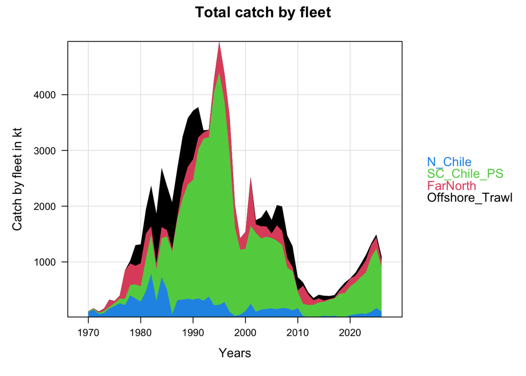

Figure 4: Catch of jack mackerel by fleet. Blue is the northern Chilean fleet, green is the south-central Chilean fleet, red is the far north fleet, and black is the offshore trawl fleet.

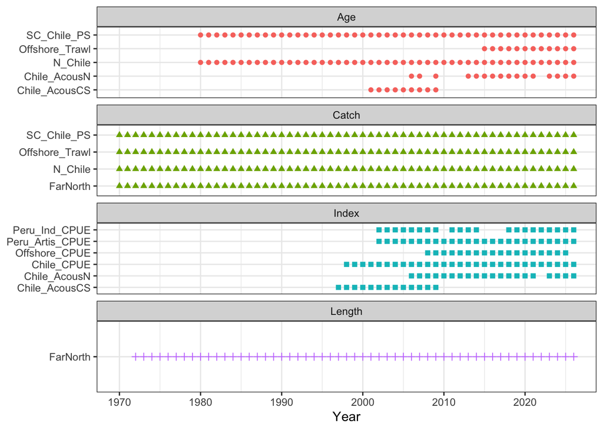

Figure 5: Observation years by data source and type, read from the current 1.06 input file. Catch spans all model years, with the 2026 full-year values supplied as projections.

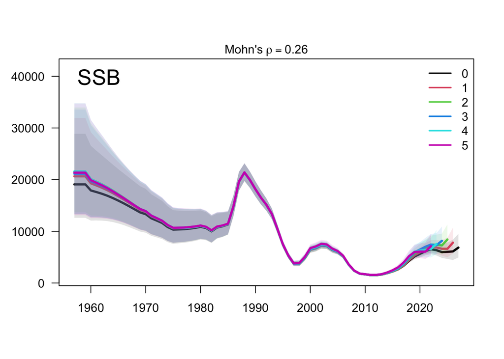

Figure 6: Spawning biomass (thousand tonnes) from the full assessment and five retrospective peels, based on Model h1_1.06 (single-stock hypothesis). Legend 0 is the full assessment; 1–5 are successive terminal-year peels. Shading shows saved model uncertainty bounds. Title rho uses each peel’s one-year-ahead SSB endpoint.

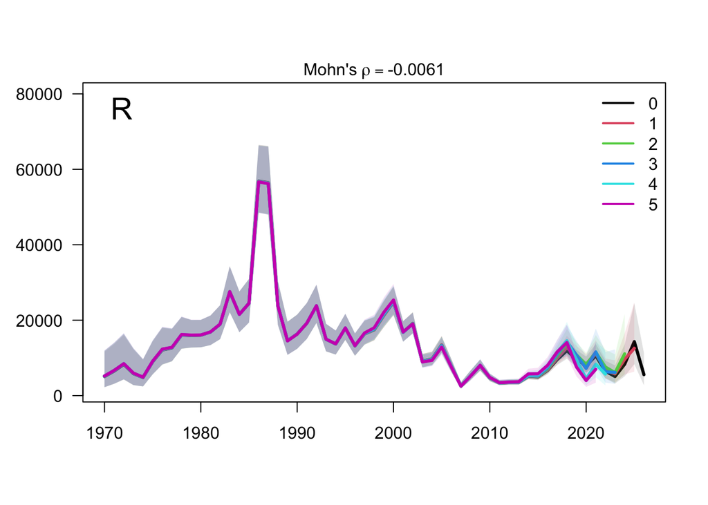

Figure 7: Recruitment (millions of fish) from the full assessment and five retrospective peels, based on Model h1_1.06 (single-stock hypothesis). Legend 0 is the full assessment; 1–5 are successive terminal-year peels. Shading shows saved model uncertainty bounds.

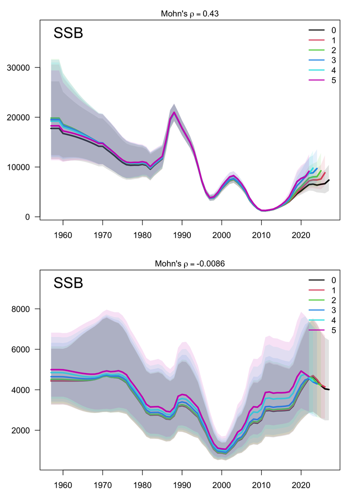

Figure 8: Spawning biomass (thousand tonnes) from the full assessment and five retrospective peels for the southern stock (top) and far north stock (bottom), based on Model h2_1.06 (two-stock hypothesis). Legend 0 is the full assessment; 1–5 are successive terminal-year peels. Shading shows saved model uncertainty bounds. Title rho uses each peel’s one-year-ahead SSB endpoint.

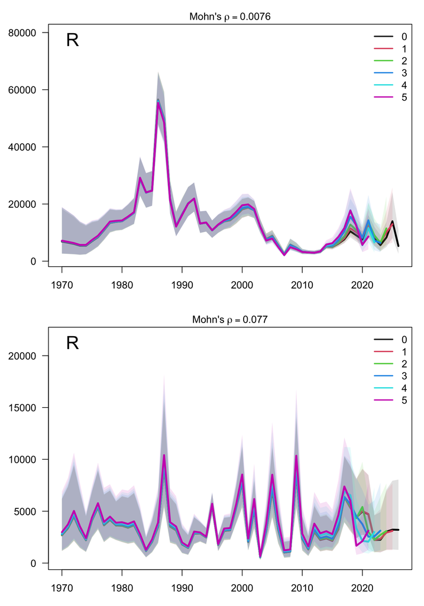

Figure 9: Recruitment (millions of fish) from the full assessment and five retrospective peels for the southern stock (top) and far north stock (bottom), based on Model h2_1.06 (two-stock hypothesis). Legend 0 is the full assessment; 1–5 are successive terminal-year peels. Shading shows saved model uncertainty bounds.

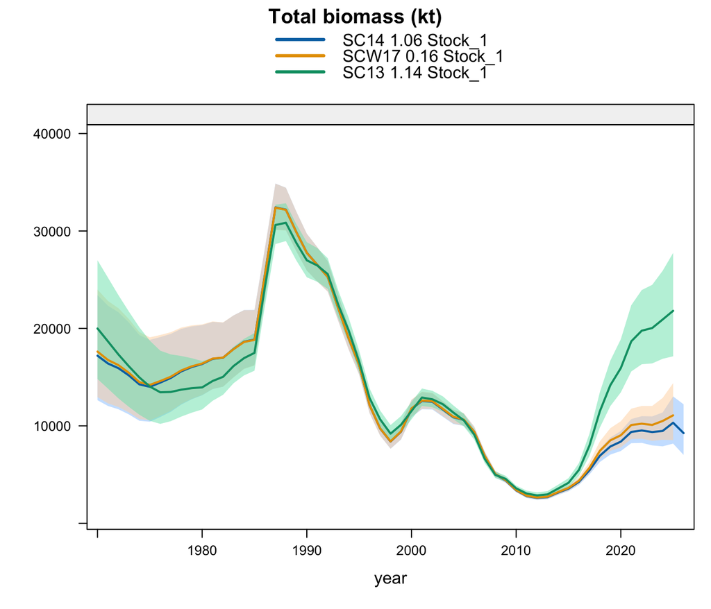

Figure 10: Total biomass (thousand tonnes) comparison for the archived SC13 1.14, SCW17 0.16 and current SC14 1.06 single-stock configurations. Differences include successive input updates and changes in model assumptions.

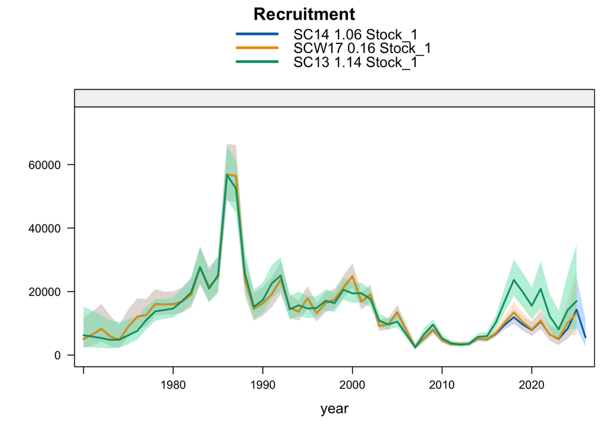

Figure 11: Recruitment (millions of fish) comparison for the archived SC13 1.14, SCW17 0.16 and current SC14 1.06 single-stock configurations.

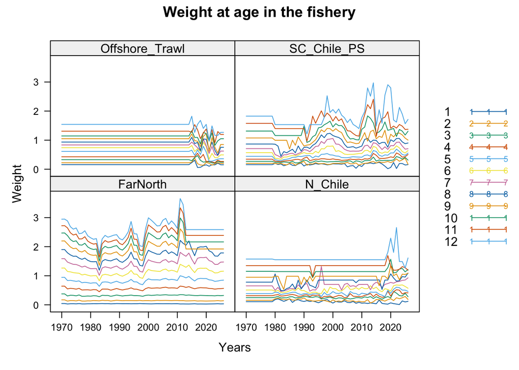

Figure 12: Mean weights-at-age (kg) over time used for the fisheries in the JJM models. Each line represents an age from 1 to 12.

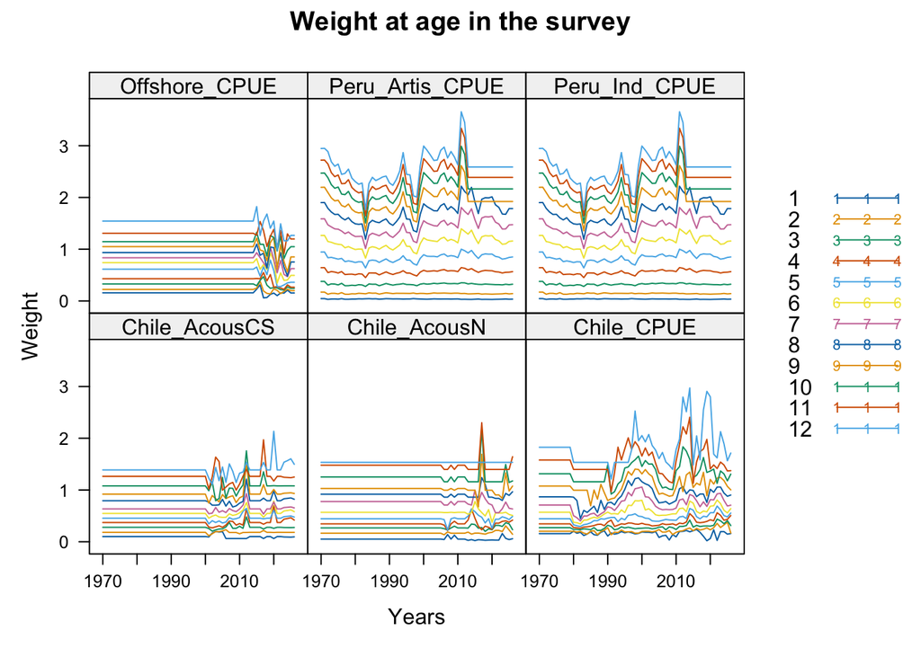

Figure 13: Mean weights-at-age (kg) over time used for the surveys in the JJM models. Each line represents an age from 1 to 12.

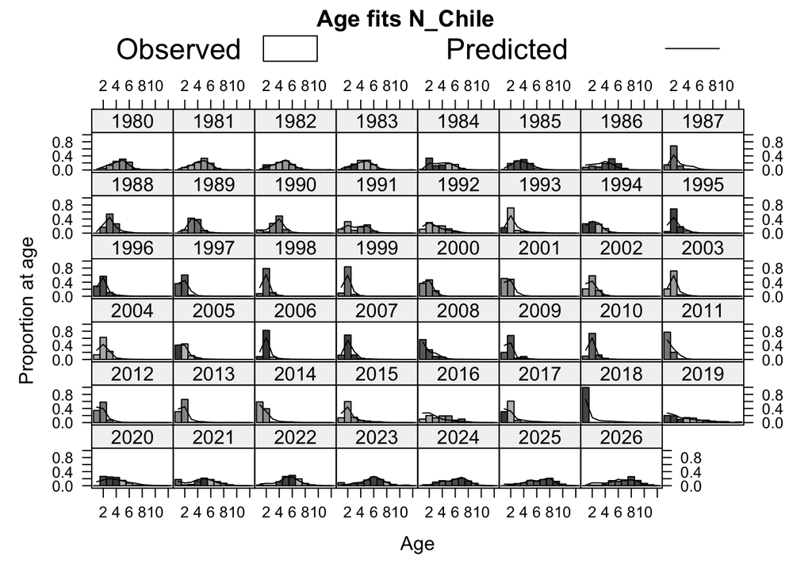

Figure 14: Model h1_1.06 (single-stock hypothesis) fit to the age compositions for the Chilean northern zone fishery (Fleet 1). Bars represent the observed data and lines represent the model predictions.

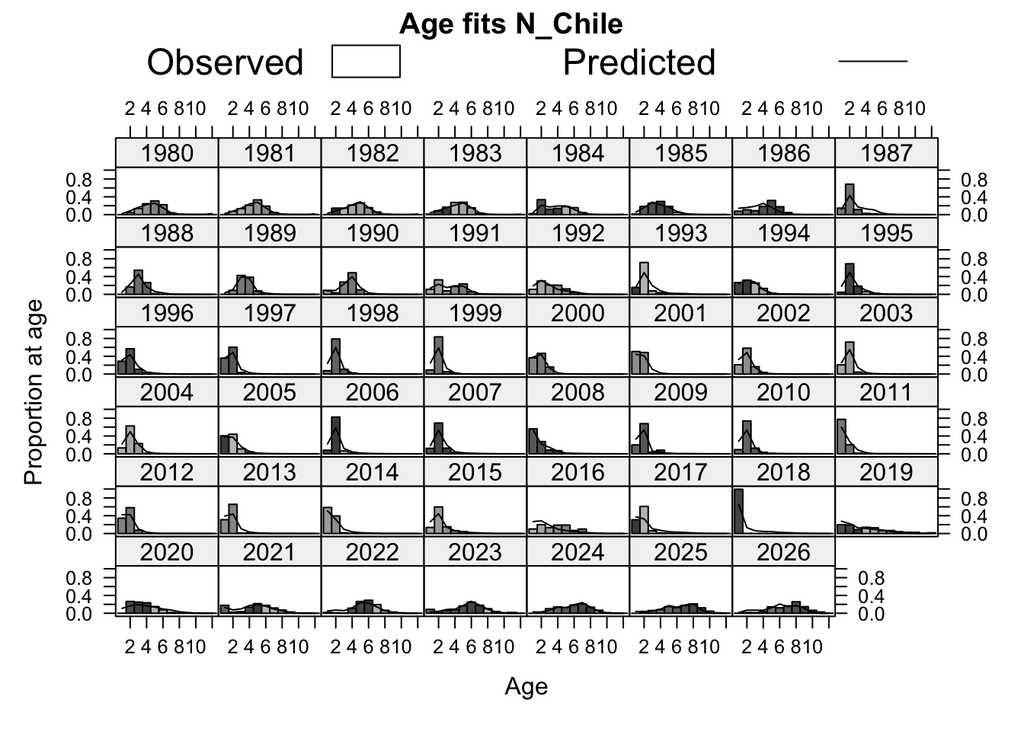

Figure 15: Model h2_1.06 (two-stock hypothesis) fit to the age compositions for the Chilean northern zone fishery (Fleet 1). Bars represent the observed data and lines represent the model predictions.

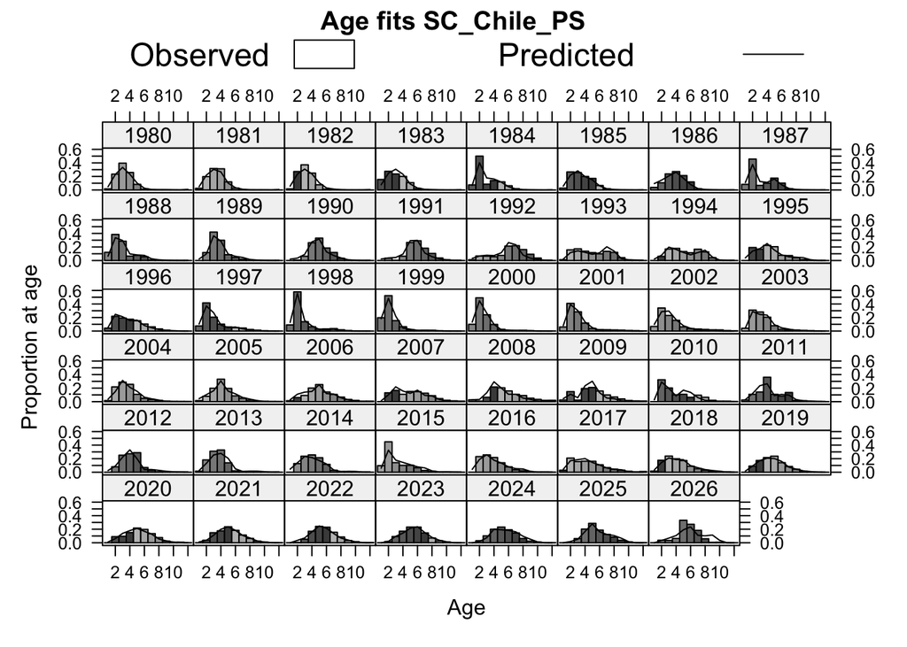

Figure 16: Model h1_1.06 (single-stock hypothesis) fit to the age compositions for the South-Central Chilean purse seine fishery (Fleet 2). Bars represent the observed data and lines represent the model predictions.

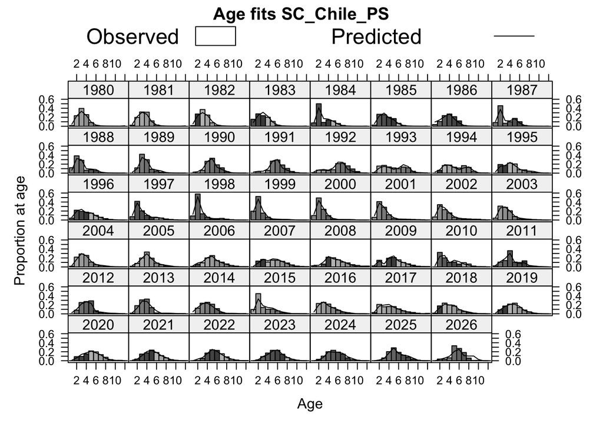

Figure 17: Model h2_1.06 (two-stock hypothesis) fit to the age compositions for the South-Central Chilean purse seine fishery (Fleet 2). Bars represent the observed data and lines represent the model predictions.

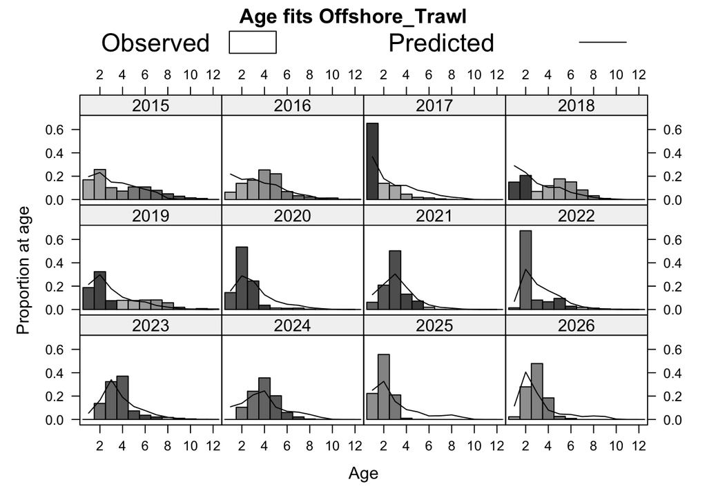

Figure 18: Model h1_1.06 (single-stock hypothesis) fit to the age compositions for the offshore trawl fishery (Fleet 4). Bars represent the observed data and lines represent the model predictions.

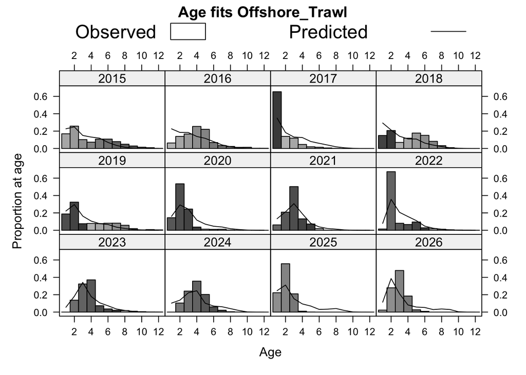

Figure 19: Model h2_1.06 (two-stock hypothesis) fit to the age compositions for the offshore trawl fishery (Fleet 4). Bars represent the observed data and lines represent the model predictions.

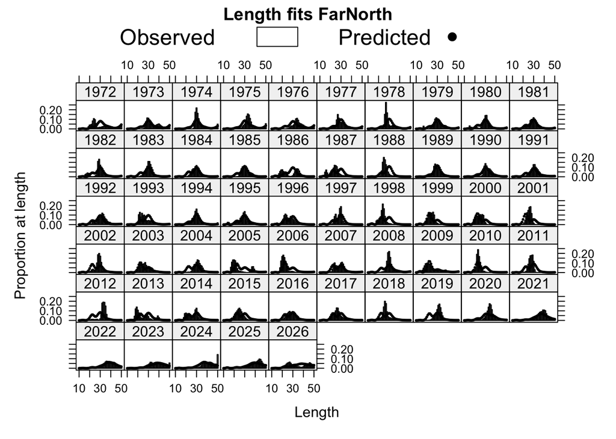

Figure 20: Model h1_1.06 (single-stock hypothesis) fit to the length compositions for the far north fishery (Fleet 3). Bars represent the observed data and points represent the model predictions.

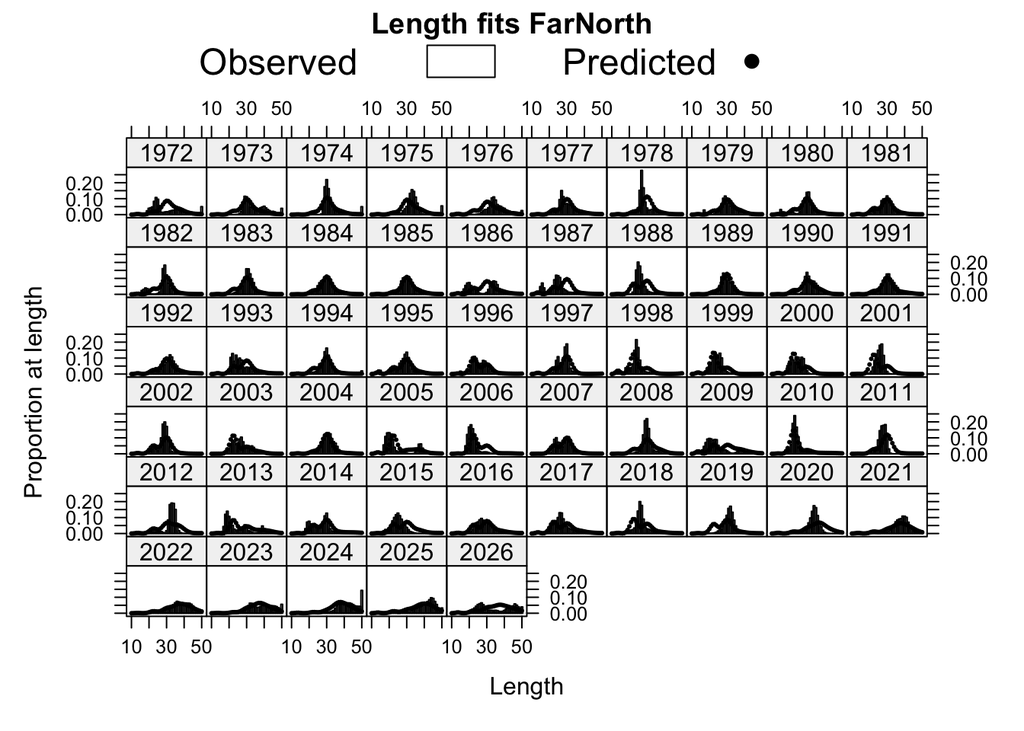

Figure 21: Model h2_1.06 (two-stock hypothesis) fit to the length compositions for the far north fishery (Fleet 3). Bars represent the observed data and points represent the model predictions.

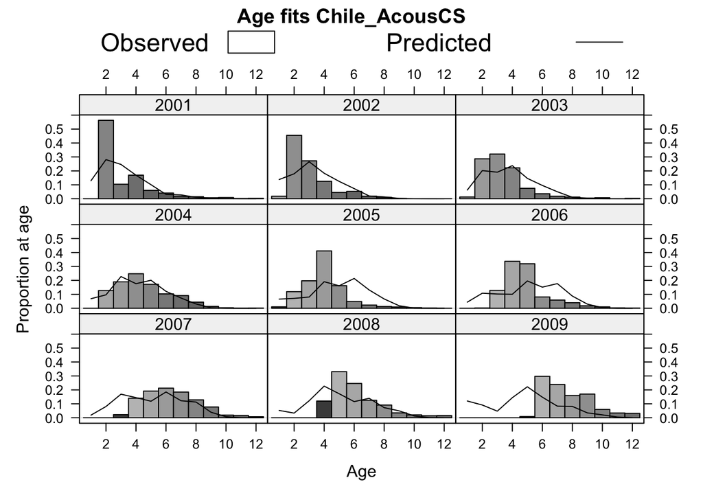

Figure 22: Model h1_1.06 (single-stock hypothesis) fit to the age compositions for the South-Central Acoustic survey. Bars represent the observed data and lines represent the model predictions.

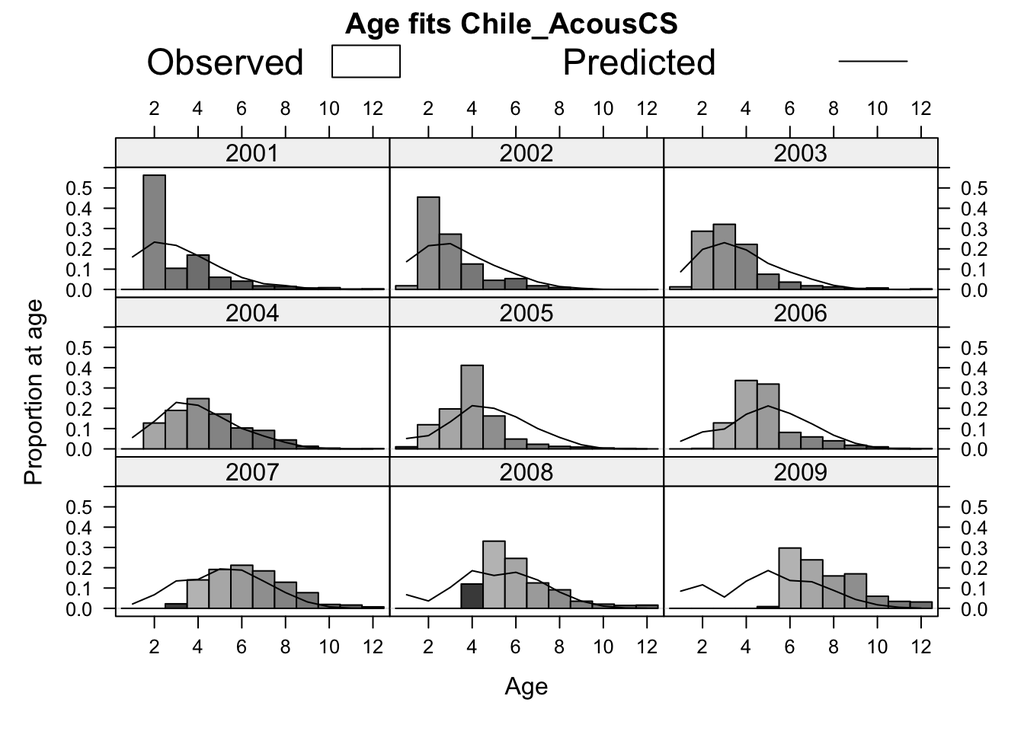

Figure 23: Model h2_1.06 (two-stock hypothesis) fit to the age compositions for the South-Central Acoustic survey. Bars represent the observed data and lines represent the model predictions.

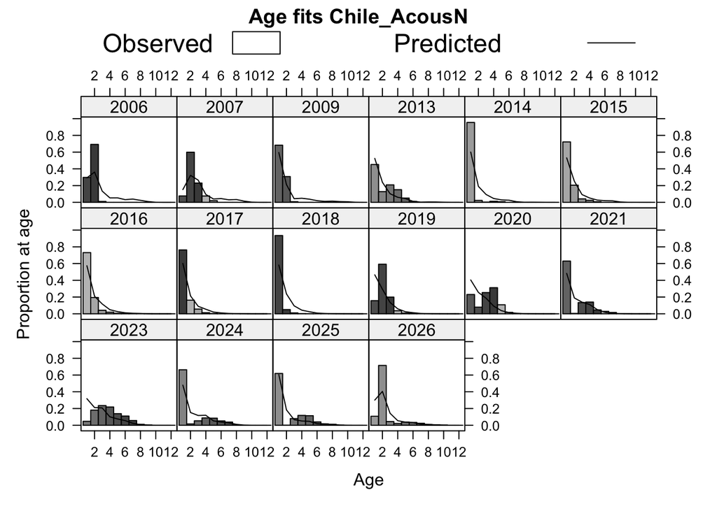

Figure 24: Model h1_1.06 (single-stock hypothesis) fit to the age compositions for the North Chilean acoustic survey. Bars represent the observed data and lines represent the model predictions.

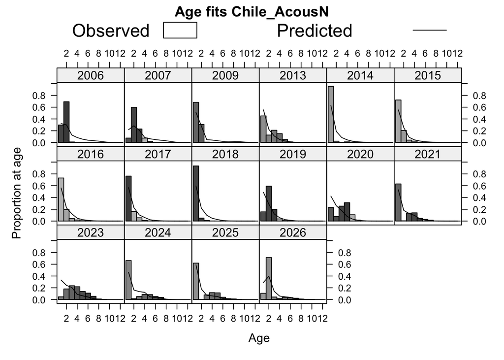

Figure 25: Model h2_1.06 (two-stock hypothesis) fit to the age compositions for the North Chilean acoustic survey. Bars represent the observed data and lines represent the model predictions.

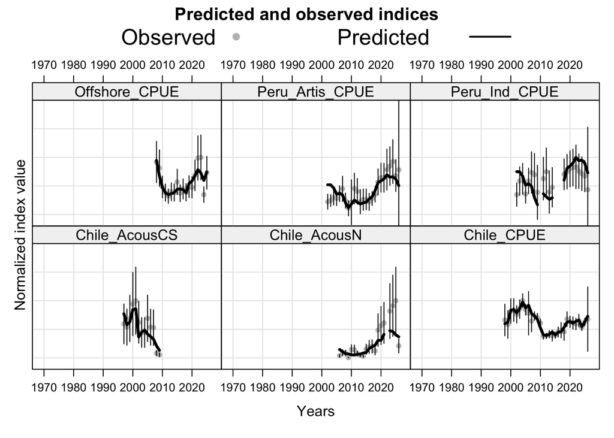

Figure 26: Model h1_1.06 (single-stock hypothesis) fit to different indices. Vertical bars represent 2 standard deviations around the observations.

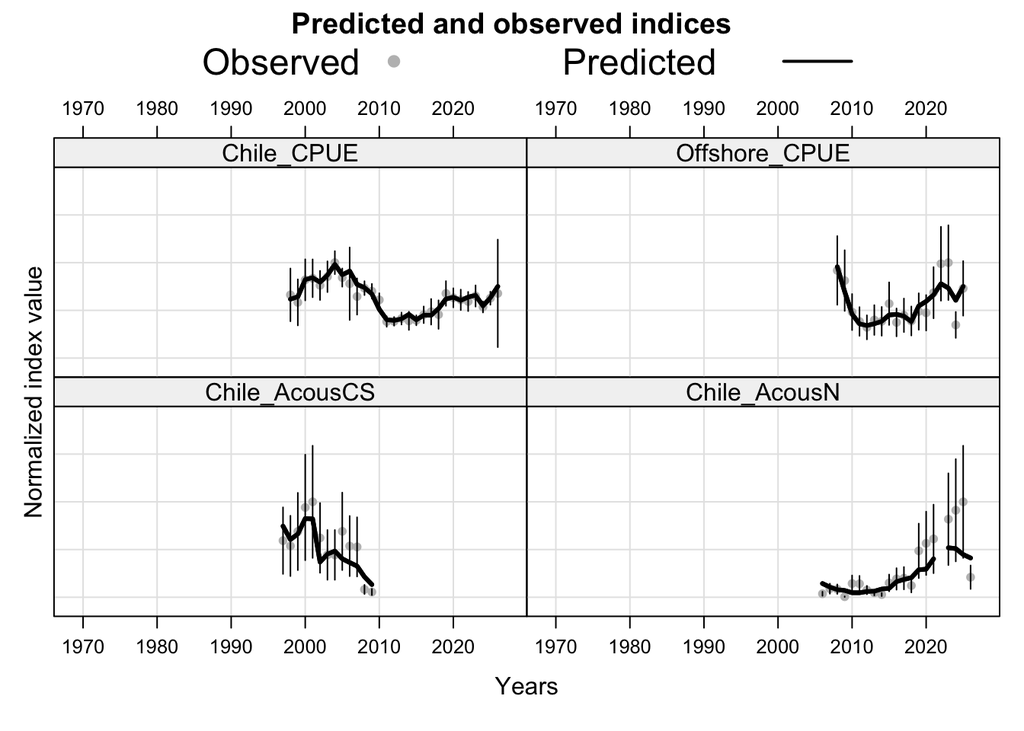

Figure 27: Model h2_1.06 (two-stock hypothesis) fit to indices for the south stock. Vertical bars represent 2 standard deviations around the observations.

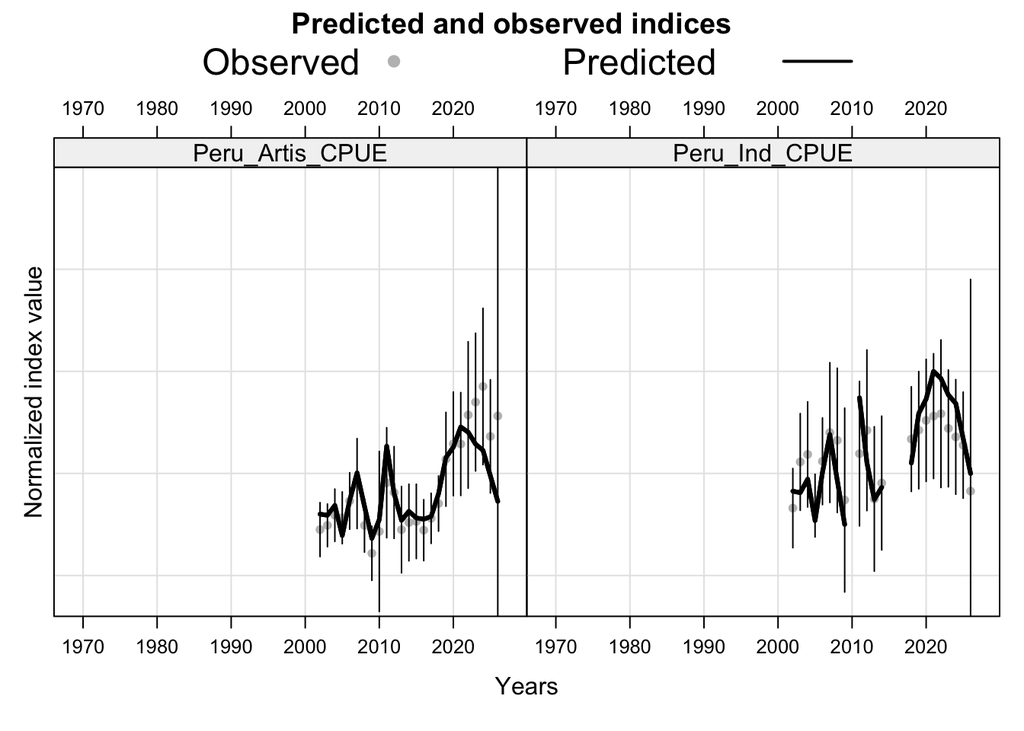

Figure 28: Model h2_1.06 (two-stock hypothesis) fit to indices for the north stock. Vertical bars represent 2 standard deviations around the observations.

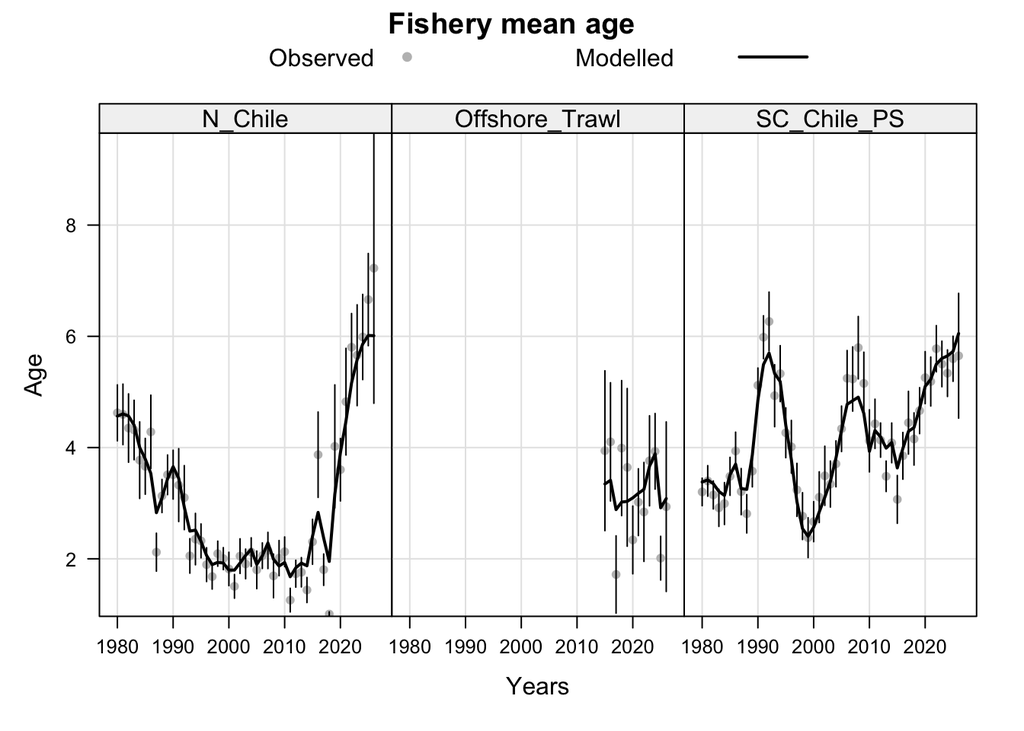

Figure 29: Mean age by year and fishery. Line represents the Model h1_1.06 (single-stock hypothesis) predictions and dots observed values with implied input error bars.

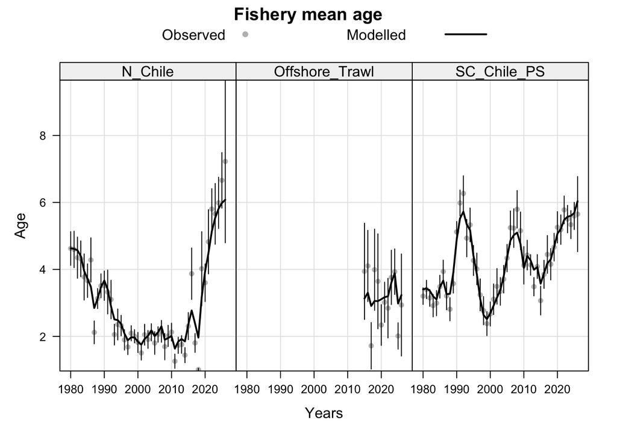

Figure 30: Mean age by year and fishery. Line represents the Model h2_1.06 (two-stock hypothesis) predictions and dots observed values with implied input error bars.

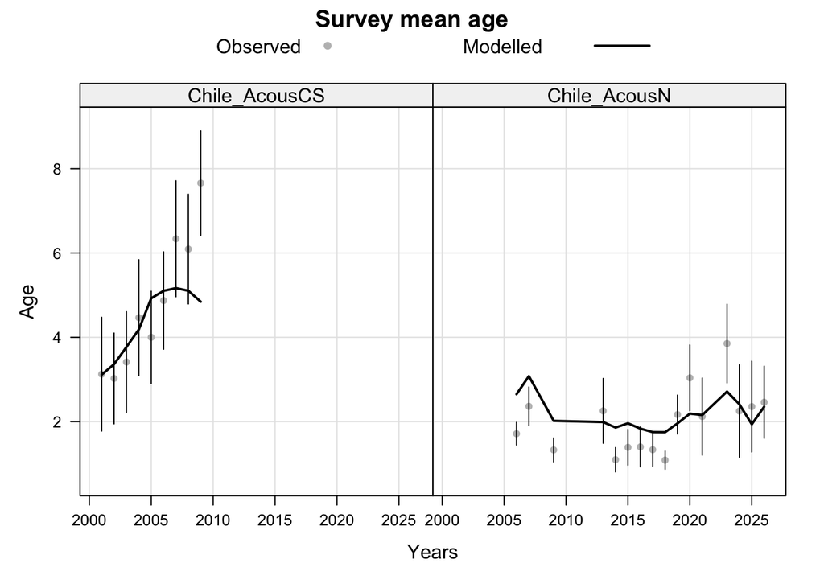

Figure 31: Mean age by year and survey. Line represents the Model h1_1.06 (single-stock hypothesis) predictions and dots observed values with implied input error bars.

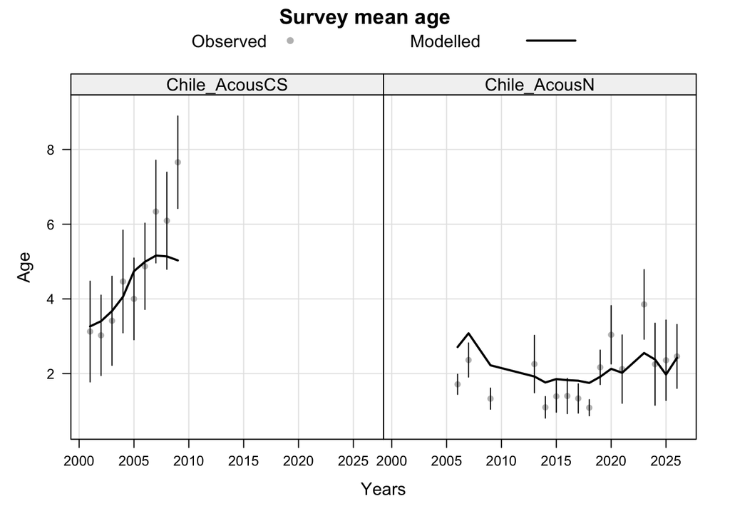

Figure 32: Mean age by year and survey. Line represents the Model h2_1.06 (two-stock hypothesis) predictions and dots observed values with implied input error bars.